# CHL Calcs & Cleanup: 2010-2018 [V]

T.Hooker

29 August, 2019

```r
#options(table_counter=FALSE)
tidy_package <- c("plyr", "dplyr", "tidyr", "magrittr", "htmlTable", "tidyverse")
#
if(!"tidyr" %in% (.packages())) {invisible(lapply(tidy_package, function(x) suppressMessages(library(x, character.only=T, quietly = T, warn.conflicts = F))))}
##
graph_package <- c("ggplot2", "scales")
if(!"ggplot2" %in% (.packages())) {invisible(lapply(graph_package, library, character.only=T, quietly = T, warn.conflicts = F))}
##
options(scipen = 999, digits = 4, stringsAsFactors = FALSE, keep.source = TRUE,
        width=87)
##
#startwork.date <- format(Sys.Date(), "%y%m%d")
knitr::opts_chunk$set(cache=TRUE)
```

## Notes

Prior work compared and compiled data from two (2) active files containing CHL data:

1. A file for the 2010-2016 CHL data and cleanup procedures, and
   - File :: “CHdat5_XX_4.0_190215_t1.xlsx”
2. A file for 2017-2018 CHL data based on the more recent UPHL-LIMS system and incorporating a new HPLC method for CHL analysis
   - File :: “CHL201718_CHL08_03_noDup_dat_190226_t1.xlsx”

Goals were to align dataset-fields, compare calculations, ensure completeness of project datasets, and prepare data for import to AWQMS. It is anticipated that much of this latter work will be performed on a project-specific basis.

[190310] :: New Notebook / Version to coninue Utah-Lake specific CHL cleanup, matchup and import to AWQMS.

- Continuing Work Elements

**Working Datasets**

1. UTLK CHL 2010 - 2016
   - Dataframe `utlk_CHL_201016_import01`
     - Note that some updates to XLS-datafile were made to complete import process
   - UTLK-specific Activity.IDs for Lake / Non-Lake records were compiled and cleaned
     - `awqms_ACTID_UTLK_raw_02`
   - Source dataframe for CHL results [2010-2016] :: `UL1016_09`
     - Only 370 records from dataframe were transferred to import file. Remaining records did not have a match to UTLK-specific ACT.IDs
   - XLS file for import to AWQMS :: `UTLK_CHL_201016_import01_190308_t1.xlsx`
2. UTLK CHL 2017 - 2018
   - `UL18718_05`

**Prior Work**

- Build from $3.4/ 3.41, but apply cleanup to more recent CHL data (2017-18)
- Completed CHL 2010-2016 UTAH LAKE import (sect. 3.5.2) from nb: `CHL_Compile_ALL_01_190306_v02.Rmd`
- Completed CHL 2017/2018 UTAH LAKE import (sect. 6.3) from nb: `CHL_Compile_ALL_02_190310_v01.Rmd`

[190417]

- Prior to splitting UTLK datasets, working dataframes were:
  - `CHL1016_01`
  - `CHL1718_01`
- These were saved as .rds files and need to be re-imported for this notebook
  - see `DF_recovery_190417.r`

[190715]

- Getting back to look at CHL data for the remaining records…
- Will extract WSpur data for Suzan T.
- **Information on WSpur project can be found in notebook “CHL_Status_ALL_03_190417_v01.Rmd”**

[190813]

- Re-starting CHL-status review
- ID cleanup needs
- fix and import datasets…

[190815]

- Moving forward w/ “*final*” calculations of CHL concentrations for both datasets
- Then, clean up records characterizing COMPLETENESS and Non-Detects
- Then, prepare files for AWQMS IMPORT…
- Current Datafiles::
  - `CHL1016_02`
  - `CHL1718_02`
  - `CHL_param.Date` :: summary table of percent of records w/ Non-Detect flags for CHLA/CHLA.total for both datasets combined.

[190829]

- Have prioritized projects for review of Non-Detect records and possible re-calc of CHL observations from raw absorbance values retrieved from UPHL benchsheets
- Key dates for Non-Detect review are 2013 to 2014 (possibly after, and starting in November, 2012); these benchsheets are on-order from UPHL

## Project Notes

Goal: Review *completeness*-related status of CHL results from both datasets / data-periods and summarize for management review

**Workspace cleanup** + tidy things up ! + Backup workspace :: `190829.1.RData` + Cleaned up :: `190829-2.RData`

**Working dataframes [current]**

**2017/2018 Data** + `CHL1718_04`

**2010-2016 Data** + `CHL1016_04`

## Current Work

**Remaining Tasks**

1. Cleanup `PROJ_grp` == “unknown”
2. Clarify and cleanup BENTHIC samples
3. Locate last set of volumes…
4. For Non-Detect issues, pay special attention to U-flags from November, 2012 onward. (*Not sure when this practice was corrected, but sometime around the change ot the new LIMS (2017?)*)
5. Re-examine and cleanup duplicated records…

[180929] ::

Have project prioritization table, see `"chl_project_Priority_table_190829.docx"`, summarizing details about projects (as guidelines)

Also - pay special attention to non-detect records in 2013 and 2014 (starting Nov 2012), where many of these do not seem to be reliable

[190911] ::

- Versioned Notebook, continuing project-specific review of records for data that is intended to be imported to AWQMS

## 8.0 2010-16 Priority Project Data-review

- Version df:

```r
CHL1016_04 -> CHL1016_05
```

- Priority Projects are those that will be imported to AWQMS
  - BOR, BRI, CUWJ, JRULI, LAKES, NPS, SBCI, TMDLLAKES, UBI, UCASE, USFS, UtahLK, WINTERLAKES, WLA, WRI

### 8.1 Identify records from priority projects

```r
CHL1016_05 %<>% mutate(
  import_status = case_when(
    is.na(import_status) & PROJ_grp %in% proj_import ~ "To_import",
    !is.na(import_status) ~ import_status,
    TRUE ~ as.character(NA)))


CHL1016_05 %>% {addmargins(table(.$PROJ_grp, .$import_status,
                                 useNA="ifany", deparse.level = 2))}
```

```
             .$import_status
.$PROJ_grp    To_import utlk_01  <NA>   Sum
  BOR               279       0     0   279
  BRI              2195       0     0  2195
  CUWJ              368       0     0   368
  FarmB               0       0     9     9
  FRNG                0       0   306   306
  GSLWET              0       0   333   333
  HAB                 0       0   117   117
  IW                  0       0   123   123
  JRULI             976      32     0  1008
  LAKES            1357     156     0  1513
  NPS                 3       0     0     3
  REFWET              0       0    99    99
  SBCI              186       0     0   186
  TMDLLAKES         636     138     0   774
  UBI                 4       0     0     4
  UCASE            2094       0     0  2094
  unknown             0       0   106   106
  USFS               47       0     0    47
  UtahLK             24      18     0    42
  WINTERLAKES        28       0     0    28
  WLA               301      25     0   326
  WRI               720       0     0   720
  WSpur               0       0  2195  2195
  WWTP                0       3  1064  1067
  Sum              9218     372  4352 13942
```

- For records where import_status [NA]…

```r
CHL1016_05 %>%
  filter(!is.na(import_status)) %>%
  {addmargins(table(.$PROJ_grp, .$PARAM_status,
                                 useNA="ifany", deparse.level = 2))}
```

```
             .$PARAM_status
.$PROJ_grp    review_PERI <NA>  Sum
  BOR                   0  279  279
  BRI                   0 2195 2195
  CUWJ                  0  368  368
  JRULI                 0 1008 1008
  LAKES                 0 1513 1513
  NPS                   0    3    3
  SBCI                  0  186  186
  TMDLLAKES             0  774  774
  UBI                   2    2    4
  UCASE               391 1703 2094
  USFS                  0   47   47
  UtahLK                0   42   42
  WINTERLAKES           0   28   28
  WLA                   0  326  326
  WRI                   0  720  720
  WWTP                  0    3    3
  Sum                 393 9197 9590
```

```r
CHL1016_05 %>%
  filter(!is.na(import_status)) %>%
  {addmargins(table(.$PROJ_grp, .$RECORD_STATUS,
                                 useNA="ifany", deparse.level = 2))} %>%
  htmlTable::htmlTable(., css.cell = rbind(rep("padding-left: 0.5em; padding-right: 0.5em;font-size: 0.75em;", times=ncol(.)+1), matrix("padding-left: 0.5em; padding-right: 0.5em; font-size: 0.75em;", ncol=ncol(.)+1, nrow=nrow(.))))
```

|  | .$RECORD_STATUS REVIEW_lrl | .$RECORD_STATUS REVIEW_lrl;REVIEW_VOL | .$RECORD_STATUS REVIEW_mdl | .$RECORD_STATUS REVIEW_mdl;REVIEW_VOL | .$RECORD_STATUS REVIEW_VOL | .$RECORD_STATUS |  | Sum |
| --- | --- | --- | --- | --- | --- | --- | --- | --- |
| .$PROJ_grp |  |  |  |  |  |  |  |  |
| BOR | 0 | 0 | 0 | 0 | 6 | 273 |  | 279 |
| BRI | 0 | 0 | 0 | 0 | 163 | 2032 |  | 2195 |
| CUWJ | 0 | 0 | 0 | 0 | 280 | 88 |  | 368 |
| JRULI | 0 | 0 | 0 | 0 | 321 | 687 |  | 1008 |
| LAKES | 24 | 0 | 147 | 0 | 102 | 1240 |  | 1513 |
| NPS | 0 | 0 | 0 | 0 | 3 | 0 |  | 3 |
| SBCI | 0 | 0 | 0 | 0 | 3 | 183 |  | 186 |
| TMDLLAKES | 0 | 0 | 0 | 0 | 160 | 614 |  | 774 |
| UBI | 0 | 0 | 0 | 0 | 4 | 0 |  | 4 |
| UCASE | 0 | 0 | 78 | 5 | 427 | 1584 |  | 2094 |
| USFS | 0 | 0 | 0 | 0 | 47 | 0 |  | 47 |
| UtahLK | 0 | 0 | 0 | 0 | 10 | 32 |  | 42 |
| WINTERLAKES | 0 | 0 | 0 | 0 | 9 | 19 |  | 28 |
| WLA | 0 | 0 | 0 | 0 | 35 | 291 |  | 326 |
| WRI | 0 | 19 | 0 | 169 | 532 | 0 |  | 720 |
| WWTP | 0 | 0 | 0 | 0 | 0 | 3 |  | 3 |
| Sum | 24 | 19 | 225 | 174 | 2102 | 7046 |  | 9590 |

- `PARAM_status` mainly identifies PERI samples
- `RECORD_STATUS` provides additional review-details for VOLs and RLs…

*DF cleanup*

- Remove values for x_RVal.conc where Non_Detect == “U”

```r
CHL1016_05 %<>% select(RECORD_STATUS:import_status, SKey2,
                       QC_type:x_SDate,
                       MethodID2:PARAM.X,
                       Prob.Iden:RL_Units, everything())
# CHL1016_05 -> CHL1016_05.copy
# CHL1016_05 <- CHL1016_05.copy
#
CHL1016_05 %<>% mutate(
  x_RVal.conc = case_when(
    !is.na(Non_Detect) & Non_Detect == "U" &
      !is.na(x_RVal.conc) ~ as.numeric(NA),
    !is.na(x_RVal.conc) ~ x_RVal.conc)) %>%
  mutate(
    x_Units.conc = case_when(
      is.na(x_RVal.conc) ~ as.character(NA),
      !is.na(x_RVal.conc) ~ x_Units.conc,
      TRUE ~ as.character(NA)
    ))
```

### 8.2 Project-specific Result and Detection review

## [1] BOR

- Number of unique sites in set :: 13
- Record data-range :: 2010-06-01 to 2016-07-06
- Unique Sample Events :: 119
- Methods :: 10200

### Filt.Vol completeness

- Records where `Filt.Vol` is **missing** ::

```r
CHL1016_05 %>%
  filter(!is.na(import_status)) %>%
  filter(PROJ_grp == "BOR") %>%
  {addmargins(table(.$RECORD_STATUS, .$import_status,
                                 useNA="ifany", deparse.level = 2))}
```

```
               .$import_status
.$RECORD_STATUS To_import Sum
     REVIEW_VOL         6   6
     <NA>             273 273
     Sum              279 279
```

- Levels of SKey2 w/ `REVIEW_VOL` ::

```r
CHL1016_05 %>% filter(!is.na(import_status)) %>% filter(PROJ_grp == "BOR") %>% filter(!is.na(RECORD_STATUS)) %>% distinct(SKey2, lubridate::year(.$x_SDate)) %>% setNames(c("SKey2", "Year")) %>% arrange(Year) %>% htmlTable::htmlTable(., css.cell = rbind(rep("padding-left: 0.8em; padding-right: 0.8em;font-size: 0.75em;", times=ncol(.)+1), matrix("padding-left: 0.8em; padding-right: 0.8em; font-size: 0.75em;", ncol=ncol(.)+1, nrow=nrow(.))), align="rlc")
```

|  | SKey2 | Year |
| --- | --- | --- |
| 1 | 4938660.40395.201003993 | 2010 |
| 2 | 4938675.40330.201002383 | 2010 |
| 3 | 4938695.40330.201002378 | 2010 |
| 4 | 4938620.42557.2005353 | 2016 |

- Records from 2010 do not need volumes (REMOVE status)

```r
CHL1016_05 %<>% mutate(
  RECORD_STATUS = case_when(
    PROJ_grp == "BOR" & !is.na(RECORD_STATUS) &
      lubridate::year(.$x_SDate) < 2013 ~ as.character(NA),
    !is.na(RECORD_STATUS) ~ RECORD_STATUS,
    TRUE ~ as.character(NA)  ))
```

- Only [1] sample missing VOL
- *Asked RP to look into this…*
  - data cannot be located - missing
  - change `RECORD_STATUS` to *Reject*

```r
CHL1016_05 %<>% mutate(
  RECORD_STATUS = case_when(
    SKey2 == "4938620.42557.2005353" &
      is.na(Filt.Vol) &
      RECORD_STATUS == "REVIEW_VOL" ~ "REJECT_noVOL",
    !is.na(RECORD_STATUS) ~ RECORD_STATUS,
    TRUE ~ as.character(NA)))
```

### Project Non-Detects

- Records w/ Non-Detect flags…Two key CHL-parameters
  - plot unique instances of Non-Detects vs. Results (by SKey2) for all key CHL-parameters

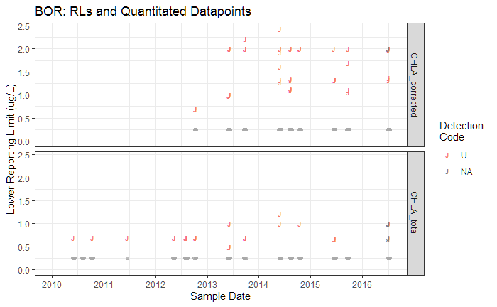

```r
CHL1016_05 %>% filter(PROJ_grp == "BOR") %>%
  filter(!is.na(Filt.Vol)) %>%
  filter(PARAM.X != "PHEO") %>%
  mutate(PARAM.X = recode(.$PARAM.X,
                          "CHLA.X" = "CHLA_total",
                          "CHLA.tot" = "CHLA_total",
                          "CHLA.aa" = "CHLA_corrected")) %>%
  distinct(SKey2, PARAM.X, Non_Detect, .keep_all = T) %>%
  ggplot(., na.rm=T) + theme_bw() +
  facet_grid(PARAM.X ~ .,  scales = "fixed") +
  geom_text(aes(x=x_SDate, y=LRL_c, col=Non_Detect),
            na.rm=T, size=2.5, fontface="bold", label="J") +
  geom_point(data=.data[[is.na(.data[["Non_Detect"]]),]], aes(y=0.25, x=.data[["x_SDate"]]),
             position = position_jitter(width=10, height=0), col="darkgray", size=1.5,
             alpha=0.75, na.rm=T) +
  scale_x_date(date_labels="%Y",date_breaks = "1 year",
               limits=c(as.Date("2010-01-01"), NA)) +
  scale_y_continuous(limits=c(0, NA)) +
  labs(x="Sample Date", y="Lower Reporting Limit (ug/L)", col="Detection \nCode",
       title="BOR: RLs and Quantitated Datapoints")
```

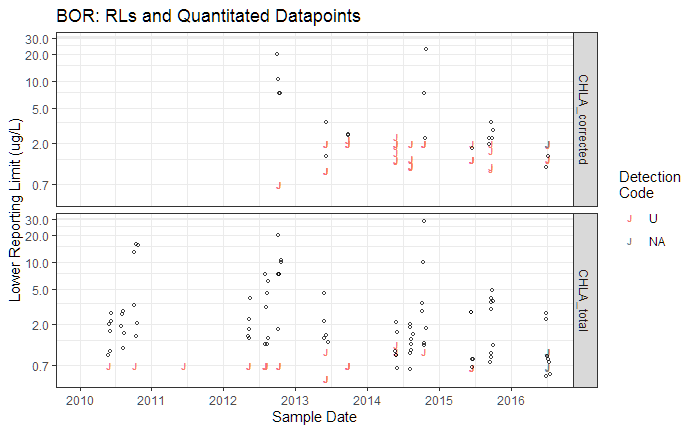

```r
CHL1016_05 %>% filter(PROJ_grp == "BOR") %>%
  filter(!is.na(Filt.Vol)) %>%
  filter(PARAM.X != "PHEO") %>%
  mutate(PARAM.X = recode(.$PARAM.X,
                          "CHLA.X" = "CHLA_total",
                          "CHLA.tot" = "CHLA_total",
                          "CHLA.aa" = "CHLA_corrected")) %>%
  distinct(SKey2, PARAM.X, .keep_all = T) %>%
  ggplot(., na.rm=T) + theme_bw() +
  facet_grid(PARAM.X ~ .,  scales = "fixed") +
  geom_text(aes(x=x_SDate, y=LRL_c, col=Non_Detect),
            na.rm=T, size=2.5, fontface="bold", label="J") +
  geom_point(aes(y=x_RVal.conc, x=x_SDate),
             position = position_jitter(width=10, height=0), size=1.2,
             alpha=0.75, na.rm=T, shape=1) +
  scale_x_date(date_labels="%Y",date_breaks = "1 year",
               limits=c(as.Date("2010-01-01"), NA)) +
  scale_y_continuous(limits=c(NA, NA), breaks=c(0.7, 2, 5, 10,20,30), oob=scales::squish) +
  coord_trans(y="log10", limy=c(0.4, 35)) +
  labs(x="Sample Date", y="Lower Reporting Limit (ug/L)", col="Detection \nCode",
       title="BOR: RLs and Quantitated Datapoints")
```

```r
# CHL1016_05 %>% filter(PROJ_grp == "BOR") %>%
#   filter(!is.na(Filt.Vol)) %>%
#   filter(PARAM.X != "PHEO") %>% distinct() %>% nrow()
```

- BOR Summary of proportion of Non-Detects in Results
  - *Ignoring records where filtration volume could not be obtained*

```r
CHL1016_05 %>% filter(PROJ_grp == "BOR") %>%
  filter(!is.na(Filt.Vol)) %>%
  filter(PARAM.X != "PHEO") %>%
  mutate(PARAM.X = recode(.$PARAM.X,
                          "CHLA.X" = "CHLA_total",
                          "CHLA.tot" = "CHLA_total",
                          "CHLA.aa" = "CHLA_corrected")) %>%
  group_by(lubridate::year(x_SDate), PARAM.X) %>%
  summarize(p_ND = sprintf("%.f%%",
                           (sum(!is.na(Non_Detect), na.rm=T) / n())*100)) %>%
  as.data.frame(.) %>%
  setNames(c("Year", "CHL_param", "p_NonDetects")) %>%
  bind_rows(.,
            CHL1016_05 %>% filter(PROJ_grp == "BOR") %>%
              filter(!is.na(Filt.Vol)) %>%
              filter(PARAM.X != "PHEO") %>%
              group_by(lubridate::year(x_SDate)) %>%
              summarize(obs = n()) %>% data.frame(., CHL_param="Obs") %>%
              setNames(c("Year", "p_NonDetects", "CHL_param")) %>%
              mutate(p_NonDetects=as.character(p_NonDetects))
            ) %>%
  spread(Year, p_NonDetects) %>%
  htmlTable::htmlTable(., css.cell = rbind(rep("padding-left: 0.8em; padding-right: 0.8em;font-size: 0.75em;", times=ncol(.)+1), matrix("padding-left: 0.8em; padding-right: 0.8em; font-size: 0.75em;", ncol=ncol(.)+1, nrow=nrow(.))), align="r|l|ccccccc|", caption="BOR: Proportion of records (SK2) where result is Non-Detect", total=T)
```

| BOR: Proportion of records (SK2) where result is Non-Detect | BOR: Proportion of records (SK2) where result is Non-Detect CHL_param | BOR: Proportion of records (SK2) where result is Non-Detect 2010 | BOR: Proportion of records (SK2) where result is Non-Detect 2011 | BOR: Proportion of records (SK2) where result is Non-Detect 2012 | BOR: Proportion of records (SK2) where result is Non-Detect 2013 | BOR: Proportion of records (SK2) where result is Non-Detect 2014 | BOR: Proportion of records (SK2) where result is Non-Detect 2015 | BOR: Proportion of records (SK2) where result is Non-Detect 2016 |
| --- | --- | --- | --- | --- | --- | --- | --- | --- |
| 1 | CHLA_corrected |  |  | 33% | 76% | 88% | 67% | 75% |
| 2 | CHLA_total | 11% | 100% | 35% | 71% | 12% | 22% | 0% |
| 3 | Obs | 19 | 1 | 52 | 34 | 48 | 36 | 16 |

- Given the sample volumes used by the BOR field team, the % of records where CHL was not-detected should be minimized compared to other projects

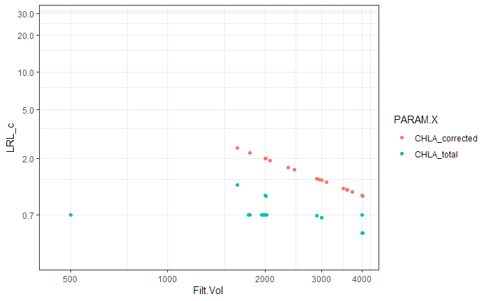

```r
CHL1016_05 %>% filter(PROJ_grp == "BOR") %>%
  filter(!is.na(Filt.Vol)) %>%
  filter(PARAM.X != "PHEO") %>%
  mutate(PARAM.X = recode(.$PARAM.X,
                          "CHLA.X" = "CHLA_total",
                          "CHLA.tot" = "CHLA_total",
                          "CHLA.aa" = "CHLA_corrected")) %>%
  ggplot(.) + theme_bw() +
  geom_point(aes(x=Filt.Vol, y=LRL_c, col=PARAM.X), na.rm=T) +
  # geom_point(aes(x=Filt.Vol, y=x_RVal.conc, col=PARAM.X), na.rm=T,
  #            position=position_jitter(width=10, height=0), shape=5, alpha=0.7) +
  coord_trans(x="log10", y="log10", limy=c(0.25, 35), limx=c(400, 4500)) +
  scale_x_continuous(breaks=c(500, 1000, 2000, 3000, 4000)) +
  scale_y_continuous(breaks=c(0.7, 2, 5, 10, 20, 30))
```

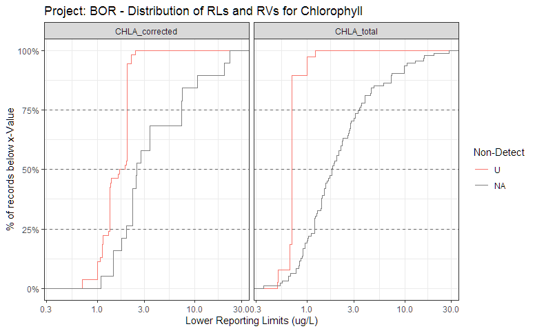

```r
CHL1016_05 %>% filter(PROJ_grp == "BOR") %>%
  filter(!is.na(Filt.Vol)) %>%
  filter(PARAM.X != "PHEO") %>%
  mutate(PARAM.X = recode(.$PARAM.X,
                          "CHLA.X" = "CHLA_total",
                          "CHLA.tot" = "CHLA_total",
                          "CHLA.aa" = "CHLA_corrected")) %>%
  mutate(Result_val = case_when(
    is.na(Non_Detect) &
      !is.na(x_RVal.conc) ~ x_RVal.conc,
    !is.na(Non_Detect) & Non_Detect == "U" &
      !is.na(LRL_c) ~ LRL_c,
    TRUE ~ as.numeric(NA))) %>%
  ggplot(.) + theme_bw() + facet_grid(. ~ PARAM.X, scales="fixed") +
  stat_ecdf(aes(x=Result_val, col=Non_Detect), na.rm=T, lty=1) +
  labs(x="Lower Reporting Limits (ug/L)", y="% of records below x-Value",
       col="Non-Detect") +
  scale_x_continuous(trans="log10") +
  scale_y_continuous(labels=scales::percent) +
  geom_hline(yintercept = c(0.25,0.5,0.75), lty=2, color="gray40") +
  ggtitle("Project: BOR - Distribution of RLs and RVs for Chlorophyll")
```

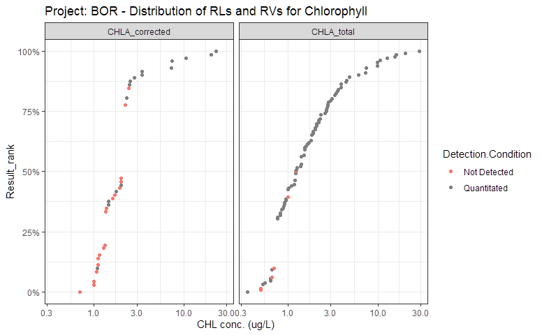

```r
CHL1016_05 %>% filter(PROJ_grp == "BOR") %>%
  filter(!is.na(Filt.Vol)) %>%
  filter(PARAM.X != "PHEO") %>%
  mutate(PARAM.X = recode(.$PARAM.X,
                          "CHLA.X" = "CHLA_total",
                          "CHLA.tot" = "CHLA_total",
                          "CHLA.aa" = "CHLA_corrected")) %>%
  mutate(Result_val = case_when(
    is.na(Non_Detect) &
      !is.na(x_RVal.conc) ~ x_RVal.conc,
    !is.na(Non_Detect) & Non_Detect == "U" &
      !is.na(LRL_c) ~ LRL_c,
    TRUE ~ as.numeric(NA))) %>%
  arrange(PARAM.X, Result_val) %>% group_by(PARAM.X) %>%
  mutate(RValue_rank = percent_rank(Result_val)) %>%
  ggplot(.) + theme_bw() + facet_grid(. ~ PARAM.X, scales="fixed") +
  geom_point(aes(x=Result_val, y=RValue_rank, col=Non_Detect), na.rm=T) +
  # EnvStats::stat_n_text() +
  labs(x="CHL conc. (ug/L)", y="Result_rank") +
  scale_x_continuous(trans="log10") +
  scale_y_continuous(labels = scales::percent) +
  ggtitle("Project: BOR - Distribution of RLs and RVs for Chlorophyll") +
  scale_color_discrete(name="Detection.Condition", labels=c("Not Detected", "Quantitated"))
```

```r
  #(rank(Result_val,na.last=NA))
```

### Bottom Line: OK

> **Non-Detect Samples in 2013-15 range for `corrected_CHLA` could be reviewed for calculation accuracy / precision, but significance is low**

> *Still need to identify a good reliable measure of relative-impact to population estimates*

## [2] BRI

- Number of unique sites in set :: 89
- Record data-range :: 2014-10-27 to 2015-09-23
- Unique Sample Events :: 447
- Methods :: 10200

### Filt.Vol completeness

```r
CHL1016_05 %>%
  filter(PROJ_grp == "BRI") %>%
  filter(PARAM.X != "PHEO") %>%
  {addmargins(table(.$RECORD_STATUS, .$import_status,
                                 useNA="ifany", deparse.level = 2))}
```

```
               .$import_status
.$RECORD_STATUS To_import  Sum
     REVIEW_VOL        99   99
     <NA>            1220 1220
     Sum             1319 1319
```

- Missing Filtration Volumes

|  | Have_filtration_vol FALSE | Have_filtration_vol TRUE |  | Sum |
| --- | --- | --- | --- | --- |
| CHL_param |  |  |  |  |
| CHLA.aa | 6 | 870 |  | 876 |
| CHLA.tot | 6 | 437 |  | 443 |
| Sum | 12 | 1307 |  | 1319 |

- Unique levels of SKey2 where Filtration Volumes are missing

|  | SKey2 | Year |
| --- | --- | --- |
| 1 | 4905000.42129.201502372 | 2015 |
| 2 | 4905052.42129.201502375 | 2015 |
| 3 | 4905170.42129.201502379 | 2015 |
| 4 | 4905200.41940.201405477 | 2014 |
| 5 | 4905301.41940.201405480 | 2014 |
| 6 | 4908735.42129.201502393 | 2015 |

*The above-listed records were investigated by TDH and RP, and no VOLs were found*

- found file w/ RP edits of Missing Volumes
- “`CHLA17_BRI_FieldMissing_180124_v02_RP.xlsx`”
- *Manual corrections*

```r
CHL1016_05 %<>% mutate(
  Filt.Vol = case_when(
    is.na(Filt.Vol) & PROJ_grp == "BRI" &
      SKey2 %in% c("4900751.42128.201502354","4900751.42207.201504442",
                   "4901225.42163.201503117","4903030.42262.201505752",
                   "4903950.42269.201505859","4904370.42164.201503215",
                   "4904940.42227.201504874","4905040.42129.201502374",
                   "4905150.42164.201503191","4905630.42227.201504889",
                   "4905640.42130.201502479","4907120.42268.201505823",
                   "4908735.42269.201505881") ~ 500,
    is.na(Filt.Vol) & PROJ_grp == "BRI" &
      SKey2 %in% c("4901100.42205.201504300","4904110.42130.201502472") ~ 150,
    is.na(Filt.Vol) & PROJ_grp == "BRI" &
      SKey2 %in% c("4904240.42207.201504430") ~ 125,
    is.na(Filt.Vol) & PROJ_grp == "BRI" &
      SKey2 %in% c("4901225.42261.201505669") ~ 350,
    is.na(Filt.Vol) & PROJ_grp == "BRI" &
      SKey2 %in% c("4901730.42129.201502427","4903260.42206.201504420",
                   "4903400.42207.201504421","4903400.42263.201505725",
                   "4903820.42263.201505732","4904510.42165.201503269",
                   "4905030.42206.201504330","4905400.42206.201504339",
                   "4905640.42206.201504343","4906100.42206.201504437",
                   "4960740.42128.201502352") ~ 250,
    is.na(Filt.Vol) & PROJ_grp == "BRI" &
      SKey2 %in% c("4901980.42262.201505747") ~ 275,
    !is.na(Filt.Vol) ~ Filt.Vol,
    TRUE ~ as.numeric(NA)),
  RECORD_STATUS = case_when(
    PROJ_grp == "BRI" & !is.na(RECORD_STATUS) &
      !is.na(Filt.Vol) ~ as.character(NA),
    !is.na(RECORD_STATUS) ~ RECORD_STATUS,
    TRUE ~ as.character(NA))
)
```

- Apply concentration calcs to updated records

```r
CHL1016_05 %<>% mutate(
  x_RVal.conc = case_when(
    is.na(x_RVal.conc) & PROJ_grp == "BRI" &
      !is.na(Filt.Vol) & is.na(Non_Detect) &
      !is.na(x_RVal) & x_Units == "mg" ~ ((x_RVal*1000) / (Filt.Vol/1000)),
    !is.na(x_RVal.conc) ~ x_RVal.conc,
    TRUE ~ as.numeric(NA)),
  LRL_c = case_when(
    PROJ_grp == "BRI" & !is.na(Filt.Vol) &
      is.na(LRL_c) & x_Units == "mg" & !is.na(Non_Detect) &
      !is.na(LRL) ~  ((LRL*1000) / (Filt.Vol/1000)),
    !is.na(LRL_c) ~ LRL_c,
    TRUE ~ as.numeric(NA)),
  MDL_c = case_when(
    PROJ_grp == "BRI" & !is.na(Filt.Vol) &
      is.na(MDL_c) & x_Units == "mg" & !is.na(Non_Detect) &
      !is.na(MDL) ~  ((MDL*1000) / (Filt.Vol/1000)),
    !is.na(MDL_c) ~ MDL_c,
    TRUE ~ as.numeric(NA))) %>%
  mutate(
    RL_Units = case_when(
      (!is.na(LRL_c) | !is.na(MDL_c)) &
        is.na(RL_Units) ~ "ug/L",
      !is.na(RL_Units) ~ RL_Units,
      TRUE ~ as.character(NA)
      )) %>%
  select(RECORD_STATUS:import_status, x_SNum, x_MLID, x_STime, SKey2, everything())
```

```r
CHL1016_05 %>% filter(PROJ_grp == "BRI") %>%
  filter(PARAM.X != "PHEO") %>% distinct(PARAM.X, SKey2, .keep_all=T) %>%
  group_by(PARAM.X) %>%
  summarize(p_CHL.calc = sprintf("%.f%%",
                                 (sum(!is.na(Filt.Vol), na.rm=T) / n())*100)) %>% htmlTable::htmlTable(., css.cell = rbind(rep("padding-left: 0.8em; padding-right: 0.8em;font-size: 0.75em;", times=ncol(.)+1), matrix("padding-left: 0.8em; padding-right: 0.8em; font-size: 0.75em;", ncol=ncol(.)+1, nrow=nrow(.))))
```

|  | PARAM.X | p_CHL.calc |
| --- | --- | --- |
| 1 | CHLA.aa | 99% |
| 2 | CHLA.tot | 99% |

- Remaining filtration volume records are not available [190904; tdh]
  - code incomplete records as REJECT

```r
CHL1016_05 %<>% mutate(
  RECORD_STATUS = case_when(
    PROJ_grp == "BRI" & is.na(Filt.Vol) &
      RECORD_STATUS == "REVIEW_VOL" ~ "REJECT_noVOL",
    !is.na(RECORD_STATUS) ~ RECORD_STATUS,
    TRUE ~ as.character(NA)))
```

### Project Non-Detects

- Proportion of Records w/ Non-Detect flags

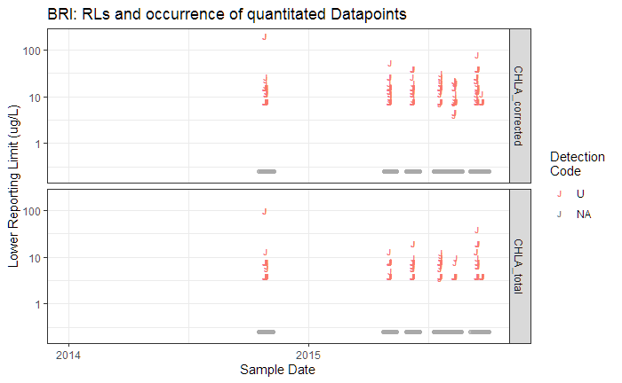

```r
CHL1016_05 %>% filter(PROJ_grp == "BRI") %>%
  filter(!is.na(Filt.Vol)) %>%
  filter(PARAM.X != "PHEO") %>%
  mutate(PARAM.X = recode(.$PARAM.X,
                          "CHLA.X" = "CHLA_total",
                          "CHLA.tot" = "CHLA_total",
                          "CHLA.aa" = "CHLA_corrected")) %>%
  distinct(SKey2, PARAM.X, Non_Detect, .keep_all = T) %>%
  ggplot(., na.rm=T) + theme_bw() +
  facet_grid(PARAM.X ~ .,  scales = "fixed") +
  geom_text(aes(x=x_SDate, y=LRL_c, col=Non_Detect),
            na.rm=T, size=2.5, fontface="bold", label="J") +
  geom_point(data=.data[[is.na(.data[["Non_Detect"]]),]], aes(y=0.25, x=.data[["x_SDate"]]),
             position = position_jitter(width=10, height=0), col="darkgray", size=1.5,
             alpha=0.75, na.rm=T) +
  scale_x_date(date_labels="%Y",date_breaks = "1 year",
               limits=c(as.Date("2014-01-01"), NA)) +
  scale_y_continuous(limits=c(0.2, NA), trans="log10") +
  labs(x="Sample Date", y="Lower Reporting Limit (ug/L)", col="Detection \nCode",
       title="BRI: RLs and occurrence of quantitated Datapoints")
```

- Due to small sample filtration volumes, some RLs are obscenely high

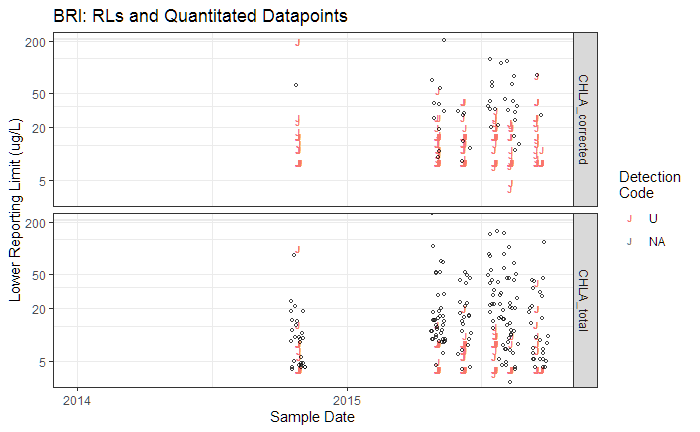

```r
CHL1016_05 %>% filter(PROJ_grp == "BRI") %>%
  filter(!is.na(Filt.Vol)) %>%
  filter(PARAM.X != "PHEO") %>%
  mutate(PARAM.X = recode(.$PARAM.X,
                          "CHLA.X" = "CHLA_total",
                          "CHLA.tot" = "CHLA_total",
                          "CHLA.aa" = "CHLA_corrected")) %>%
  distinct(SKey2, PARAM.X, .keep_all = T) %>%
  ggplot(., na.rm=T) + theme_bw() +
  geom_text(aes(x=x_SDate, y=LRL_c, col=Non_Detect),
            na.rm=T, size=2.5, fontface="bold", label="J") +
  facet_grid(PARAM.X ~ .,  scales = "fixed") +
  geom_point(aes(y=x_RVal.conc, x=x_SDate),
             position = position_jitter(width=10, height=0), size=1.2,
             alpha=0.75, na.rm=T, shape=1) +
  scale_x_date(date_labels="%Y",date_breaks = "1 year",
               limits=c(as.Date("2014-01-01"), NA)) +
  scale_y_continuous(limits=c(NA, NA), breaks=c(5, 20, 50, 200)) +
  coord_trans(y="log10", limy=c(2.5, 250)) +
  labs(x="Sample Date", y="Lower Reporting Limit (ug/L)", col="Detection \nCode",
       title="BRI: RLs and Quantitated Datapoints")
```

**Nearly complete overlap of quantitated results and RLs**

- Proportion of Records w/ Non-Detect flags
  - *Ignoring records where filtration volume is unavailable*

```r
CHL1016_05 %>% filter(PROJ_grp == "BRI") %>%
  filter(!is.na(Filt.Vol)) %>%
  filter(PARAM.X != "PHEO") %>%
  mutate(PARAM.X = recode(.$PARAM.X,
                          "CHLA.X" = "CHLA_total",
                          "CHLA.tot" = "CHLA_total",
                          "CHLA.aa" = "CHLA_corrected")) %>%
  group_by(lubridate::year(x_SDate), PARAM.X) %>%
  summarize(p_ND = sprintf("%.f%%",
                           (sum(!is.na(Non_Detect), na.rm=T) / n())*100)) %>%
  as.data.frame(.) %>%
  setNames(c("Year", "CHL_param", "p_NonDetects")) %>%
  bind_rows(.,
            CHL1016_05 %>% filter(PROJ_grp == "BRI") %>%
              filter(!is.na(Filt.Vol)) %>%
              filter(PARAM.X != "PHEO") %>%
              group_by(lubridate::year(x_SDate)) %>%
              summarize(obs = n()) %>% data.frame(., CHL_param="Obs") %>%
              setNames(c("Year", "p_NonDetects", "CHL_param")) %>%
              mutate(p_NonDetects=as.character(p_NonDetects))
            ) %>%
  spread(Year, p_NonDetects) %>%
  htmlTable::htmlTable(., css.cell = rbind(rep("padding-left: 0.8em; padding-right: 0.8em;font-size: 0.75em;", times=ncol(.)+1), matrix("padding-left: 0.8em; padding-right: 0.8em; font-size: 0.75em;", ncol=ncol(.)+1, nrow=nrow(.))), align="r|l|cc|", caption="BRI: Proportion of records (SK2) where result is Non-Detect", total=T)
```

| BRI: Proportion of records (SK2) where result is Non-Detect | BRI: Proportion of records (SK2) where result is Non-Detect CHL_param | BRI: Proportion of records (SK2) where result is Non-Detect 2014 | BRI: Proportion of records (SK2) where result is Non-Detect 2015 |
| --- | --- | --- | --- |
| 1 | CHLA_corrected | 98% | 89% |
| 2 | CHLA_total | 60% | 60% |
| 3 | Obs | 200 | 1107 |

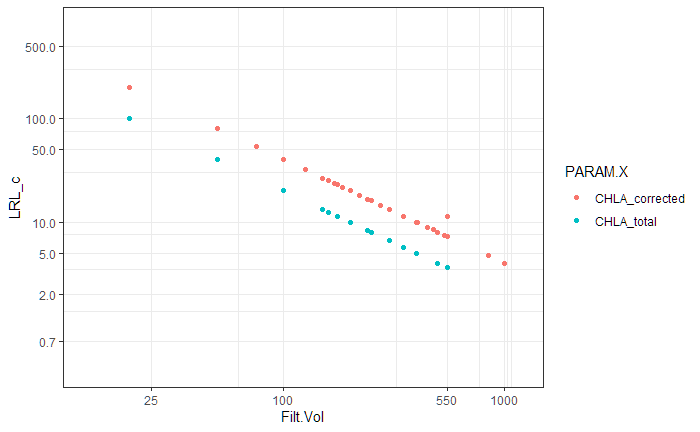

```r
CHL1016_05 %>% filter(PROJ_grp == "BRI") %>%
  filter(!is.na(Filt.Vol)) %>%
  filter(PARAM.X != "PHEO") %>%
  mutate(PARAM.X = recode(.$PARAM.X,
                          "CHLA.X" = "CHLA_total",
                          "CHLA.tot" = "CHLA_total",
                          "CHLA.aa" = "CHLA_corrected")) %>%
  ggplot(.) + theme_bw() +
  geom_point(aes(x=Filt.Vol, y=LRL_c, col=PARAM.X), na.rm=T) +
  # geom_point(aes(x=Filt.Vol, y=x_RVal.conc, col=PARAM.X), na.rm=T,
  #            position=position_jitter(width=10, height=0), shape=5, alpha=0.7) +
  coord_trans(x="log10", y="log10", limy=c(0.25, 1200), limx=c(10, 1500)) +
  scale_x_continuous(breaks=c(25, 100, 550, 1000)) +
  scale_y_continuous(breaks=c(0.7, 2, 5, 10, 50, 100, 500))
```

- Strong negative inverse (log-log) dependebnce of RL on filtration volume

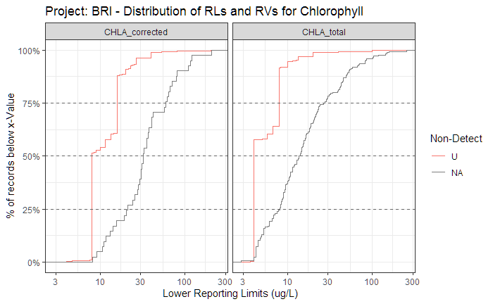

```r
CHL1016_05 %>% filter(PROJ_grp == "BRI") %>%
  filter(!is.na(Filt.Vol)) %>%
  filter(PARAM.X != "PHEO") %>%
  mutate(PARAM.X = recode(.$PARAM.X,
                          "CHLA.X" = "CHLA_total",
                          "CHLA.tot" = "CHLA_total",
                          "CHLA.aa" = "CHLA_corrected")) %>%
  mutate(Result_val = case_when(
    is.na(Non_Detect) &
      !is.na(x_RVal.conc) ~ x_RVal.conc,
    !is.na(Non_Detect) & Non_Detect == "U" &
      !is.na(LRL_c) ~ LRL_c,
    TRUE ~ as.numeric(NA))) %>%
  ggplot(.) + theme_bw() + facet_grid(. ~ PARAM.X, scales="fixed") +
  stat_ecdf(aes(x=Result_val, col=Non_Detect), na.rm=T, lty=1) +
  labs(x="Lower Reporting Limits (ug/L)", y="% of records below x-Value",
       col="Non-Detect") +
  scale_x_continuous(trans="log10") +
  scale_y_continuous(labels=scales::percent) +
  geom_hline(yintercept = c(0.25,0.5,0.75), lty=2, color="gray40") +
  ggtitle("Project: BRI - Distribution of RLs and RVs for Chlorophyll")
```

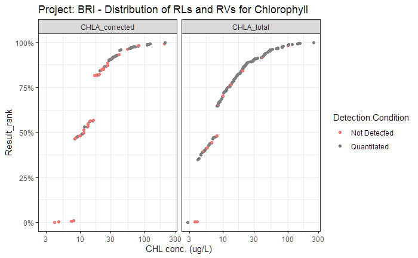

```r
CHL1016_05 %>% filter(PROJ_grp == "BRI") %>%
  filter(!is.na(Filt.Vol)) %>%
  filter(PARAM.X != "PHEO") %>%
  mutate(PARAM.X = recode(.$PARAM.X,
                          "CHLA.X" = "CHLA_total",
                          "CHLA.tot" = "CHLA_total",
                          "CHLA.aa" = "CHLA_corrected")) %>%
  mutate(Result_val = case_when(
    is.na(Non_Detect) &
      !is.na(x_RVal.conc) ~ x_RVal.conc,
    !is.na(Non_Detect) & Non_Detect == "U" &
      !is.na(LRL_c) ~ LRL_c,
    TRUE ~ as.numeric(NA))) %>%
  arrange(PARAM.X, Result_val) %>% group_by(PARAM.X) %>%
  mutate(RValue_rank = percent_rank(Result_val)) %>%
  ggplot(.) + theme_bw() + facet_grid(. ~ PARAM.X, scales="fixed") +
  geom_point(aes(x=Result_val, y=RValue_rank, col=Non_Detect), na.rm=T) +
  # EnvStats::stat_n_text() +
  labs(x="CHL conc. (ug/L)", y="Result_rank") +
  scale_x_continuous(trans="log10") +
  scale_y_continuous(labels = scales::percent) +
  ggtitle("Project: BRI - Distribution of RLs and RVs for Chlorophyll") +
  scale_color_discrete(name="Detection.Condition", labels=c("Not Detected", "Quantitated"))
```

### Bottom Line: REVW-Non-Detects (-blanks)

1. Single method, many sites, multiple reps
2. Some collections have **no sample volume** and are **rejected** :: 6
3. total completeness ~ 99%
4. Corrected and Uncorrected CHL recorded over entire set
5. No apparent change in RLs over 1-year period
6. Non-detects account for well over 80% of records for CHL-corrected, as censored data

> **Project was sampled during period of time where confidence is low re: accuracy / precision of Non-Detect flagged records, particularly for the corrected-CHL measures. Samples that are *not Blanks* should be prioritized for lab-benchsheet-review**

## [3] CUWJ

- Number of unique sites in set :: 9
- Record data-range :: 2010-06-02 to 2016-09-21
- Unique Sample Events :: 191
- Methods :: 10200, 447.0
- Params :: CHLA.X, CHLB, PHEO

|  | .$PARAM.X CHLA.X | .$PARAM.X CHLB | .$PARAM.X PHEO |  | Sum |
| --- | --- | --- | --- | --- | --- |
| .$MethodID2 |  |  |  |  |  |
| 10200 | 121 | 0 | 0 |  | 121 |
| 447.0 | 99 | 49 | 99 |  | 247 |
| Sum | 220 | 49 | 99 |  | 368 |

### Filt.Vol completeness

```r
CHL1016_05 %>%
  filter(PROJ_grp == "CUWJ") %>%
  filter(!PARAM.X %in% c("PHEO", "CHLB")) %>%
  {addmargins(table(.$RECORD_STATUS, .$import_status,
                                 useNA="ifany", deparse.level = 2))}
```

```
               .$import_status
.$RECORD_STATUS To_import Sum
     REVIEW_VOL       132 132
     <NA>              88  88
     Sum              220 220
```

- Missing Filtration Volumes

|  | Have_filtration_vol FALSE | Have_filtration_vol TRUE |  | Sum |
| --- | --- | --- | --- | --- |
| CHL_param |  |  |  |  |
| CHLA.X | 123 | 68 |  | 191 |
| Sum | 123 | 68 |  | 191 |

```r
CHL1016_05 %>% filter(PROJ_grp == "CUWJ") %>%
  filter(!PARAM.X %in% c("PHEO", "CHLB")) %>% distinct(PARAM.X, SKey2, .keep_all=T) %>%
  group_by(PARAM.X) %>%
  summarize(p_CHL.calc = sprintf("%.f%%",
                                 (sum(!is.na(x_Units.conc), na.rm=T) / n())*100)) %>% htmlTable::htmlTable(., css.cell = rbind(rep("padding-left: 0.8em; padding-right: 0.8em;font-size: 0.75em;", times=ncol(.)+1), matrix("padding-left: 0.8em; padding-right: 0.8em; font-size: 0.75em;", ncol=ncol(.)+1, nrow=nrow(.))))
```

|  | PARAM.X | p_CHL.calc |
| --- | --- | --- |
| 1 | CHLA.X | 98% |

- Time-periods where volumes missing

```r
CHL1016_05 %>% filter(PROJ_grp == "CUWJ") %>%
  filter(!PARAM.X %in% c("PHEO", "CHLB")) %>%
  mutate(PARAM.X = recode(.$PARAM.X,
                          "CHLA.X" = "CHLA_total",
                          "CHLA.tot" = "CHLA_total",
                          "CHLA.aa" = "CHLA_corrected")) %>%
  distinct(SKey2, PARAM.X, Filt.Vol, .keep_all = T) %>%
  group_by(lubridate::year(x_SDate), PARAM.X) %>%
  summarize(p_NoVol = sprintf("%.f%%",
                           (sum(!is.na(Filt.Vol), na.rm=T) / n())*100)) %>%
  as.data.frame(.) %>%
  setNames(c("Year", "CHL_param", "p_NoFiltVOL")) %>%
  spread(Year, p_NoFiltVOL) %>%
  htmlTable::htmlTable(., css.cell = rbind(rep("padding-left: 0.8em; padding-right: 0.8em;font-size: 0.75em;", times=ncol(.)+1), matrix("padding-left: 0.8em; padding-right: 0.8em; font-size: 0.75em;", ncol=ncol(.)+1, nrow=nrow(.))), caption="Percent of records where filtration volume was not reported", tfoot="Filt. volumes required for records after 2013, optional before then")
```

| Percent of records where filtration volume was not reported | Percent of records where filtration volume was not reported CHL_param | Percent of records where filtration volume was not reported 2010 | Percent of records where filtration volume was not reported 2011 | Percent of records where filtration volume was not reported 2012 | Percent of records where filtration volume was not reported 2015 | Percent of records where filtration volume was not reported 2016 |
| --- | --- | --- | --- | --- | --- | --- |
| 1 | CHLA_total | 62% | 77% | 100% | 0% | 0% |

Filt. volumes required for records after 2013, optional before then

> **No additional filtration-volumes needed**

### Project Non-detects

- Proportion of Records w/ Non-Detect flags
  - Can ignore the filtration-volume field for this project-group

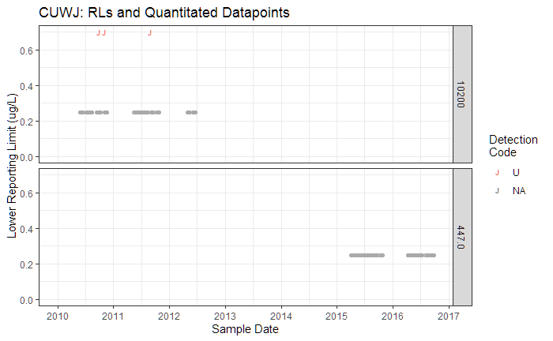

```r
CHL1016_05 %>% filter(PROJ_grp == "CUWJ") %>%
  filter(!PARAM.X %in% c("PHEO", "CHLB")) %>%
  mutate(PARAM.X = recode(.$PARAM.X,
                          "CHLA.X" = "CHLA_total",
                          "CHLA.tot" = "CHLA_total",
                          "CHLA.aa" = "CHLA_corrected")) %>%
  distinct(SKey2, PARAM.X, .keep_all = T) %>%
  ggplot(., na.rm=T) + theme_bw() +
  facet_grid(MethodID2 ~ .,  scales = "fixed") +
  geom_text(aes(x=x_SDate, y=LRL_c, col=Non_Detect),
            na.rm=T, size=2.5, fontface="bold", label="J") +
  geom_point(data=.data[[is.na(.data[["Non_Detect"]]),]], aes(y=0.25, x=.data[["x_SDate"]]),
             position = position_jitter(width=10, height=0), col="darkgray", size=1.5,
             alpha=0.75, na.rm=T) +
  scale_x_date(date_labels="%Y",date_breaks = "1 year",
               limits=c(as.Date("2010-01-01"), NA)) +
  scale_y_continuous(limits=c(0, NA)) +
  labs(x="Sample Date", y="Lower Reporting Limit (ug/L)", col="Detection \nCode",
       title="CUWJ: RLs and Quantitated Datapoints")
```

- Very few records meeting the RL

```r
CHL1016_05 %>% filter(PROJ_grp == "CUWJ") %>%
  filter(!PARAM.X %in% c("PHEO", "CHLB")) %>%
  mutate(PARAM.X = recode(.$PARAM.X,
                          "CHLA.X" = "CHLA_total",
                          "CHLA.tot" = "CHLA_total",
                          "CHLA.aa" = "CHLA_corrected")) %>%
  distinct(SKey2, PARAM.X, .keep_all = T) %>%
  group_by(lubridate::year(x_SDate), PARAM.X) %>%
  summarize(p_ND = sprintf("%.f%%",
                           (sum(!is.na(Non_Detect), na.rm=T) / n())*100)) %>%
  as.data.frame(.) %>%
  setNames(c("Year", "CHL_param", "p_NonDetects")) %>%
  spread(Year, p_NonDetects) %>%
  htmlTable::htmlTable(., css.cell = rbind(rep("padding-left: 0.8em; padding-right: 0.8em;font-size: 0.75em;", times=ncol(.)+1), matrix("padding-left: 0.8em; padding-right: 0.8em; font-size: 0.75em;", ncol=ncol(.)+1, nrow=nrow(.))))
```

|  | CHL_param | 2010 | 2011 | 2012 | 2015 | 2016 |
| --- | --- | --- | --- | --- | --- | --- |
| 1 | CHLA_total | 5% | 3% | 0% | 0% | 0% |

- Table, CHLA only, uniq(SKey2) :: Non-Detects vs. Vols

```r
CHL1016_05 %>% filter(PROJ_grp == "CUWJ") %>%
  filter(!PARAM.X %in% c("PHEO", "CHLB")) %>%
  mutate(PARAM.X = recode(.$PARAM.X,
                          "CHLA.X" = "CHLA_total",
                          "CHLA.tot" = "CHLA_total",
                          "CHLA.aa" = "CHLA_corrected")) %>%
  distinct(SKey2, PARAM.X, .keep_all = T) %>%
  {(table(is.na(.$Non_Detect), is.na(.$Filt.Vol),
                    useNA="ifany", deparse.level = 2, dnn=c("Non-Detect", "No Filt-Vols")))}
```

```
          No Filt-Vols
Non-Detect FALSE TRUE
     FALSE     2    1
     TRUE     66  122
```

### Bottom Line: OK

> This project `CUWJ` is suffiently complete. No additional volumes required, and no questionable RLs

## [4] JRULI

- Number of unique sites in set :: 72
- Record data-range :: 2010-01-19 to 2012-09-20
- Unique Sample Events :: 1002
- Methods :: 10200
- Params :: CHLA.X, CHLA.tot
  - *These parameter names are equivalent*

### Filt.Vol completeness

```r
CHL1016_05 %>%
  filter(PROJ_grp == "JRULI") %>%
  filter(PARAM.X != "PHEO") %>%
  {addmargins(table(.$RECORD_STATUS, .$import_status,
                                 useNA="ifany", deparse.level = 2))}
```

```
               .$import_status
.$RECORD_STATUS To_import utlk_01  Sum
     REVIEW_VOL       320       1  321
     <NA>             656      31  687
     Sum              976      32 1008
```

- Some records *may* have been imported w/ the UTLK chl group, but continue all work and evaluate this at the end, prior to import to awqms
- Missing Filtration Volumes

|  | Have_filtration_vol FALSE | Have_filtration_vol TRUE |  | Sum |
| --- | --- | --- | --- | --- |
| CHL_param |  |  |  |  |
| CHLA.tot | 0 | 4 |  | 4 |
| CHLA.X | 321 | 683 |  | 1004 |
| Sum | 321 | 687 |  | 1008 |

- Unique levels of SKey2 where Filtration Volumes are missing
  - See table above, 321 records
- Unique MLIDs where Filtration Volumes are missing

|  | 2010 | 2011 | 2012 | Sum |
| --- | --- | --- | --- | --- |
| 4940001 | 0 | 1 | 0 | 1 |
| 4990750 | 2 | 3 | 0 | 5 |
| 4990765 | 0 | 2 | 0 | 2 |
| 4990890 | 9 | 4 | 0 | 13 |
| 4991800 | 10 | 0 | 0 | 10 |
| 4991810 | 11 | 0 | 0 | 11 |
| 4991820 | 13 | 9 | 0 | 22 |
| 4991830 | 5 | 8 | 0 | 13 |
| 4991890 | 13 | 9 | 0 | 22 |
| 4992055 | 0 | 0 | 1 | 1 |
| 4992070 | 9 | 0 | 0 | 9 |
| 4992290 | 13 | 8 | 0 | 21 |
| 4992320 | 13 | 8 | 0 | 21 |
| 4992480 | 13 | 8 | 0 | 21 |
| 4992500 | 10 | 0 | 0 | 10 |
| 4992890 | 12 | 8 | 0 | 20 |
| 4992930 | 0 | 0 | 1 | 1 |
| 4992970 | 12 | 8 | 0 | 20 |
| 4993580 | 12 | 8 | 0 | 20 |
| 4994160 | 11 | 0 | 0 | 11 |
| 4994270 | 13 | 8 | 0 | 21 |
| 4994520 | 12 | 5 | 0 | 17 |
| 4994790 | 11 | 6 | 0 | 17 |
| 4995630 | 0 | 0 | 1 | 1 |
| 4995931 | 0 | 0 | 1 | 1 |
| 4995940 | 0 | 1 | 0 | 1 |
| 4995950 | 0 | 1 | 0 | 1 |
| 4996778 | 0 | 1 | 0 | 1 |
| 4996910 | 0 | 1 | 0 | 1 |
| 4999000 | 0 | 0 | 1 | 1 |
| 5910280 | 0 | 1 | 0 | 1 |
| 5910450 | 0 | 1 | 0 | 1 |
| 5918060 | 0 | 1 | 0 | 1 |
| 5918061 | 0 | 1 | 0 | 1 |
| 5919980 | 0 | 1 | 0 | 1 |
| Sum | 204 | 112 | 5 | 321 |

> **None of these sample dates are during the time-period when filtration-volume is required** **No action required**

### Project Non-Detects

- Proportion of Records w/ Non-Detect flags
  - Can ignore the filtration-volume field for this project-group

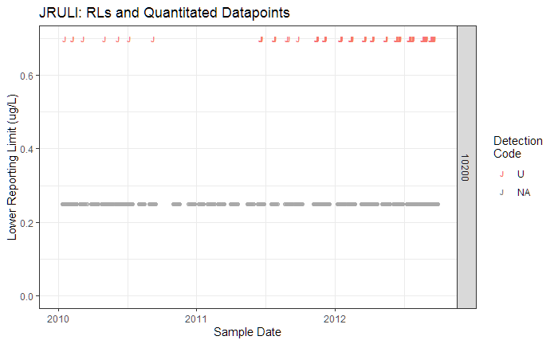

```r
CHL1016_05 %>% filter(PROJ_grp == "JRULI") %>%
  filter(!PARAM.X %in% c("PHEO", "CHLB")) %>%
  mutate(PARAM.X = recode(.$PARAM.X,
                          "CHLA.X" = "CHLA_total",
                          "CHLA.tot" = "CHLA_total",
                          "CHLA.aa" = "CHLA_corrected")) %>%
  distinct(SKey2, PARAM.X, .keep_all = T) %>%
  ggplot(., na.rm=T) + theme_bw() +
  facet_grid(MethodID2 ~ .,  scales = "fixed") +
  geom_text(aes(x=x_SDate, y=LRL_c, col=Non_Detect),
            na.rm=T, size=2.5, fontface="bold", label="J") +
  geom_point(data=.data[[is.na(.data[["Non_Detect"]]),]], aes(y=0.25, x=.data[["x_SDate"]]),
             position = position_jitter(width=10, height=0), col="darkgray", size=1.5,
             alpha=0.75, na.rm=T) +
  scale_x_date(date_labels="%Y",date_breaks = "1 year",
               limits=c(as.Date("2010-01-01"), NA)) +
  scale_y_continuous(limits=c(0, NA)) +
  labs(x="Sample Date", y="Lower Reporting Limit (ug/L)", col="Detection \nCode",
       title="JRULI: RLs and Quantitated Datapoints")
```

- Up to 1/3 of records are non-detects; *most of these sites are streams*

```r
CHL1016_05 %>% filter(PROJ_grp == "JRULI") %>%
  filter(!PARAM.X %in% c("PHEO", "CHLB")) %>%
  mutate(PARAM.X = recode(.$PARAM.X,
                          "CHLA.X" = "CHLA_total",
                          "CHLA.tot" = "CHLA_total",
                          "CHLA.aa" = "CHLA_corrected")) %>%
  distinct(SKey2, PARAM.X, .keep_all = T) %>%
  group_by(lubridate::year(x_SDate), PARAM.X) %>%
  summarize(p_ND = sprintf("%.f%%",
                           (sum(!is.na(Non_Detect), na.rm=T) / n())*100)) %>%
  as.data.frame(.) %>%
  setNames(c("Year", "CHL_param", "p_NonDetects")) %>%
  spread(Year, p_NonDetects) %>%
  htmlTable::htmlTable(., css.cell = rbind(rep("padding-left: 0.8em; padding-right: 0.8em;font-size: 0.75em;", times=ncol(.)+1), matrix("padding-left: 0.8em; padding-right: 0.8em; font-size: 0.75em;", ncol=ncol(.)+1, nrow=nrow(.))))
```

|  | CHL_param | 2010 | 2011 | 2012 |
| --- | --- | --- | --- | --- |
| 1 | CHLA_total | 4% | 30% | 31% |

### Bottom Line: OK

> JRULI project is sufficiently complete (volumes) and sensitive (%RLs); on additional action needed

## [5] LAKES

- Number of unique sites in set :: 260
- Record data-range :: 2010-06-03 to 2016-10-19
- Unique Sample Events :: 610
- Methods :: 10200
- Params :: CHLA.aa, CHLA.tot, PHEO, CHLA.X

### Filt.Vol completeness

```r
CHL1016_05 %>%
  filter(PROJ_grp == "LAKES") %>%
  filter(PARAM.X != "PHEO") %>%
  {addmargins(table(.$RECORD_STATUS, .$import_status,
                                 useNA="ifany", deparse.level = 2))}
```

```
               .$import_status
.$RECORD_STATUS To_import utlk_01  Sum
     REVIEW_lrl        20       4   24
     REVIEW_mdl        78      12   90
     REVIEW_VOL        84       0   84
     <NA>             806      88  894
     Sum              988     104 1092
```

- Some records *may* have been imported w/ the UTLK chl group, but continue all work and evaluate this at the end, prior to import to awqms
- Missing Filtration Volumes

|  | Have_filtration_vol FALSE | Have_filtration_vol TRUE |  | Sum |
| --- | --- | --- | --- | --- |
| CHL_param |  |  |  |  |
| CHLA.aa | 13 | 412 |  | 425 |
| CHLA.tot | 13 | 408 |  | 421 |
| CHLA.X | 48 | 198 |  | 246 |
| Sum | 74 | 1018 |  | 1092 |

- Unique levels of SKey2 where Filtration Volumes are missing

|  | SKey2 | Year |
| --- | --- | --- |
| 1 | 4900430.42270.201505943 | 2015 |
| 2 | 4900440.42270.201505941 | 2015 |
| 3 | 4900460.42270.201505944 | 2015 |
| 4 | 4917770.41570.201305653 | 2013 |
| 5 | 4930005.40786.201104775 | 2011 |
| 6 | 4935500.40798.201105122 | 2011 |
| 7 | 4935520.40798.201105124 | 2011 |
| 8 | 4935530.40798.201105126 | 2011 |
| 9 | 4936050.40612.201100903 | 2011 |
| 10 | 4936070.40612.201100905 | 2011 |
| 11 | 4936070.41415.201302420 | 2013 |
| 12 | 4936760.40764.201104108 | 2011 |
| 13 | 4937200.40784.201104777 | 2011 |
| 14 | 4937860.40700.201102340 | 2011 |
| 15 | 4939490.40785.201104789 | 2011 |
| 16 | 4992190.40367.201003172 | 2010 |
| 17 | 5900970.42269.201505946 | 2015 |
| 18 | 5900980.42269.201505947 | 2015 |
| 19 | 5900990.42269.201505948 | 2015 |
| 20 | 5901000.42269.201505949 | 2015 |
| 21 | 5901670.42271.201505950 | 2015 |
| 22 | 5901720.42271.201505952 | 2015 |
| 23 | 5912830.40415.201004730 | 2010 |
| 24 | 5916470.40366.201003137 | 2010 |
| 25 | 5917610.40388.201003768 | 2010 |
| 26 | 5917620.40388.201003770 | 2010 |
| 27 | 5936210.40798.201105127 | 2011 |
| 28 | 5936230.40798.201105129 | 2011 |
| 29 | 5936760.40764.201104110 | 2011 |
| 30 | 5938330.40799.201105130 | 2011 |
| 31 | 5938370.40799.201105131 | 2011 |
| 32 | 5939320.40785.201104778 | 2011 |
| 33 | 5939340.40785.201104780 | 2011 |
| 34 | 5939370.40785.201104782 | 2011 |
| 35 | 5939371.40785.201104784 | 2011 |
| 36 | 5939400.40785.201104786 | 2011 |
| 37 | 5939450.40785.201104788 | 2011 |
| 38 | 5939860.40785.201104790 | 2011 |
| 39 | 5941280.41865.201403645 | 2014 |
| 40 | 5941450.40793.201105007 | 2011 |
| 41 | 5951000.41843.201403208 | 2014 |
| 42 | 5952090.40792.201105003 | 2011 |
| 43 | 5960890.40386.201003744 | 2010 |

- Unique MLIDs where Filtration Volumes are missing

|  | 2010 | 2011 | 2013 | 2014 | 2015 | Sum |
| --- | --- | --- | --- | --- | --- | --- |
| 4900430 | 0 | 0 | 0 | 0 | 2 | 2 |
| 4900440 | 0 | 0 | 0 | 0 | 2 | 2 |
| 4900460 | 0 | 0 | 0 | 0 | 2 | 2 |
| 4917770 | 0 | 0 | 2 | 0 | 0 | 2 |
| 4930005 | 0 | 2 | 0 | 0 | 0 | 2 |
| 4935500 | 0 | 2 | 0 | 0 | 0 | 2 |
| 4935520 | 0 | 2 | 0 | 0 | 0 | 2 |
| 4935530 | 0 | 1 | 0 | 0 | 0 | 1 |
| 4936050 | 0 | 1 | 0 | 0 | 0 | 1 |
| 4936070 | 0 | 1 | 2 | 0 | 0 | 3 |
| 4936760 | 0 | 2 | 0 | 0 | 0 | 2 |
| 4937200 | 0 | 2 | 0 | 0 | 0 | 2 |
| 4937860 | 0 | 1 | 0 | 0 | 0 | 1 |
| 4939490 | 0 | 1 | 0 | 0 | 0 | 1 |
| 4992190 | 1 | 0 | 0 | 0 | 0 | 1 |
| 5900970 | 0 | 0 | 0 | 0 | 2 | 2 |
| 5900980 | 0 | 0 | 0 | 0 | 2 | 2 |
| 5900990 | 0 | 0 | 0 | 0 | 2 | 2 |
| 5901000 | 0 | 0 | 0 | 0 | 2 | 2 |
| 5901670 | 0 | 0 | 0 | 0 | 2 | 2 |
| 5901720 | 0 | 0 | 0 | 0 | 2 | 2 |
| 5912830 | 1 | 0 | 0 | 0 | 0 | 1 |
| 5916470 | 1 | 0 | 0 | 0 | 0 | 1 |
| 5917610 | 1 | 0 | 0 | 0 | 0 | 1 |
| 5917620 | 1 | 0 | 0 | 0 | 0 | 1 |
| 5936210 | 0 | 2 | 0 | 0 | 0 | 2 |
| 5936230 | 0 | 1 | 0 | 0 | 0 | 1 |
| 5936760 | 0 | 2 | 0 | 0 | 0 | 2 |
| 5938330 | 0 | 2 | 0 | 0 | 0 | 2 |
| 5938370 | 0 | 2 | 0 | 0 | 0 | 2 |
| 5939320 | 0 | 2 | 0 | 0 | 0 | 2 |
| 5939340 | 0 | 2 | 0 | 0 | 0 | 2 |
| 5939370 | 0 | 2 | 0 | 0 | 0 | 2 |
| 5939371 | 0 | 2 | 0 | 0 | 0 | 2 |
| 5939400 | 0 | 2 | 0 | 0 | 0 | 2 |
| 5939450 | 0 | 2 | 0 | 0 | 0 | 2 |
| 5939860 | 0 | 2 | 0 | 0 | 0 | 2 |
| 5941280 | 0 | 0 | 0 | 2 | 0 | 2 |
| 5941450 | 0 | 2 | 0 | 0 | 0 | 2 |
| 5951000 | 0 | 0 | 0 | 2 | 0 | 2 |
| 5952090 | 0 | 2 | 0 | 0 | 0 | 2 |
| 5960890 | 1 | 0 | 0 | 0 | 0 | 1 |
| Sum | 6 | 42 | 4 | 4 | 18 | 74 |

- Records after late-September (2012) need filtration volumes to support CHL-concentration calculations
  - RE-code `RECORD_STATUS`, omit “REVIEW_VOL” elements if sample date < sep 2012

```r
# CHL1016_05 -> CHL1016_05.copy
# CHL1016_05 <- CHL1016_05.copy
```

```r
CHL1016_05 %>% filter(PROJ_grp == "LAKES" & !is.na(RECORD_STATUS)) %>% distinct(RECORD_STATUS) %$% .$RECORD_STATUS
```

```
[1] "REVIEW_VOL" "REVIEW_mdl" "REVIEW_lrl"
```

```r
CHL1016_05 %<>% mutate(
  RECORD_STATUS = case_when(
    PROJ_grp == "LAKES" &
      RECORD_STATUS == "REVIEW_VOL" &
      is.na(Filt.Vol) &
      x_SDate < as.Date("2012-09-20") ~ as.character(NA),
    !is.na(RECORD_STATUS) ~ RECORD_STATUS,
    TRUE ~ as.character(NA)))
```

- Re-run table using `RECORD_STATUS` category (*sites w/ missing filt. volume*)

|  | 2013 | 2014 | 2015 | Sum |
| --- | --- | --- | --- | --- |
| 4900430 | 0 | 0 | 2 | 2 |
| 4900440 | 0 | 0 | 2 | 2 |
| 4900460 | 0 | 0 | 2 | 2 |
| 4917770 | 2 | 0 | 0 | 2 |
| 4936070 | 2 | 0 | 0 | 2 |
| 5900970 | 0 | 0 | 2 | 2 |
| 5900980 | 0 | 0 | 2 | 2 |
| 5900990 | 0 | 0 | 2 | 2 |
| 5901000 | 0 | 0 | 2 | 2 |
| 5901670 | 0 | 0 | 2 | 2 |
| 5901720 | 0 | 0 | 2 | 2 |
| 5941280 | 0 | 2 | 0 | 2 |
| 5951000 | 0 | 2 | 0 | 2 |
| Sum | 4 | 4 | 18 | 26 |

- Unique SKey2 levels ::

|  | 2013 | 2014 | 2015 | Sum |
| --- | --- | --- | --- | --- |
| 4900430.42270.201505943 | 0 | 0 | 2 | 2 |
| 4900440.42270.201505941 | 0 | 0 | 2 | 2 |
| 4900460.42270.201505944 | 0 | 0 | 2 | 2 |
| 4917770.41570.201305653 | 2 | 0 | 0 | 2 |
| 4936070.41415.201302420 | 2 | 0 | 0 | 2 |
| 5900970.42269.201505946 | 0 | 0 | 2 | 2 |
| 5900980.42269.201505947 | 0 | 0 | 2 | 2 |
| 5900990.42269.201505948 | 0 | 0 | 2 | 2 |
| 5901000.42269.201505949 | 0 | 0 | 2 | 2 |
| 5901670.42271.201505950 | 0 | 0 | 2 | 2 |
| 5901720.42271.201505952 | 0 | 0 | 2 | 2 |
| 5941280.41865.201403645 | 0 | 2 | 0 | 2 |
| 5951000.41843.201403208 | 0 | 2 | 0 | 2 |
| Sum | 4 | 4 | 18 | 26 |

#### Filt. Vol research & corrections

- **2013**

```r
CHL1016_05 %>%
  filter(PROJ_grp == "LAKES" & RECORD_STATUS == "REVIEW_VOL") %>%
  filter(PARAM.X != "PHEO") %>% mutate(Year = lubridate::year(.$x_SDate)) %>%
  filter(is.na(Filt.Vol) & Year == 2013) %>% distinct(SKey2) %>%
  htmlTable::htmlTable(., css.cell = rbind(rep("padding-left: 0.8em; padding-right: 0.8em;font-size: 0.75em;", times=ncol(.)+1), matrix("padding-left: 0.8em; padding-right: 0.8em; font-size: 0.75em;", ncol=ncol(.)+1, nrow=nrow(.))))
```

|  | SKey2 |
| --- | --- |
| 1 | 4917770.41570.201305653 |
| 2 | 4936070.41415.201302420 |

> 2013: Confirmed, no volumes available for two records
- **2014**

```r
CHL1016_05 %>%
  filter(PROJ_grp == "LAKES" & RECORD_STATUS == "REVIEW_VOL") %>%
  filter(PARAM.X != "PHEO") %>% mutate(Year = lubridate::year(.$x_SDate)) %>%
  filter(is.na(Filt.Vol) & Year == 2014) %>% distinct(SKey2) %>%
  htmlTable::htmlTable(., css.cell = rbind(rep("padding-left: 0.8em; padding-right: 0.8em;font-size: 0.75em;", times=ncol(.)+1), matrix("padding-left: 0.8em; padding-right: 0.8em; font-size: 0.75em;", ncol=ncol(.)+1, nrow=nrow(.))))
```

|  | SKey2 |
| --- | --- |
| 1 | 5941280.41865.201403645 |
| 2 | 5951000.41843.201403208 |

> 2014: Confirmed, no volumes available for two records
- group volumes range from 100 to 500; 250 and 500 mL most common
- **2015**

```r
CHL1016_05 %>%
  filter(PROJ_grp == "LAKES" & RECORD_STATUS == "REVIEW_VOL") %>%
  filter(PARAM.X != "PHEO") %>% mutate(Year = lubridate::year(.$x_SDate)) %>%
  filter(is.na(Filt.Vol) & Year == 2015) %>% distinct(SKey2, x_SDate) %>%
  htmlTable::htmlTable(., css.cell = rbind(rep("padding-left: 0.8em; padding-right: 0.8em;font-size: 0.75em;", times=ncol(.)+1), matrix("padding-left: 0.8em; padding-right: 0.8em; font-size: 0.75em;", ncol=ncol(.)+1, nrow=nrow(.))))
```

|  | SKey2 | x_SDate |
| --- | --- | --- |
| 1 | 4900430.42270.201505943 | 2015-09-23 |
| 2 | 4900440.42270.201505941 | 2015-09-23 |
| 3 | 4900460.42270.201505944 | 2015-09-23 |
| 4 | 5900970.42269.201505946 | 2015-09-22 |
| 5 | 5900980.42269.201505947 | 2015-09-22 |
| 6 | 5900990.42269.201505948 | 2015-09-22 |
| 7 | 5901000.42269.201505949 | 2015-09-22 |
| 8 | 5901670.42271.201505950 | 2015-09-24 |
| 9 | 5901720.42271.201505952 | 2015-09-24 |

- 250 mL common for trip…

> 2015: confirmed, no vols available
- **2016**

```r
CHL1016_05 %>%
  filter(PROJ_grp == "LAKES" & RECORD_STATUS == "REVIEW_VOL") %>%
  filter(PARAM.X != "PHEO") %>% mutate(Year = lubridate::year(.$x_SDate)) %>%
  filter(is.na(Filt.Vol) & Year == 2016) %>% distinct(SKey2, x_SDate) %>%
  htmlTable::htmlTable(., css.cell = rbind(rep("padding-left: 0.8em; padding-right: 0.8em;font-size: 0.75em;", times=ncol(.)+1), matrix("padding-left: 0.8em; padding-right: 0.8em; font-size: 0.75em;", ncol=ncol(.)+1, nrow=nrow(.))))
```

|  | SKey2 | x_SDate |
| --- | --- | --- |
| 1 | 4900460.42585.2011077 | 2016-08-03 |
| 2 | 4940610.42578.2010710 | 2016-07-27 |
| 3 | 4940720.42578.2010720 | 2016-07-27 |
| 4 | 5941450.42579.2010727 | 2016-07-28 |
| 5 | 5941451.42579.2010736 | 2016-07-28 |

- Found volume edits for these sets (file:: `"W:\2016_Data\2016_Hydrodata\2016_Hydro_AWQMS_Import\Imported\2016_DWQ_Lakes_Q3_Field_Combined.xlsx"`)
  - 250 mL (from trip sheets, etc.; RB comments)
- **Add vols for LAKES 2016 samples (above)**

```r
CHL1016_05 %<>% mutate(
  Filt.Vol = case_when(
    RECORD_STATUS == "REVIEW_VOL" &
      PROJ_grp == "LAKES" &
      lubridate::year(.$x_SDate) == 2016 &
      is.na(Filt.Vol) &
      SKey2 %in% c("4900460.42585.2011077", "4940610.42578.2010710",
                   "4940720.42578.2010720", "5941450.42579.2010727",
                   "5941451.42579.2010736") ~ 250,
    !is.na(Filt.Vol) ~ Filt.Vol,
    TRUE ~ as.numeric(NA)),
  RECORD_STATUS = case_when(
    RECORD_STATUS == "REVIEW_VOL" &
      PROJ_grp == "LAKES" &
      lubridate::year(.$x_SDate) == 2016 &
      SKey2 %in% c("4900460.42585.2011077", "4940610.42578.2010710",
                   "4940720.42578.2010720", "5941450.42579.2010727",
                   "5941451.42579.2010736") ~ as.character(NA),
    !is.na(RECORD_STATUS) ~ RECORD_STATUS,
    TRUE ~ as.character(NA))
)
# CHL1016_05 %>%
#   filter(RECORD_STATUS == "REVIEW_VOL" &
#       PROJ_grp == "LAKES" &
#       lubridate::year(.$x_SDate) == 2016 &
#       is.na(Filt.Vol)) %>% distinct(SKey2, x_SDate)
```

### Project Non-Detects

- Proportion of Records w/ Non-Detect flags
  - Can ignore the filtration-volume field for this project-group

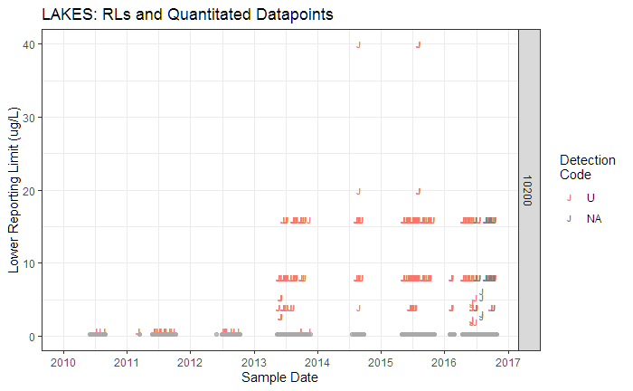

```r
CHL1016_05 %>% filter(PROJ_grp == "LAKES") %>%
  filter(!PARAM.X %in% c("PHEO", "CHLB")) %>%
  mutate(PARAM.X = recode(.$PARAM.X,
                          "CHLA.X" = "CHLA_total",
                          "CHLA.tot" = "CHLA_total",
                          "CHLA.aa" = "CHLA_corrected")) %>%
  distinct(SKey2, PARAM.X, .keep_all = T) %>%
  ggplot(., na.rm=T) + theme_bw() +
  facet_grid(MethodID2 ~ .,  scales = "fixed") +
  geom_text(aes(x=x_SDate, y=LRL_c, col=Non_Detect),
            na.rm=T, size=2.5, fontface="bold", label="J") +
  geom_point(data=.data[[is.na(.data[["Non_Detect"]]),]], aes(y=0.25, x=.data[["x_SDate"]]),
             position = position_jitter(width=10, height=0), col="darkgray", size=1.5,
             alpha=0.75, na.rm=T) +
  scale_x_date(date_labels="%Y",date_breaks = "1 year",
               limits=c(as.Date("2010-01-01"), NA)) +
  scale_y_continuous(limits=c(0, NA)) +
  labs(x="Sample Date", y="Lower Reporting Limit (ug/L)", col="Detection \nCode",
       title="LAKES: RLs and Quantitated Datapoints")
```

- Few records meeting the RL

```r
CHL1016_05 %>% filter(PROJ_grp == "LAKES") %>%
  filter(!PARAM.X %in% c("PHEO", "CHLB")) %>%
  mutate(PARAM.X = recode(.$PARAM.X,
                          "CHLA.X" = "CHLA_total",
                          "CHLA.tot" = "CHLA_total",
                          "CHLA.aa" = "CHLA_corrected")) %>%
  distinct(SKey2, PARAM.X, .keep_all = T) %>%
  group_by(lubridate::year(x_SDate), PARAM.X) %>%
  summarize(p_ND = sprintf("%.f%%",
                           (sum(!is.na(Non_Detect), na.rm=T) / n())*100)) %>%
  as.data.frame(.) %>%
  setNames(c("Year", "CHL_param", "p_NonDetects")) %>%
  spread(Year, p_NonDetects) %>%
  htmlTable::htmlTable(., css.cell = rbind(rep("padding-left: 0.8em; padding-right: 0.8em;font-size: 0.75em;", times=ncol(.)+1), matrix("padding-left: 0.8em; padding-right: 0.8em; font-size: 0.75em;", ncol=ncol(.)+1, nrow=nrow(.))))
```

|  | CHL_param | 2010 | 2011 | 2012 | 2013 | 2014 | 2015 | 2016 |
| --- | --- | --- | --- | --- | --- | --- | --- | --- |
| 1 | CHLA_corrected |  |  | 0% | 81% | 73% | 84% | 66% |
| 2 | CHLA_total | 18% | 32% | 50% | 59% | 43% | 64% | 44% |

- Table, CHLA only, uniq(SKey2) :: Non-Detects vs. Vols

```r
CHL1016_05 %>% filter(PROJ_grp == "LAKES") %>%
  filter(!PARAM.X %in% c("PHEO", "CHLB")) %>%
  mutate(PARAM.X = recode(.$PARAM.X,
                          "CHLA.X" = "CHLA_total",
                          "CHLA.tot" = "CHLA_total",
                          "CHLA.aa" = "CHLA_corrected")) %>%
  distinct(SKey2, PARAM.X, .keep_all = T) %>%
  {(table(is.na(.$Non_Detect), is.na(.$Filt.Vol),
                    useNA="ifany", deparse.level = 2, dnn=c("Non-Detect", "No Filt-Vols")))}
```

```
          No Filt-Vols
Non-Detect FALSE TRUE
     FALSE   593   21
     TRUE    386   35
```

### Bottom Line: REVW-Non-Detects (-blanks)

> LAKES project has sufficient Filtration-Volume completion, but the RLs may need to be examined, particularly in 2013-15

## [6] NPS

- Number of unique sites in set :: 1
- Record data-range :: 2013-08-13 to 2013-08-13
- Unique Sample Events :: 1
- Methods :: 10200
- Params :: CHLA.aa, CHLA.tot, PHEO

### Filt.Vol completeness

```r
CHL1016_05 %>%
  filter(PROJ_grp == "NPS") %>%
  filter(PARAM.X != "PHEO") %>%
  {addmargins(table(.$RECORD_STATUS, .$import_status,
                                 useNA="ifany", deparse.level = 2))}
```

```
               .$import_status
.$RECORD_STATUS To_import Sum
     REVIEW_VOL         2   2
     Sum                2   2
```

|  | Have_filtration_vol FALSE |  | Sum |
| --- | --- | --- | --- |
| CHL_param |  |  |  |
| CHLA.aa | 1 |  | 1 |
| CHLA.tot | 1 |  | 1 |
| Sum | 2 |  | 2 |

- Unique levels of SKey2 where Filtration Volumes are missing

|  | SKey2 | Year |
| --- | --- | --- |
| 1 | 5995700.41499.201304255 | 2013 |

### Bottom Line: Ignore/Skip

> Only 1 sample, no volumes found in e-records; No Action - skip

## [7] SBCI

- Number of unique sites in set :: 7
- Record data-range :: 2013-10-30 to 2014-09-17
- Unique Sample Events :: 62
- Methods :: 10200
- Params :: CHLA.aa, CHLA.tot, PHEO

### Filt.Vol completeness

```r
CHL1016_05 %>%
  filter(PROJ_grp == "SBCI") %>%
  filter(PARAM.X != "PHEO") %>%
  {addmargins(table(.$RECORD_STATUS, .$import_status,
                                 useNA="ifany", deparse.level = 2))}
```

```
               .$import_status
.$RECORD_STATUS To_import Sum
     REVIEW_VOL         2   2
     <NA>             122 122
     Sum              124 124
```

- Missing Filtration Volumes

|  | Have_filtration_vol FALSE | Have_filtration_vol TRUE |  | Sum |
| --- | --- | --- | --- | --- |
| CHL_param |  |  |  |  |
| CHLA.aa | 1 | 61 |  | 62 |
| CHLA.tot | 1 | 61 |  | 62 |
| Sum | 2 | 122 |  | 124 |

- No volume information found for sample missing Filt.Vol; comment says no CHL sample was collected;
- **IGNORE Volume issue**

### Project Non-Detects

- Proportion of Records w/ Non-Detect flags
  - Can ignore the filtration-volume field for this project-group

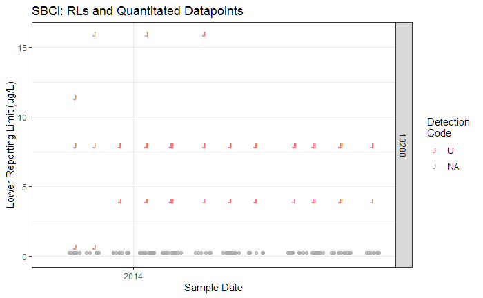

```r
CHL1016_05 %>% filter(PROJ_grp == "SBCI") %>%
  filter(!PARAM.X %in% c("PHEO", "CHLB")) %>%
  mutate(PARAM.X = recode(.$PARAM.X,
                          "CHLA.X" = "CHLA_total",
                          "CHLA.tot" = "CHLA_total",
                          "CHLA.aa" = "CHLA_corrected")) %>%
  distinct(SKey2, PARAM.X, .keep_all = T) %>%
  ggplot(., na.rm=T) + theme_bw() +
  facet_grid(MethodID2 ~ .,  scales = "fixed") +
  geom_text(aes(x=x_SDate, y=LRL_c, col=Non_Detect),
            na.rm=T, size=2.5, fontface="bold", label="J") +
  geom_point(data=.data[[is.na(.data[["Non_Detect"]]),]], aes(y=0.25, x=.data[["x_SDate"]]),
             position = position_jitter(width=10, height=0), col="darkgray", size=1.5,
             alpha=0.75, na.rm=T) +
  scale_x_date(date_labels="%Y",date_breaks = "1 year",
               limits=c(as.Date("2013-10-01"), NA)) +
  scale_y_continuous(limits=c(0, NA)) +
  labs(x="Sample Date", y="Lower Reporting Limit (ug/L)", col="Detection \nCode",
       title="SBCI: RLs and Quantitated Datapoints")
```

- Few records meeting the RL

```r
CHL1016_05 %>% filter(PROJ_grp == "SBCI") %>%
  filter(!PARAM.X %in% c("PHEO", "CHLB")) %>%
  mutate(PARAM.X = recode(.$PARAM.X,
                          "CHLA.X" = "CHLA_total",
                          "CHLA.tot" = "CHLA_total",
                          "CHLA.aa" = "CHLA_corrected")) %>%
  distinct(SKey2, PARAM.X, .keep_all = T) %>%
  group_by(lubridate::year(x_SDate), PARAM.X) %>%
  summarize(p_ND = sprintf("%.f%%",
                           (sum(!is.na(Non_Detect), na.rm=T) / n())*100)) %>%
  as.data.frame(.) %>%
  setNames(c("Year", "CHL_param", "p_NonDetects")) %>%
  spread(Year, p_NonDetects) %>%
  htmlTable::htmlTable(., css.cell = rbind(rep("padding-left: 0.8em; padding-right: 0.8em;font-size: 0.75em;", times=ncol(.)+1), matrix("padding-left: 0.8em; padding-right: 0.8em; font-size: 0.75em;", ncol=ncol(.)+1, nrow=nrow(.))))
```

|  | CHL_param | 2013 | 2014 |
| --- | --- | --- | --- |
| 1 | CHLA_corrected | 100% | 90% |
| 2 | CHLA_total | 92% | 59% |

- Table, CHLA only, uniq(SKey2) :: Non-Detects vs. Vols

```r
CHL1016_05 %>% filter(PROJ_grp == "SBCI") %>%
  filter(!PARAM.X %in% c("PHEO", "CHLB")) %>%
  mutate(PARAM.X = recode(.$PARAM.X,
                          "CHLA.X" = "CHLA_total",
                          "CHLA.tot" = "CHLA_total",
                          "CHLA.aa" = "CHLA_corrected")) %>%
  distinct(SKey2, PARAM.X, .keep_all = T) %>%
  {(table(is.na(.$Non_Detect), is.na(.$Filt.Vol),
                    useNA="ifany", deparse.level = 2, dnn=c("Non-Detect", "No Filt-Vols")))}
```

```
          No Filt-Vols
Non-Detect FALSE TRUE
     FALSE    96    2
     TRUE     26    0
```

### Bottom Line: REVW-Non-Detects (-blanks)

> These Non-Detects should be reviewed…

## [8] TMDLLAKES

- Number of unique sites in set :: 83
- Record data-range :: 2010-06-02 to 2015-05-20
- Unique Sample Events :: 407
- Methods :: 10200
- Params :: CHLA.aa, CHLA.tot, PHEO, CHLA.X

### Filt.Vol completeness

```r
CHL1016_05 %>%
  filter(PROJ_grp == "TMDLLAKES") %>%
  filter(PARAM.X != "PHEO") %>%
  {addmargins(table(.$RECORD_STATUS, .$import_status,
                                 useNA="ifany", deparse.level = 2))}
```

```
               .$import_status
.$RECORD_STATUS To_import utlk_01 Sum
     REVIEW_VOL       119      25 144
     <NA>             407      95 502
     Sum              526     120 646
```

- Missing Filtration Volumes

|  | Have_filtration_vol FALSE | Have_filtration_vol TRUE |  | Sum |
| --- | --- | --- | --- | --- |
| CHL_param |  |  |  |  |
| CHLA.aa | 14 | 123 |  | 137 |
| CHLA.tot | 14 | 114 |  | 128 |
| CHLA.X | 112 | 269 |  | 381 |
| Sum | 140 | 506 |  | 646 |

- Unique MLIDs where Filtration Volumes are missing

|  | 2010 | 2011 | 2012 | 2014 | 2015 | Sum |
| --- | --- | --- | --- | --- | --- | --- |
| 4903260 | 0 | 0 | 0 | 1 | 0 | 1 |
| 4917310 | 1 | 1 | 0 | 0 | 0 | 2 |
| 4917320 | 3 | 1 | 1 | 0 | 0 | 5 |
| 4917370 | 1 | 1 | 0 | 0 | 0 | 2 |
| 4917390 | 1 | 1 | 0 | 0 | 0 | 2 |
| 4917450 | 1 | 1 | 0 | 0 | 0 | 2 |
| 4917500 | 1 | 1 | 1 | 0 | 0 | 3 |
| 4917520 | 1 | 1 | 0 | 0 | 0 | 2 |
| 4917600 | 1 | 1 | 1 | 0 | 0 | 3 |
| 4917770 | 1 | 1 | 2 | 0 | 0 | 4 |
| 4926130 | 2 | 1 | 0 | 1 | 0 | 4 |
| 4926140 | 2 | 1 | 0 | 1 | 0 | 4 |
| 4926350 | 2 | 2 | 0 | 0 | 0 | 4 |
| 4926400 | 2 | 2 | 0 | 0 | 0 | 4 |
| 4927250 | 3 | 3 | 0 | 0 | 0 | 6 |
| 4936050 | 0 | 1 | 0 | 1 | 0 | 2 |
| 4936070 | 0 | 1 | 0 | 1 | 0 | 2 |
| 4937120 | 3 | 3 | 0 | 0 | 0 | 6 |
| 4937130 | 1 | 0 | 0 | 2 | 0 | 3 |
| 4937140 | 1 | 0 | 0 | 2 | 0 | 3 |
| 4937180 | 3 | 3 | 0 | 0 | 0 | 6 |
| 4937201 | 0 | 0 | 0 | 1 | 0 | 1 |
| 4937202 | 0 | 0 | 0 | 1 | 0 | 1 |
| 4940610 | 2 | 0 | 0 | 0 | 0 | 2 |
| 4940620 | 2 | 0 | 0 | 0 | 0 | 2 |
| 4940650 | 2 | 0 | 0 | 0 | 0 | 2 |
| 4940720 | 2 | 0 | 0 | 0 | 0 | 2 |
| 4940730 | 2 | 0 | 0 | 0 | 0 | 2 |
| 4940750 | 1 | 0 | 0 | 0 | 0 | 1 |
| 5923310 | 1 | 1 | 0 | 1 | 0 | 3 |
| 5923320 | 1 | 1 | 0 | 0 | 0 | 2 |
| 5930971 | 0 | 0 | 0 | 0 | 1 | 1 |
| 5941800 | 0 | 1 | 0 | 1 | 0 | 2 |
| 5941820 | 0 | 4 | 0 | 0 | 0 | 4 |
| 5953860 | 0 | 1 | 0 | 0 | 0 | 1 |
| 5953870 | 0 | 3 | 0 | 0 | 0 | 3 |
| 5954520 | 2 | 2 | 0 | 0 | 0 | 4 |
| 5954540 | 0 | 3 | 0 | 0 | 0 | 3 |
| Sum | 45 | 42 | 5 | 13 | 1 | 106 |

```r
CHL1016_05 %>% filter(PROJ_grp == "TMDLLAKES" & !is.na(RECORD_STATUS)) %>% distinct(RECORD_STATUS) %$% .$RECORD_STATUS
```

```
[1] "REVIEW_VOL"
```

```r
CHL1016_05 %<>% mutate(
  RECORD_STATUS = case_when(
    PROJ_grp == "TMDLLAKES" &
      RECORD_STATUS == "REVIEW_VOL" &
      is.na(Filt.Vol) &
      x_SDate < as.Date("2012-09-20") ~ as.character(NA),
    !is.na(RECORD_STATUS) ~ RECORD_STATUS,
    TRUE ~ as.character(NA)))
```

- Re-run table using `RECORD_STATUS` category (*sites w/ missing filt. volume*)

|  | 2014 | 2015 | Sum |
| --- | --- | --- | --- |
| 4903260 | 2 | 0 | 2 |
| 4926130 | 2 | 0 | 2 |
| 4926140 | 2 | 0 | 2 |
| 4936050 | 2 | 0 | 2 |
| 4936070 | 2 | 0 | 2 |
| 4937130 | 4 | 0 | 4 |
| 4937140 | 4 | 0 | 4 |
| 4937201 | 2 | 0 | 2 |
| 4937202 | 2 | 0 | 2 |
| 5923310 | 2 | 0 | 2 |
| 5930971 | 0 | 2 | 2 |
| 5941800 | 2 | 0 | 2 |
| Sum | 26 | 2 | 28 |

- Unique SKey2 levels ::

|  | 2014 | 2015 | Sum |
| --- | --- | --- | --- |
| 4903260.41842.201403279 | 2 | 0 | 2 |
| 4926130.41780.201402040 | 2 | 0 | 2 |
| 4926140.41780.201402044 | 2 | 0 | 2 |
| 4936050.41886.201404093 | 2 | 0 | 2 |
| 4936070.41886.201404091 | 2 | 0 | 2 |
| 4937130.41836.201403125 | 2 | 0 | 2 |
| 4937130.41891.201404167 | 2 | 0 | 2 |
| 4937140.41836.201403126 | 2 | 0 | 2 |
| 4937140.41891.201404168 | 2 | 0 | 2 |
| 4937201.41891.201404169 | 2 | 0 | 2 |
| 4937202.41891.201404170 | 2 | 0 | 2 |
| 5923310.41779.201402033 | 2 | 0 | 2 |
| 5930971.42018.201500277 | 0 | 2 | 2 |
| 5941800.41844.201403210 | 2 | 0 | 2 |
| Sum | 26 | 2 | 28 |

```r
CHL1016_05 %>%
  filter(PROJ_grp == "TMDLLAKES" & RECORD_STATUS == "REVIEW_VOL") %>%
  filter(PARAM.X != "PHEO") %>% mutate(Year = lubridate::year(.$x_SDate)) %>%
  filter(is.na(Filt.Vol) & Year > 2013) %>% distinct(SKey2, x_SDate) %>%
  htmlTable::htmlTable(., css.cell = rbind(rep("padding-left: 0.8em; padding-right: 0.8em;font-size: 0.75em;", times=ncol(.)+1), matrix("padding-left: 0.8em; padding-right: 0.8em; font-size: 0.75em;", ncol=ncol(.)+1, nrow=nrow(.))))
```

|  | SKey2 | x_SDate |
| --- | --- | --- |
| 1 | 4903260.41842.201403279 | 2014-07-22 |
| 2 | 4926130.41780.201402040 | 2014-05-21 |
| 3 | 4926140.41780.201402044 | 2014-05-21 |
| 4 | 4936050.41886.201404093 | 2014-09-04 |
| 5 | 4936070.41886.201404091 | 2014-09-04 |
| 6 | 4937130.41836.201403125 | 2014-07-16 |
| 7 | 4937130.41891.201404167 | 2014-09-09 |
| 8 | 4937140.41836.201403126 | 2014-07-16 |
| 9 | 4937140.41891.201404168 | 2014-09-09 |
| 10 | 4937201.41891.201404169 | 2014-09-09 |
| 11 | 4937201.42144.201502807 | 2015-05-20 |
| 12 | 4937202.41891.201404170 | 2014-09-09 |
| 13 | 4937202.42144.201502806 | 2015-05-20 |
| 14 | 5923310.41779.201402033 | 2014-05-20 |
| 15 | 5930971.42018.201500277 | 2015-01-14 |
| 16 | 5941800.41844.201403210 | 2014-07-24 |

- Found vols for 2 records in 2015 (May):
  - 4937201.42144.201502807
  - 4937202.42144.201502806
  - 250 mL filtered
- **Add vols for TMDLLAKES 2015 samples (above)**

```r
CHL1016_05 %<>% mutate(
  Filt.Vol = case_when(
    RECORD_STATUS == "REVIEW_VOL" &
      PROJ_grp == "TMDLLAKES" &
      is.na(Filt.Vol) &
      SKey2 %in% c("4937201.42144.201502807", "4937202.42144.201502806") ~ 250,
    !is.na(Filt.Vol) ~ Filt.Vol,
    TRUE ~ as.numeric(NA)),
  RECORD_STATUS = case_when(
    RECORD_STATUS == "REVIEW_VOL" &
      PROJ_grp == "TMDLLAKES" &
      SKey2 %in% c("4937201.42144.201502807", "4937202.42144.201502806") ~ as.character(NA),
    !is.na(RECORD_STATUS) ~ RECORD_STATUS,
    TRUE ~ as.character(NA))
)
```

### Project Non-Detects

- Proportion of Records w/ Non-Detect flags
  - Can ignore the filtration-volume field for this project-group

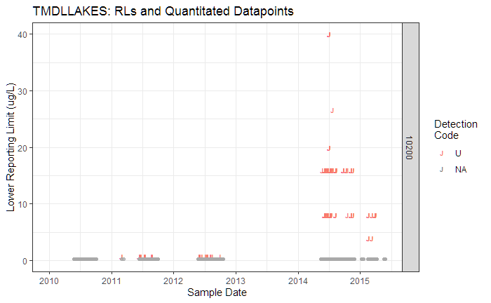

```r
CHL1016_05 %>% filter(PROJ_grp == "TMDLLAKES") %>%
  filter(!PARAM.X %in% c("PHEO", "CHLB")) %>%
  mutate(PARAM.X = recode(.$PARAM.X,
                          "CHLA.X" = "CHLA_total",
                          "CHLA.tot" = "CHLA_total",
                          "CHLA.aa" = "CHLA_corrected")) %>%
  distinct(SKey2, PARAM.X, .keep_all = T) %>%
  ggplot(., na.rm=T) + theme_bw() +
  facet_grid(MethodID2 ~ .,  scales = "fixed") +
  geom_text(aes(x=x_SDate, y=LRL_c, col=Non_Detect),
            na.rm=T, size=2.5, fontface="bold", label="J") +
  geom_point(data=.data[[is.na(.data[["Non_Detect"]]),]], aes(y=0.25, x=.data[["x_SDate"]]),
             position = position_jitter(width=10, height=0), col="darkgray", size=1.5,
             alpha=0.75, na.rm=T) +
  scale_x_date(date_labels="%Y",date_breaks = "1 year",
               limits=c(as.Date("2010-01-01"), NA)) +
  scale_y_continuous(limits=c(0, NA)) +
  labs(x="Sample Date", y="Lower Reporting Limit (ug/L)", col="Detection \nCode",
       title="TMDLLAKES: RLs and Quantitated Datapoints")
```

- Few records meeting the RL

```r
CHL1016_05 %>% filter(PROJ_grp == "TMDLLAKES") %>%
  filter(!PARAM.X %in% c("PHEO", "CHLB")) %>%
  mutate(PARAM.X = recode(.$PARAM.X,
                          "CHLA.X" = "CHLA_total",
                          "CHLA.tot" = "CHLA_total",
                          "CHLA.aa" = "CHLA_corrected")) %>%
  distinct(SKey2, PARAM.X, .keep_all = T) %>%
  group_by(lubridate::year(x_SDate), PARAM.X) %>%
  summarize(p_ND = sprintf("%.f%%",
                           (sum(!is.na(Non_Detect), na.rm=T) / n())*100)) %>%
  as.data.frame(.) %>%
  setNames(c("Year", "CHL_param", "p_NonDetects")) %>%
  spread(Year, p_NonDetects) %>%
  htmlTable::htmlTable(., css.cell = rbind(rep("padding-left: 0.8em; padding-right: 0.8em;font-size: 0.75em;", times=ncol(.)+1), matrix("padding-left: 0.8em; padding-right: 0.8em; font-size: 0.75em;", ncol=ncol(.)+1, nrow=nrow(.))))
```

|  | CHL_param | 2010 | 2011 | 2012 | 2014 | 2015 |
| --- | --- | --- | --- | --- | --- | --- |
| 1 | CHLA_corrected |  |  | 0% | 82% | 88% |
| 2 | CHLA_total | 0% | 37% | 34% | 57% | 41% |

- Table, CHLA only, uniq(SKey2) :: Non-Detects vs. Vols

```r
CHL1016_05 %>% filter(PROJ_grp == "TMDLLAKES") %>%
  filter(!PARAM.X %in% c("PHEO", "CHLB")) %>%
  mutate(PARAM.X = recode(.$PARAM.X,
                          "CHLA.X" = "CHLA_total",
                          "CHLA.tot" = "CHLA_total",
                          "CHLA.aa" = "CHLA_corrected")) %>%
  distinct(SKey2, PARAM.X, .keep_all = T) %>%
  {(table(is.na(.$Non_Detect), is.na(.$Filt.Vol),
                    useNA="ifany", deparse.level = 2, dnn=c("Non-Detect", "No Filt-Vols")))}
```

```
          No Filt-Vols
Non-Detect FALSE TRUE
     FALSE   205   36
     TRUE    219   84
```

### Bottom Line: REVW-Non-Detects (-blanks)

> Volumes are sufficiently complete, however, the Non-Detects in 2014 + need further review

## [9] UBI

- Number of unique sites in set :: 2
- Record data-range :: 2010-07-12 to 2010-07-12
- Unique Sample Events :: 2
- Methods :: 10200, 10300
- Params :: CHLA.X, PERI

### Bottom Line: IGNORE

> These samples are from 2010; no vol needed, and the units suggest that the samples are BENTHIC, and the project-ID is wrong, looks like “SRW…”

*Ignore*

## [10] UCASE

- Number of unique sites in set :: 381
- Record data-range :: 2010-04-13 to 2016-09-22
- Unique Sample Events :: 741
- Methods :: 10200, 10300
- Params :: CHLA.tot, PERI, CHLA.aa, PHEO, CHLA.X

### Filt.Vol completeness

```r
CHL1016_05 %>%
  filter(PROJ_grp == "UCASE") %>%
  filter(PARAM.X %in% c("CHLA.tot", "CHLA.aa", "CHLA.X")) %>%
  {addmargins(table(.$RECORD_STATUS, .$import_status,
                                 useNA="ifany", deparse.level = 2))}
```

```
                       .$import_status
.$RECORD_STATUS         To_import  Sum
  REVIEW_mdl                   12   12
  REVIEW_mdl;REVIEW_VOL         2    2
  REVIEW_VOL                  218  218
  <NA>                        951  951
  Sum                        1183 1183
```

- Missing Filtration Volumes

|  | Have_filtration_vol FALSE | Have_filtration_vol TRUE |  | Sum |
| --- | --- | --- | --- | --- |
| CHL_param |  |  |  |  |
| CHLA.aa | 110 | 412 |  | 522 |
| CHLA.tot | 108 | 440 |  | 548 |
| CHLA.X | 2 | 111 |  | 113 |
| Sum | 220 | 963 |  | 1183 |

- Unique MLIDs where Filtration Volumes are missing

|  | 2012 | 2013 | 2014 | 2015 | 2016 | Sum |
| --- | --- | --- | --- | --- | --- | --- |
| 4921101 | 0 | 1 | 0 | 0 | 0 | 1 |
| 4921102 | 0 | 1 | 0 | 0 | 0 | 1 |
| 4921103 | 0 | 1 | 0 | 0 | 0 | 1 |
| 4921104 | 0 | 1 | 0 | 0 | 0 | 1 |
| 4921105 | 0 | 1 | 0 | 0 | 0 | 1 |
| 4921106 | 0 | 1 | 0 | 0 | 0 | 1 |
| 4921108 | 0 | 1 | 0 | 0 | 0 | 1 |
| 4921109 | 0 | 1 | 0 | 0 | 0 | 1 |
| 4921110 | 0 | 1 | 0 | 0 | 0 | 1 |
| 4921111 | 0 | 1 | 0 | 0 | 0 | 1 |
| 4921112 | 0 | 1 | 0 | 0 | 0 | 1 |
| 4921113 | 0 | 1 | 0 | 0 | 0 | 1 |
| 4921114 | 0 | 1 | 0 | 0 | 0 | 1 |
| 4921115 | 0 | 1 | 0 | 0 | 0 | 1 |
| 4921116 | 0 | 1 | 0 | 0 | 0 | 1 |
| 4921117 | 0 | 1 | 0 | 0 | 0 | 1 |
| 4921118 | 0 | 1 | 0 | 0 | 0 | 1 |
| 4921119 | 0 | 1 | 0 | 0 | 0 | 1 |
| 4921120 | 0 | 1 | 0 | 0 | 0 | 1 |
| 4921121 | 0 | 1 | 0 | 0 | 0 | 1 |
| 4921122 | 0 | 1 | 0 | 0 | 0 | 1 |
| 4921123 | 0 | 1 | 0 | 0 | 0 | 1 |
| 4921125 | 0 | 1 | 0 | 0 | 0 | 1 |
| 4921126 | 0 | 1 | 0 | 0 | 0 | 1 |
| 4921127 | 0 | 1 | 0 | 0 | 0 | 1 |
| 4921129 | 0 | 1 | 0 | 0 | 0 | 1 |
| 4921130 | 0 | 1 | 0 | 0 | 0 | 1 |
| 4921131 | 0 | 1 | 0 | 0 | 0 | 1 |
| 4921132 | 0 | 1 | 0 | 0 | 0 | 1 |
| 4921133 | 0 | 1 | 0 | 0 | 0 | 1 |

[output cut: 67 more lines]

```r
CHL1016_05 %>% filter(PROJ_grp == "UCASE" & !is.na(RECORD_STATUS)) %>% distinct(RECORD_STATUS) %$% .$RECORD_STATUS
```

```
[1] "REVIEW_mdl"            "REVIEW_VOL"            "REVIEW_mdl;REVIEW_VOL"
```

```r
CHL1016_05 %<>% mutate(
  RECORD_STATUS = case_when(
    PROJ_grp == "UCASE" &
      RECORD_STATUS == "REVIEW_VOL" &
      is.na(PARAM_status) &
      is.na(Filt.Vol) &
      x_SDate < as.Date("2012-09-20") ~ as.character(NA),
    !is.na(RECORD_STATUS) ~ RECORD_STATUS,
    TRUE ~ as.character(NA)))
```

- Re-run table using `RECORD_STATUS` category (*sites w/ missing filt. volume*)

|  | 2012 | 2013 | 2014 | 2015 | 2016 | Sum |
| --- | --- | --- | --- | --- | --- | --- |
| 4921101 | 0 | 2 | 0 | 0 | 0 | 2 |
| 4921102 | 0 | 2 | 0 | 0 | 0 | 2 |
| 4921103 | 0 | 2 | 0 | 0 | 0 | 2 |
| 4921104 | 0 | 2 | 0 | 0 | 0 | 2 |
| 4921105 | 0 | 2 | 0 | 0 | 0 | 2 |
| 4921106 | 0 | 2 | 0 | 0 | 0 | 2 |
| 4921108 | 0 | 2 | 0 | 0 | 0 | 2 |
| 4921109 | 0 | 2 | 0 | 0 | 0 | 2 |
| 4921110 | 0 | 2 | 0 | 0 | 0 | 2 |
| 4921111 | 0 | 2 | 0 | 0 | 0 | 2 |
| 4921112 | 0 | 2 | 0 | 0 | 0 | 2 |
| 4921113 | 0 | 2 | 0 | 0 | 0 | 2 |
| 4921114 | 0 | 2 | 0 | 0 | 0 | 2 |
| 4921115 | 0 | 2 | 0 | 0 | 0 | 2 |
| 4921116 | 0 | 2 | 0 | 0 | 0 | 2 |
| 4921117 | 0 | 2 | 0 | 0 | 0 | 2 |
| 4921118 | 0 | 2 | 0 | 0 | 0 | 2 |
| 4921119 | 0 | 2 | 0 | 0 | 0 | 2 |
| 4921120 | 0 | 2 | 0 | 0 | 0 | 2 |
| 4921121 | 0 | 2 | 0 | 0 | 0 | 2 |
| 4921122 | 0 | 2 | 0 | 0 | 0 | 2 |
| 4921123 | 0 | 2 | 0 | 0 | 0 | 2 |
| 4921125 | 0 | 2 | 0 | 0 | 0 | 2 |
| 4921126 | 0 | 2 | 0 | 0 | 0 | 2 |
| 4921127 | 0 | 2 | 0 | 0 | 0 | 2 |
| 4921129 | 0 | 2 | 0 | 0 | 0 | 2 |
| 4921130 | 0 | 2 | 0 | 0 | 0 | 2 |
| 4921131 | 0 | 2 | 0 | 0 | 0 | 2 |
| 4921132 | 0 | 2 | 0 | 0 | 0 | 2 |
| 4921133 | 0 | 2 | 0 | 0 | 0 | 2 |

[output cut: 67 more lines]

- Unique SKey2 levels ::

|  | 2012 | 2013 | 2014 | 2015 | 2016 | Sum |
| --- | --- | --- | --- | --- | --- | --- |
| 4921101.41477.201303845 | 0 | 2 | 0 | 0 | 0 | 2 |
| 4921102.41515.201304610 | 0 | 2 | 0 | 0 | 0 | 2 |
| 4921103.41547.201305266 | 0 | 2 | 0 | 0 | 0 | 2 |
| 4921104.41499.201304247 | 0 | 2 | 0 | 0 | 0 | 2 |
| 4921105.41464.201303622 | 0 | 2 | 0 | 0 | 0 | 2 |
| 4921106.41527.201304844 | 0 | 2 | 0 | 0 | 0 | 2 |
| 4921108.41463.201303623 | 0 | 2 | 0 | 0 | 0 | 2 |
| 4921109.41522.201304677 | 0 | 2 | 0 | 0 | 0 | 2 |
| 4921110.41467.201303624 | 0 | 2 | 0 | 0 | 0 | 2 |
| 4921111.41549.201305268 | 0 | 2 | 0 | 0 | 0 | 2 |
| 4921112.41443.201303129 | 0 | 2 | 0 | 0 | 0 | 2 |
| 4921113.41511.201304462 | 0 | 2 | 0 | 0 | 0 | 2 |
| 4921114.41557.201305432 | 0 | 2 | 0 | 0 | 0 | 2 |
| 4921115.41555.201305383 | 0 | 2 | 0 | 0 | 0 | 2 |
| 4921116.41570.201305708 | 0 | 2 | 0 | 0 | 0 | 2 |
| 4921117.41528.201304848 | 0 | 2 | 0 | 0 | 0 | 2 |
| 4921118.41486.201303970 | 0 | 2 | 0 | 0 | 0 | 2 |
| 4921119.41432.201302694 | 0 | 2 | 0 | 0 | 0 | 2 |
| 4921120.41520.201304612 | 0 | 2 | 0 | 0 | 0 | 2 |
| 4921121.41498.201304249 | 0 | 2 | 0 | 0 | 0 | 2 |
| 4921122.41548.201305270 | 0 | 2 | 0 | 0 | 0 | 2 |
| 4921123.41429.201302695 | 0 | 2 | 0 | 0 | 0 | 2 |
| 4921125.41554.201305385 | 0 | 2 | 0 | 0 | 0 | 2 |
| 4921126.41500.201304251 | 0 | 2 | 0 | 0 | 0 | 2 |
| 4921127.41554.201305387 | 0 | 2 | 0 | 0 | 0 | 2 |
| 4921129.41456.201303324 | 0 | 2 | 0 | 0 | 0 | 2 |
| 4921130.41548.201305272 | 0 | 2 | 0 | 0 | 0 | 2 |
| 4921131.41465.201303625 | 0 | 2 | 0 | 0 | 0 | 2 |
| 4921132.41526.201304846 | 0 | 2 | 0 | 0 | 0 | 2 |
| 4921133.41556.201305430 | 0 | 2 | 0 | 0 | 0 | 2 |

[output cut: 80 more lines]

```r
CHL1016_05 %>%
  filter(PROJ_grp == "UCASE" & RECORD_STATUS == "REVIEW_VOL") %>%
  filter(PARAM.X %in% c("CHLA.tot", "CHLA.aa", "CHLA.X")) %>% mutate(Year = lubridate::year(.$x_SDate)) %>%
  filter(is.na(Filt.Vol) & Year > 2013) %>% distinct(SKey2, x_SDate) %>%
  htmlTable::htmlTable(., css.cell = rbind(rep("padding-left: 0.8em; padding-right: 0.8em;font-size: 0.75em;", times=ncol(.)+1), matrix("padding-left: 0.8em; padding-right: 0.8em; font-size: 0.75em;", ncol=ncol(.)+1, nrow=nrow(.))), align="rlc")
```

|  | SKey2 | x_SDate |
| --- | --- | --- |
| 1 | 4936194.41884.201404087 | 2014-09-02 |
| 2 | 4939100.41789.201402074 | 2014-05-30 |
| 3 | 4939100.41809.201402455 | 2014-06-19 |
| 4 | 4939100.41829.201402829 | 2014-07-09 |
| 5 | 4939100.41845.201403206 | 2014-07-25 |
| 6 | 4939100.41851.201403286 | 2014-07-31 |
| 7 | 4939102.41857.201403411 | 2014-08-06 |
| 8 | 4939103.41859.201403413 | 2014-08-08 |
| 9 | 4939105.41787.201402071 | 2014-05-28 |
| 10 | 4939106.41842.201403198 | 2014-07-22 |
| 11 | 4939107.41911.201404743 | 2014-09-29 |
| 12 | 4939108.41843.201403200 | 2014-07-23 |
| 13 | 4939109.41858.201403415 | 2014-08-07 |
| 14 | 4939111.41919.201404851 | 2014-10-07 |
| 15 | 4939113.41893.201404271 | 2014-09-11 |
| 16 | 4939115.41907.201404618 | 2014-09-25 |
| 17 | 4939116.41829.201402825 | 2014-07-09 |
| 18 | 4939117.41912.201404745 | 2014-09-30 |
| 19 | 4939118.41913.201404747 | 2014-10-01 |
| 20 | 4939119.41892.201404273 | 2014-09-10 |
| 21 | 4939121.41808.201402449 | 2014-06-18 |
| 22 | 4939123.41789.201402072 | 2014-05-30 |
| 23 | 4939125.41886.201404089 | 2014-09-04 |
| 24 | 4939126.41906.201404616 | 2014-09-24 |
| 25 | 4939127.41794.201402189 | 2014-06-04 |
| 26 | 4939129.41849.201403267 | 2014-07-29 |
| 27 | 4939130.41845.201403202 | 2014-07-25 |
| 28 | 4939132.41828.201402827 | 2014-07-08 |
| 29 | 4939135.41807.201402451 | 2014-06-17 |
| 30 | 4939136.41795.201402191 | 2014-06-05 |
| 31 | 4939137.41850.201403269 | 2014-07-30 |
| 32 | 4939139.41809.201402453 | 2014-06-19 |
| 33 | 4939141.41788.201402073 | 2014-05-29 |
| 34 | 4939143.41912.201404749 | 2014-09-30 |
| 35 | 4939145.41856.201403417 | 2014-08-05 |
| 36 | 4939146.41852.201403419 | 2014-08-01 |
| 37 | 4939147.41841.201403204 | 2014-07-21 |
| 38 | 4939148.41851.201403271 | 2014-07-31 |
| 39 | 4939149.41919.201404852 | 2014-10-07 |
| 40 | 4960100.42635.2023243 | 2016-09-22 |
| 41 | 4960115.42635.2023247 | 2016-09-22 |
| 42 | 4960120.42634.2023249 | 2016-09-21 |
| 43 | 4960132.42634.2023251 | 2016-09-21 |
| 44 | 4995530.42583.2011534 | 2016-08-01 |
| 45 | 4995680.42585.2011554 | 2016-08-03 |
| 46 | 4995925.42584.2011556 | 2016-08-02 |
| 47 | 4996135.42586.2011563 | 2016-08-04 |
| 48 | 4999500.42186.201503800 | 2015-07-01 |
| 49 | 4999500.42195.201504111 | 2015-07-10 |
| 50 | 4999500.42201.201504112 | 2015-07-16 |
| 51 | 4999500.42215.201504594 | 2015-07-30 |
| 52 | 4999500.42250.201505478 | 2015-09-03 |
| 53 | 4999500.42258.201505658 | 2015-09-11 |
| 54 | 4999500.42279.201506361 | 2015-10-02 |
| 55 | 4999500.42285.201506362 | 2015-10-08 |
| 56 | 4999500.42292.201506435 | 2015-10-15 |
| 57 | 4999500.42299.201506538 | 2015-10-22 |
| 58 | 5989995.42544.201602516 | 2016-06-23 |

### Filtered Vol Updates

- see RP file :: “CHLA_UCASE_dat1_180117_v02_RP.xlsx”

Found file w/ RP updates on filtration volume and sample-matrix (WC vs. MATRIX)

**This needs to be sorted out…now**

```r
# file.ucaseVOL  <- choose.files(caption="Select _working_ DATA file [*.xlsx]", multi = FALSE)
# ucase_vols <- openxlsx::read.xlsx(file.ucaseVOL, sheet=1, startRow = 1,
#                               rowNames=FALSE, check.names = T)
```

- Filename :: CHLA_UCASE_dat1_180117_v02_RP.xlsx
- Path :: W:/QAQC/CHLA_2017/Files_4_Ryan/CHLA_Working_RP
- Last Accessed :: [2019-09-10 15:15:03]
- DF [`ucase_vols`] :: 2114 records and 92 fields

*Review data-file*

```r
ucase_vols %>% names(.)
```

```
 [1] "SK2_fix2"             "PROJECT2"             "xid"
 [4] "ACT.ID"               "ACT.Type"             "Lab.filename"
 [7] "Labfile.Date"         "Sample.Num"           "Project.Name"
[10] "MLID"                 "Sample.Date"          "Sample.Time"
[13] "Sample.Type"          "Cost.Code"            "Trip.ID"
[16] "Site.Name"            "Site.Type"            "Rep.Num"
[19] "Test.Num"             "Method.Ag"            "Method.ID"
[22] "Method.Name"          "Method.Name2"         "Param.Name"
[25] "Matrix"               "Det.Cond"             "Prob.Iden"
[28] "Result.Code"          "Result.Value"         "Result.Unit"
[31] "Result.Status"        "LRL.val"              "MDL.val"
[34] "SSRL.val"             "DilFact"              "Batch.Num"
[37] "Analysis.Date"        "Lab.Name"             "Samp.YR"
[40] "Samp.MO"              "Samp.Key1"            "src"
[43] "TripID2"              "MLID2"                "MethodID2"
```

[output cut: 16 more lines]

*Key fields*

SK2_fix2, PROJECT2, Sample.Num, MLID, Sample.Date, Sample.Type, Site.Type, Method.ID, Param.Name, Matrix, Det.Cond, Prob.Iden, Result.Code, Reult.Value, Result.Unit, MLID2, MethodID2, PARAM, Matrix2, dup_status, dupe.rec_status, Samp.m2, FiltVol_1, MATRIX.X, PARAM.X, MLID3, Proj.Grp, VOL_found_mL, Sample.Type, Composite_VOL_mL, Area_Found_cm2, V.source.Lab.Sheets, V.source.Field.Forms, V.source.Hydrofile, Notes

```r
rpUcase_flds <- c("SK2_fix2", "PROJECT2", "Sample.Num", "MLID", "Sample.Date", "Sample.Type", "Site.Type", "Method.ID", "Param.Name", "Matrix", "Det.Cond", "Prob.Iden", "Result.Code", "Result.Value", "Result.Unit", "MLID2", "MethodID2", "PARAM", "Matrix2", "dup_status", "dup.rec_status", "Samp.m2", "FiltVol_1", "MATRIX.X", "PARAM.X", "MLID3", "Proj.Grp", "VOL_found_mL", "Sample.Type.1", "Composite_VOL_mL", "Area_Found_cm2", "V.source.Lab.Sheets", "V.source.Field.Forms", "V.source.Hydrofile", "Notes")
```

```r
ucase_vols_02 <- ucase_vols %>% select(sort(rpUcase_flds)) %>%
  select(-Method.ID) %>%
  select(SK2_fix2,
         Proj.Grp,
         MLID3, Sample.Date, Sample.Num,
         Sample.Type, Sample.Type.1,
         Matrix, Matrix2, MATRIX.X, MethodID2,
         PARAM.X, FiltVol_1,
         VOL_found_mL,  Notes,
         Area_Found_cm2, Samp.m2,
         Composite_VOL_mL,Result.Unit,
         dup_status, dup.rec_status,
         Det.Cond, Prob.Iden, Result.Code, Result.Value, everything()) %>%
  mutate(Sample.Date = as.Date(.$Sample.Date, origin="1899-12-30"))
#
# sum(ucase_vols_02$PROJECT2 != ucase_vols_02$Proj.Grp, na.rm=T)
# sum(ucase_vols_02$MLID != ucase_vols_02$MLID2, na.rm=T)
# sum(ucase_vols_02$MLID != ucase_vols_02$MLID3, na.rm=T)
# sum(ucase_vols_02$MLID2 != ucase_vols_02$MLID3, na.rm=T)
# sum(ucase_vols_02$PARAM != ucase_vols_02$PARAM.X, na.rm=T)
# ucase_vols_02 %>% filter(PARAM != PARAM.X)
```

- [??] *Now reduce down tro SKey2 x MATRIX.X, MethodID2, PARAM.X, VOL_found_mL* [??]

```r
# ucase_vols_02 %>%
#   distinct(SK2_fix2, MATRIX.X, MethodID2, PARAM.X, VOL_found_mL, .keep_all=T) ->
#   ucase_vols_03
```

- Review and gather found_missing volumes…
- Records where Filt.VOL is needed ::

```r
CHL1016_05 %>%
  filter(PROJ_grp == "UCASE" & grepl("_VOL", .$RECORD_STATUS, ignore.case = T)) %>%
  distinct(SKey2, MethodID2, Filt.Vol) -> ucase_noVol_set
```

- Join to ucase_vols_02

```r
ucase_fndVols <- left_join(ucase_noVol_set,
                             select(ucase_vols_02,
                                    SK2_fix2, MethodID2, VOL_found_mL, Notes),
                             by = c("SKey2" = "SK2_fix2",
                                    "MethodID2" = "MethodID2")) %>% distinct()
```

- If `MethodID2` is 10300 -> sample volume is 25 mL from 500 mL composite of 132 cm2 area
- Blank MLIDs :: 4939100, 4999500, 5989995

```r
ucase_fndVols %>% filter(grepl("Equipment Blank", .$Notes)) %>% distinct(SKey2) %>%
  mutate(MLIDx = stringr::str_split(.$SKey2, "[.]",3,simplify=T)[,1]) %>%
  distinct(MLIDx)
```

| MLIDx |
| --- |
| 4939100 |
| 4999500 |
| 5989995 |

- Simplified table of found volumes for UCASE results in 214 records

```r
ucase_fndVols %>% distinct(Notes) %$% Notes
```

```
[1] NA
[2] "LAB SHEETS MISSING, OBTAINED VOLUMES FROM FIELD FORMS/HYDRODATA FILE. DUPLICATES OF \"201303129\" LAB SHEET FOR \"201303130\"-\"201303132\". 2013 UCASE Probabilistic Survey. Includes Water column CHL-A, Algae CHL-A, and AFDW. "
[3] "BENTHIC CHL-A CROSSED OUT ON LAB SHEET, ASSUMED TO BE WATER COLUMN CHL-A SINCE WATER COLUMN CHL_A WAS COLLECTED AT THIS SITE. 2012 UCASE. Includes Water column CHL-A and AFDW. "
[4] "2014 UCASE Equipment Blank, includes blank for Water Column Chlorophyll-a and AFDM. No volumes recorded on lab sheets, assumed to be 25 mL for AFDM and 500 mL for WC CHL-A in accordance with standard equipment blank procedure"
[5] "Lab sheets missing, volumes are recorded in the field forms and hydrofile; however, without labs sheets I am unsure which volumes are benthic Chl-A and which volumes are WC Chl-A"
[6] "NO SITE PACKET AVAILABLE TO CONFIRM COMPOSITE VOLUME AND AREA FOR PERIPHYTON SAMPLE, ASSUMED TO BE STANDARD 500 mL COMPOSITE AND 132 cm2 AREA SCRUBBED. 2013 UCASE Probabilistic Survey. Includes Water column CHL-A, Algae CHL-A, and AFDW. "
[7] "2015 UCASE Equipment Blank, includes blank for Water Column Chlorophyll-a and AFDM. No volumes recorded on lab sheets, assumed to be 25 mL for AFDM and 500 mL for WC CHL-A in accordance with standard equipment blank procedure"
[8] "2016 UCASE Equipment Blank, includes blank for Water Column Chlorophyll-a and AFDM"
```

- Apply found VOLs to CHL1016 dataset…
  - **Versioned Dataframe**

```r
CHL1016_06 <- left_join(CHL1016_05,
                        select(ucase_fndVols,
                               SKey2, MethodID2, VOL_found_mL),
                        by = c("SKey2" = "SKey2",
                               "MethodID2" = "MethodID2")) %>%
  select(RECORD_STATUS:Filt.Vol, VOL_found_mL, MATRIX.X,
         PARAM.X, Comment_X, everything())
```

```r
CHL1016_06 %>% filter(PROJ_grp == "UCASE" & grepl("_VOL", .$RECORD_STATUS)) %>%
  {addmargins(table(.$VOL_found_mL, .$MethodID2, useNA = "ifany", deparse.level = 2))}
```

```
              .$MethodID2
.$VOL_found_mL 10200 10300 Sum
          10       0     2   2
          15       0     1   1
          200      3     0   3
          25      12   101 113
          250     18     0  18
          400      3     0   3
          450      3     0   3
          50       3     0   3
          500    274     0 274
          <NA>    12     0  12
          Sum    328   104 432
```

- Some records missing a ‘found volume’

```r
CHL1016_06 %>% filter(PROJ_grp == "UCASE" &
                        grepl("_VOL", .$RECORD_STATUS) &
                        is.na(VOL_found_mL)) %>%
  select(x_SNum, x_MLID,  x_SDate, SKey2,MethodID2, Filt.Vol, VOL_found_mL) %>%
  arrange(x_SDate) %>% distinct()
```

| x_SNum | x_MLID | x_SDate | SKey2 | MethodID2 | Filt.Vol | VOL_found_mL |
| --- | --- | --- | --- | --- | --- | --- |
| 2011534 | 4995530 | 2016-08-01 | 4995530.42583.2011534 | 10200 | NA | NA |
| 2011556 | 4995925 | 2016-08-02 | 4995925.42584.2011556 | 10200 | NA | NA |
| 2011554 | 4995680 | 2016-08-03 | 4995680.42585.2011554 | 10200 | NA | NA |
| 2011563 | 4996135 | 2016-08-04 | 4996135.42586.2011563 | 10200 | NA | NA |

*Record notes*

- `4995530.42583.2011534` :: No VOL found
  - MLID = 4995530 :: **3** Sample Numbers :: 2011534, 2011536, 2011537
  - 2011537 :: PERI : matrix = BENTH
  - 2011536 :: CHL : matrix = WC (vol=1250)
  - `2011534` :: CHL : matrix *is probably Benthic CHL*
    - *Filt.Vol = 25mL, Comp.Col = 500 mL, Area=132cm2*
- `4995925.42584.2011556` :: No VOL found
  - MLID = 4995925 :: **3** Sample Numbers :: 2011556, 2011557, 2011558
  - `2011556` :: CHL : *BENTH* (probable)
    - *Filt.Vol = 25mL, Comp.Col = 500 mL, Area=132cm2*
  - 2011557 :: CHL : WC (vol=1000)
  - 2011558 :: PERI : BENTH
- `4995680.42585.2011554` :: No VOL found
  - MLID = 4995680 (160803 samples) :: **3** Sample Numbers :: 2011554, 2011555, 2011540
  - `2011554` :: CHL : BENTH ?
    - *Filt.Vol = 25mL, Comp.Col = 500 mL, Area=132cm2*
  - 2011555 :: CHL : WC (vol=750)
  - 2011540 :: PERI : BENTH
- `4996135.42586.2011563` :: No VOL found
  - MLID = 4996135 :: **3** Sample Numbers :: 2011563, 2011564, 2011565
  - `2011563` :: CHL : BENTH ?
    - *Filt.Vol = 15mL, Comp.Col = 500 mL, Area=132cm2* **follows PERI measurements**
  - 2011564 :: CHL : WC (vol=750)
  - 2011565 :: PERI : BENTH

**Apply corrections**

```r
CHL1016_06 %<>% mutate(
  VOL_found_mL = case_when(
    is.na(VOL_found_mL) & is.na(Filt.Vol) &
      grepl("_VOL", .$RECORD_STATUS) &
      SKey2 %in% c("4995530.42583.2011534", "4995925.42584.2011556",
                   "4995680.42585.2011554") ~ "25",
  is.na(VOL_found_mL) & is.na(Filt.Vol) &
      grepl("_VOL", .$RECORD_STATUS) &
      SKey2 == "4996135.42586.2011563" ~ "15",
  !is.na(VOL_found_mL) ~ VOL_found_mL),
  MATRIX.X = case_when(
    is.na(Filt.Vol) & grepl("_VOL", .$RECORD_STATUS) &
      SKey2 %in% c("4995530.42583.2011534", "4995925.42584.2011556",
                   "4995680.42585.2011554", "4996135.42586.2011563") &
      is.na(MATRIX.X) ~ "BENTH",
    !is.na(MATRIX.X) ~ MATRIX.X,
    TRUE ~ as.character(NA)))
# CHL1016_06 %>% filter(
#   is.na(Filt.Vol) & grepl("_VOL", .$RECORD_STATUS) &
#       SKey2 %in% c("4995530.42583.2011534", "4995925.42584.2011556",
#                    "4995680.42585.2011554", "4996135.42586.2011563")
# )
```

- Remove `RECORD_STATUS` elements for updated records…

```r
CHL1016_06 %<>% mutate(
  RECORD_STATUS = case_when(
    RECORD_STATUS == "REVIEW_VOL" &
      (!is.na(Filt.Vol) | !is.na(VOL_found_mL)) ~ as.character(NA),
    RECORD_STATUS == "REVIEW_mdl;REVIEW_VOL" &
      (!is.na(Filt.Vol) | !is.na(VOL_found_mL)) ~ "REVIEW_mdl",
    !is.na(RECORD_STATUS) ~ RECORD_STATUS,
    TRUE ~ as.character(NA)
  )
)
```

- **Correct Non-Numeric elements in `VOL_found_mL`**

```r
CHL1016_06$VOL_found_mL <- as.numeric(CHL1016_06$VOL_found_mL)
# sum(!is.na(CHL1016_06$VOL_found_mL))
```

- Review Matrix x MethodID || PARAM

```r
CHL1016_06 %>% filter(PROJ_grp == "UCASE") %>%
  {addmargins(table(.$MethodID2, .$MATRIX.X,
                    useNA="ifany", deparse.level = 2))}
```

```
           .$MATRIX.X
.$MethodID2 BENTH  UNK   WC <NA>  Sum
      10200   444  196   47 1016 1703
      10300   222   50    0  119  391
      Sum     666  246   47 1135 2094
```

```r
CHL1016_06 %>% filter(PROJ_grp == "UCASE") %>%
  {addmargins(table(.$PARAM.X, .$MATRIX.X,
                    useNA="ifany", deparse.level = 2))}
```

```
          .$MATRIX.X
.$PARAM.X  BENTH  UNK   WC <NA>  Sum
  CHLA.aa    111   63   11  337  522
  CHLA.tot   133   63   11  341  548
  CHLA.X      92    7   14    0  113
  PERI       222   50    0  119  391
  PHEO       108   63   11  338  520
  Sum        666  246   47 1135 2094
```

```r
CHL1016_06 %>% filter(PROJ_grp == "UCASE" & MATRIX.X == "UNK") %>%
  {addmargins(table(.$PARAM.X, .$MethodID2,
                    useNA="ifany", deparse.level = 2))}
```

```
          .$MethodID2
.$PARAM.X  10200 10300 Sum
  CHLA.aa     63     0  63
  CHLA.tot    63     0  63
  CHLA.X       7     0   7
  PERI         0    50  50
  PHEO        63     0  63
  Sum        196    50 246
```

```r
CHL1016_06 %>% filter(PROJ_grp == "UCASE") %>%
  mutate(Vols = case_when(
    !is.na(Filt.Vol) ~ Filt.Vol,
    !is.na(VOL_found_mL) ~ VOL_found_mL,
    TRUE ~ as.numeric(NA))) %>%
  {addmargins(table(.$Vols, .$MethodID2,
                        useNA="ifany", deparse.level = 2))}
```

```
      .$MethodID2
.$Vols 10200 10300  Sum
  10       3     2    5
  15      93    32  125
  25     736   357 1093
  50       3     0    3
  150     12     0   12
  200     15     0   15
  250     45     0   45
  350     18     0   18
  400      3     0    3
  450      3     0    3
  500    520     0  520
  600     15     0   15
  610      3     0    3
  650      6     0    6
  750     42     0   42
  850      9     0    9
  900      3     0    3
  1000    75     0   75
  1250    36     0   36
  1500    42     0   42
  1550     3     0    3
  1750    15     0   15
  1975     3     0    3
  Sum   1703   391 2094
```

- Correct UCASE Sample-Matrices…
  - UNK & `NA`s

```r
CHL1016_06 %<>% mutate(
  MATRIX.X = case_when(
    PROJ_grp == "UCASE" & MethodID2 == "10300" &
      PARAM.X == "PERI" ~ "BENTH",
    !is.na(MATRIX.X) ~ MATRIX.X,
    TRUE ~ as.character(NA))
)
```

```r
CHL1016_06 %>% filter(PROJ_grp == "UCASE" & MethodID2 != "10300") %>%
  mutate(Vols = case_when(
    !is.na(Filt.Vol) ~ Filt.Vol,
    !is.na(VOL_found_mL) ~ VOL_found_mL,
    TRUE ~ as.numeric(NA))) %>%
  {addmargins(table(.$Vols, .$MATRIX.X,
                        useNA="ifany", deparse.level = 2))}
```

```
      .$MATRIX.X
.$Vols BENTH  UNK   WC <NA>  Sum
  10       3    0    0    0    3
  15       6    0    0   87   93
  25     430   13    8  285  736
  50       0    0    0    3    3
  150      0    0    0   12   12
  200      0    3    0   12   15
  250      0    3    3   39   45
  350      0    0    0   18   18
  400      0    3    0    0    3
  450      0    3    0    0    3
  500      5  171   36  308  520
  600      0    0    0   15   15
  610      0    0    0    3    3
  650      0    0    0    6    6
  750      0    0    0   42   42
  850      0    0    0    9    9
  900      0    0    0    3    3
  1000     0    0    0   75   75
  1250     0    0    0   36   36
  1500     0    0    0   42   42
  1550     0    0    0    3    3
  1750     0    0    0   15   15
  1975     0    0    0    3    3
  Sum    444  196   47 1016 1703
```

```r
CHL1016_06 %>% filter(PROJ_grp == "UCASE" & MethodID2 != "10300") %>%
  {addmargins(table(lubridate::year(.$x_SDate), .$MATRIX.X,
                        useNA="ifany", deparse.level = 2))}
```

```
                          .$MATRIX.X
lubridate::year(.$x_SDate) BENTH  UNK   WC <NA>  Sum
                      2010    39    0    0    0   39
                      2011    36    7    9    0   52
                      2012    65    0    5    3   73
                      2013   171  183    0    0  354
                      2014   121    6   33  116  276
                      2015     0    0    0  378  378
                      2016    12    0    0  519  531
                      Sum    444  196   47 1016 1703
```

#### UCASE manual MATRIX-cleanup

**For this project only, dump data to XLS, manually make correction, then re-import**…

```r
# openxlsx::write.xlsx(CHL1016_06,
#                      file="CHL1016_06_ucase_190910.xlsx")
```

**Note**

- 2011 UCASE samples appear to have been reviewed by TJ, and [*all*] these records are listed as BENTHIC samples
- 2012 - No WC CHL appear to be present [?]
- 2013 - have WC-CHL in datasheets at 2x SampNums
- [190910] : `MATRIX.X` fully populated for UCASE in this dataset…

```r
# file.ucaseDAT  <- choose.files(caption="Select _working_ DATA file [*.xlsx]", multi = FALSE)
# CHL1016_06_x <- openxlsx::read.xlsx(file.ucaseDAT, sheet=1, startRow = 1,
#                               rowNames=FALSE, check.names = T)
```

- Filename :: CHL1016_06_ucase_190910_t1.xlsx
- Path :: C:/R_PROJECT_WORK_5/CHL_ALL_compile_r
- Last Accessed :: [2019-09-11 16:13:18]
- DF [`CHL1016_06_x`] :: 13942 records and 80 fields

[**Still need to fix Sample.Date in this recently imported file**]

- **Version DF and correct Date-format**

```r
CHL1016_07 <- CHL1016_06_x %>%
  mutate_at(vars(contains("date", ignore.case = T)),
                           funs(as.Date(., origin="1899-12-30")) )
```

#### Working DF :: CHL1016_07

- Review matchups

```r
CHL1016_07 %>% filter(PROJ_grp == "UCASE") %>%
  {addmargins(table(.$MethodID2, .$MATRIX.X,
                    useNA="ifany", deparse.level = 2))}
```

```
           .$MATRIX.X
.$MethodID2 BENTH error  UNK   WC  Sum
      10200   839     1    5  858 1703
      10300   391     0    0    0  391
      Sum    1230     1    5  858 2094
```

```r
CHL1016_07 %>% filter(PROJ_grp == "UCASE") %>%
  {addmargins(table(.$PARAM.X, .$MATRIX.X,
                    useNA="ifany", deparse.level = 2))}
```

```
          .$MATRIX.X
.$PARAM.X  BENTH error  UNK   WC  Sum
  CHLA.aa    236     0    0  286  522
  CHLA.tot   262     0    0  286  548
  CHLA.X     107     1    5    0  113
  PERI       391     0    0    0  391
  PHEO       234     0    0  286  520
  Sum       1230     1    5  858 2094
```

```r
# [below] CHL-method records only
CHL1016_07 %>% filter(PROJ_grp == "UCASE" & MethodID2 != "10300") %>%
  {addmargins(table(lubridate::year(.$x_SDate), .$MATRIX.X,
                        useNA="ifany", deparse.level = 2))}
```

```
                          .$MATRIX.X
lubridate::year(.$x_SDate) BENTH error  UNK   WC  Sum
                      2010    39     0    0    0   39
                      2011    47     0    5    0   52
                      2012    72     1    0    0   73
                      2013   177     0    0  177  354
                      2014   129     0    0  147  276
                      2015   171     0    0  207  378
                      2016   204     0    0  327  531
                      Sum    839     1    5  858 1703
```

- Still have 1 record “error” and 5 remaining UNKs…
  - One more attempt to resolve
- MATRIX.X == “error” ::
  - `4990765.41086.201203472` :: BLank from 2012 (june 26); proabbly a BENTHIC sample, where the result needs to be re-scaled from per-VOL to per-Area
- MATRIX.X == “UNK” ::
  - `4940001.40815.201105589`
  - `4940001.40821.201105694`
  - `4940001.40835.201106266`
  - `4940001.40843.201106415`
  - `4940001.40856.201106661`
  - *These are all blanks from 2011; all results given as conc per-VOL; 3 are non-detects*

  **These 6 records are a low priority for correction, at present**
- For the above-6 records, update RECORD_STATUS to “REJECT_matrix”

```r
CHL1016_07 %<>% mutate(
  RECORD_STATUS = case_when(
    is.na(RECORD_STATUS) &
      SKey2 %in% c("4990765.41086.201203472", "4940001.40815.201105589",
                   "4940001.40821.201105694", "4940001.40835.201106266",
                   "4940001.40843.201106415", "4940001.40856.201106661") &
      (MATRIX.X == "UNK" | MATRIX.X == "error") ~ "REJECT_matrix",
    !is.na(RECORD_STATUS) ~ RECORD_STATUS,
    TRUE ~ as.character(NA))
)
```

#### STATUS: Vols & Matrix COMPLETE

- Combine filtration-volume fields

```r
CHL1016_07 %<>% mutate(
  Comment_X = case_when(
    is.na(Filt.Vol) & !is.na(VOL_found_mL) & is.na(Comment_X) ~ "FiltVol added",
    is.na(Filt.Vol) & !is.na(VOL_found_mL) &
      !is.na(Comment_X) ~ paste(.$Comment_X,
                                "FiltVol added", sep=";"),
    !is.na(Comment_X) ~ Comment_X,
    TRUE ~ as.character(NA)),
  Filt.Vol = case_when(
    is.na(Filt.Vol) & !is.na(VOL_found_mL) ~ VOL_found_mL,
    !is.na(Filt.Vol) ~ Filt.Vol,
    TRUE ~ as.numeric(NA))) %>%
  select(-VOL_found_mL, -Matrix, -ACT.ID, -Proj.nm, -Test.Num, -ACT.Type,
         -Result.Unit_2, -Lab.filename, -TripID2, -Param.Name, -src,
         -SK2_PARAM,
         everything())
```

### Re-calc Results for records w/ found Volumes

- Check units and values by MATRIX

```r
CHL1016_07 %>% filter(PROJ_grp == "UCASE") %>%
  {addmargins(table(.$MATRIX.X, !is.na(.$x_RVal),
                    useNA="ifany", deparse.level = 2,
                    dnn=c("Matrix", "Result_in_RVal?")))}
```

```
       Result_in_RVal?
Matrix  FALSE TRUE  Sum
  BENTH   186 1044 1230
  error     1    0    1
  UNK       3    2    5
  WC      516  342  858
  Sum     706 1388 2094
```

- [above] For `BENTH` records w/o result in `x_RVal`, all but 1 record are Non-Detects and have LRL values
  - For `WC` records w/o result in `x_RVal`, all records are NON-Detect (U)

*Check units and completeness by PARAM x MATRIX for Result.Values*

1. UCASE, where x_RVal !~ *NA*

```r
CHL1016_07 %>% filter(PROJ_grp == "UCASE" & !is.na(x_RVal) & MATRIX.X %in% c("WC", "BENTH")) %>%
  {addmargins(table(.$x_Units, .$PARAM.X, .$MATRIX.X,
                    useNA="ifany", deparse.level = 2,
                    dnn=c("Units", "PARAM", "MATRIX")))}
```

```
, , MATRIX = BENTH

       PARAM
Units   CHLA.aa CHLA.tot CHLA.X PERI PHEO  Sum
  mg        194      236      6  183  122  741
  mg/m2       0        0     74  208    0  282
  ug/l        0        0     21    0    0   21
  Sum       194      236    101  391  122 1044

, , MATRIX = WC

       PARAM
Units   CHLA.aa CHLA.tot CHLA.X PERI PHEO  Sum
  mg        103      132      0    0  107  342
  mg/m2       0        0      0    0    0    0
  ug/l        0        0      0    0    0    0
  Sum       103      132      0    0  107  342

, , MATRIX = Sum

       PARAM
Units   CHLA.aa CHLA.tot CHLA.X PERI PHEO  Sum
  mg        297      368      6  183  229 1083
  mg/m2       0        0     74  208    0  282
  ug/l        0        0     21    0    0   21
  Sum       297      368    101  391  229 1386
```

< above >  
**Benthic** [result units should be mg / m2] + PERI : some need re-calc (units == mg) + all records have VOL + CHL_tot (CHLA.tot & CHLA.X) + some records have conc-per-VOL - review and re-calc as needed + some records as mg/m2 (good!) + rest have units = mg

**WC** [result units should be ug/L] + PERI - 0 records (good !) + CHLA ~ mg : re-calc

**Look at conc. calcs…`x_RVal.conc`**

```r
CHL1016_07 %>% filter(PROJ_grp == "UCASE") %>%
  {addmargins(table(.$MATRIX.X, !is.na(.$x_RVal.conc),
                    useNA="ifany", deparse.level = 2,
                    dnn=c("Matrix", "Result_in_RVal.conc?")))}
```

```
       Result_in_RVal.conc?
Matrix  FALSE TRUE  Sum
  BENTH  1209   21 1230
  error     1    0    1
  UNK       3    2    5
  WC      858    0  858
  Sum    2071   23 2094
```

```r
CHL1016_07 %>% filter(PROJ_grp == "UCASE" & !is.na(x_RVal.conc) & MATRIX.X %in% c("WC", "BENTH")) %>%
  {addmargins(table(.$x_Units, .$PARAM.X, .$MATRIX.X,
                    useNA="ifany", deparse.level = 2,
                    dnn=c("Units", "PARAM", "MATRIX")))}
```

```
, , MATRIX = BENTH

      PARAM
Units  CHLA.X Sum
  ug/l     21  21
  Sum      21  21

, , MATRIX = Sum

      PARAM
Units  CHLA.X Sum
  ug/l     21  21
  Sum      21  21
```

**Work through re-calcs by PARAM, Ignore PERI and other BENTHIC for now**

- **Be sure to review records w/ “PARAM_status” ~ “review_PERI” at a later date**
- Current calcs on PARAM ~ CHLA & MethodID2 == “10200”

```r
CHL1016_07 %<>% mutate(
  x_RVal.conc = case_when(
    is.na(x_RVal.conc) & PROJ_grp == "UCASE" & MethodID2 == "10200" & MATRIX.X == "WC" &
      !is.na(Filt.Vol) & is.na(Non_Detect) &
      !is.na(x_RVal) & x_Units == "mg" ~ ((x_RVal*1000) / (Filt.Vol/1000)),
    !is.na(x_RVal.conc) ~ x_RVal.conc,
    TRUE ~ as.numeric(NA)),
  LRL_c = case_when(
    PROJ_grp == "UCASE" & !is.na(Filt.Vol) & MethodID2 == "10200" & MATRIX.X == "WC" &
      is.na(LRL_c) & x_Units == "mg" & !is.na(Non_Detect) &
      !is.na(LRL) ~  ((LRL*1000) / (Filt.Vol/1000)),
    !is.na(LRL_c) ~ LRL_c,
    TRUE ~ as.numeric(NA)),
  MDL_c = case_when(
    PROJ_grp == "UCASE" & !is.na(Filt.Vol) & MethodID2 == "10200" & MATRIX.X == "WC" &
      is.na(MDL_c) & x_Units == "mg" & !is.na(Non_Detect) &
      !is.na(MDL) ~  ((MDL*1000) / (Filt.Vol/1000)),
    !is.na(MDL_c) ~ MDL_c,
    TRUE ~ as.numeric(NA))) %>%
  mutate(
    RL_Units = case_when(
      (!is.na(LRL_c) | !is.na(MDL_c)) &
        is.na(RL_Units) ~ "ug/L",
      !is.na(RL_Units) ~ RL_Units,
      TRUE ~ as.character(NA)
      ),
    x_Units.conc = case_when(
      !is.na(x_RVal.conc) & MATRIX.X == "WC" ~ "ug/L",
      !is.na(x_Units.conc) ~ x_Units.conc,
      TRUE ~ as.character(NA))
    )
```

### Project Non-Detects

- Records w/ Non-Detect flags…Two key CHL-parameters
  - plot unique instances of Non-Detects vs. Results (by SKey2) for all key CHL-parameters
  - Ignore PERIPHYTON (AFDM)

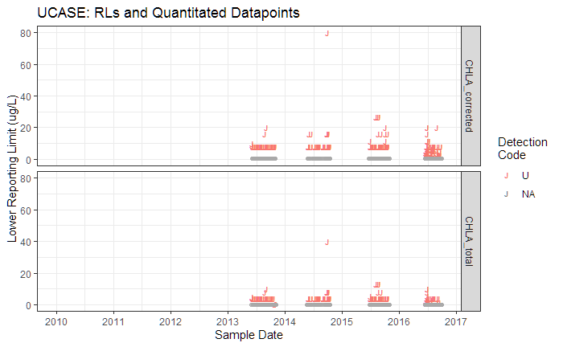

```r
CHL1016_07 %>% filter(PROJ_grp == "UCASE" & MATRIX.X == "WC") %>%
  filter(!is.na(Filt.Vol)) %>%
  filter(PARAM.X != "PHEO" & MethodID2 != "10300") %>%
  mutate(PARAM.X = recode(.$PARAM.X,
                          "CHLA.X" = "CHLA_total",
                          "CHLA.tot" = "CHLA_total",
                          "CHLA.aa" = "CHLA_corrected")) %>%
  distinct(SKey2, PARAM.X, Non_Detect, .keep_all = T) %>%
  ggplot(., na.rm=T) + theme_bw() +
  facet_grid(PARAM.X ~ .,  scales = "fixed") +
  geom_text(aes(x=x_SDate, y=LRL_c, col=Non_Detect),
            na.rm=T, size=2.5, fontface="bold", label="J") +
  geom_point(data=.data[[is.na(.data[["Non_Detect"]]),]], aes(y=0.25, x=.data[["x_SDate"]]),
             position = position_jitter(width=10, height=0), col="darkgray", size=1.5,
             alpha=0.75, na.rm=T) +
  scale_x_date(date_labels="%Y",date_breaks = "1 year",
               limits=c(as.Date("2010-01-01"), NA)) +
  scale_y_continuous(limits=c(0, NA)) +
  labs(x="Sample Date", y="Lower Reporting Limit (ug/L)", col="Detection \nCode",
       title="UCASE: RLs and Quantitated Datapoints")
```

- Water-Column sampling for UCASE appears to have started in 2013
- Many, if not most of the Non-Detects after 2012 should be reviewed
- UCASE Summary of proportion of Non-Detects in Results
  - *Ignoring records where filtration volume could not be obtained*

```r
CHL1016_07 %>% filter(PROJ_grp == "UCASE" & MATRIX.X == "WC") %>%
  filter(!is.na(Filt.Vol)) %>%
  filter(PARAM.X != "PHEO") %>%
  mutate(PARAM.X = recode(.$PARAM.X,
                          "CHLA.X" = "CHLA_total",
                          "CHLA.tot" = "CHLA_total",
                          "CHLA.aa" = "CHLA_corrected")) %>%
  group_by(lubridate::year(x_SDate), PARAM.X) %>%
  summarize(p_ND = sprintf("%.f%%",
                           (sum(!is.na(Non_Detect), na.rm=T) / n())*100)) %>%
  as.data.frame(.) %>%
  setNames(c("Year", "CHL_param", "p_NonDetects")) %>%
  bind_rows(.,
            CHL1016_07 %>% filter(PROJ_grp == "UCASE" & MATRIX.X == "WC") %>%
              filter(!is.na(Filt.Vol)) %>%
              filter(PARAM.X != "PHEO") %>%
              group_by(lubridate::year(x_SDate)) %>%
              summarize(obs = n()) %>% data.frame(., CHL_param="Obs") %>%
              setNames(c("Year", "p_NonDetects", "CHL_param")) %>%
              mutate(p_NonDetects=as.character(p_NonDetects))
            ) %>%
  spread(Year, p_NonDetects) %>%
  htmlTable::htmlTable(., css.cell = rbind(rep("padding-left: 0.8em; padding-right: 0.8em;font-size: 0.75em;", times=ncol(.)+1), matrix("padding-left: 0.8em; padding-right: 0.8em; font-size: 0.75em;", ncol=ncol(.)+1, nrow=nrow(.))), align="r|l|ccccccc|", caption="UCASE: Proportion of records (SK2) where result is Non-Detect", total=T)
```

| UCASE: Proportion of records (SK2) where result is Non-Detect | UCASE: Proportion of records (SK2) where result is Non-Detect CHL_param | UCASE: Proportion of records (SK2) where result is Non-Detect 2013 | UCASE: Proportion of records (SK2) where result is Non-Detect 2014 | UCASE: Proportion of records (SK2) where result is Non-Detect 2015 | UCASE: Proportion of records (SK2) where result is Non-Detect 2016 |
| --- | --- | --- | --- | --- | --- |
| 1 | CHLA_corrected | 86% | 98% | 86% | 76% |
| 2 | CHLA_total | 78% | 88% | 61% | 34% |
| 3 | Obs | 118 | 98 | 138 | 218 |

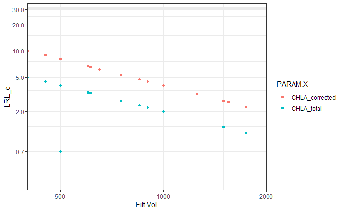

```r
CHL1016_07 %>% filter(PROJ_grp == "UCASE" & MATRIX.X == "WC") %>%
  filter(!is.na(Filt.Vol)) %>%
  filter(PARAM.X != "PHEO") %>%
  mutate(PARAM.X = recode(.$PARAM.X,
                          "CHLA.X" = "CHLA_total",
                          "CHLA.tot" = "CHLA_total",
                          "CHLA.aa" = "CHLA_corrected")) %>%
  ggplot(.) + theme_bw() +
  geom_point(aes(x=Filt.Vol, y=LRL_c, col=PARAM.X), na.rm=T) +
  # geom_point(aes(x=Filt.Vol, y=x_RVal.conc, col=PARAM.X), na.rm=T,
  #            position=position_jitter(width=10, height=0), shape=5, alpha=0.7) +
  coord_trans(x="log10", y="log10", limy=c(0.25, 35), limx=c(400, 2000)) +
  scale_x_continuous(breaks=c(500, 1000, 2000, 3000, 4000)) +
  scale_y_continuous(breaks=c(0.7, 2, 5, 10, 20, 30))
```

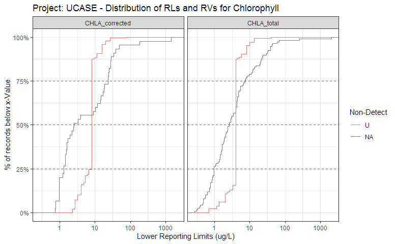

```r
CHL1016_07 %>% filter(PROJ_grp == "UCASE" & MATRIX.X == "WC") %>%
  filter(!is.na(Filt.Vol)) %>%
  filter(PARAM.X != "PHEO") %>%
  mutate(PARAM.X = recode(.$PARAM.X,
                          "CHLA.X" = "CHLA_total",
                          "CHLA.tot" = "CHLA_total",
                          "CHLA.aa" = "CHLA_corrected")) %>%
  mutate(Result_val = case_when(
    is.na(Non_Detect) &
      !is.na(x_RVal.conc) ~ x_RVal.conc,
    !is.na(Non_Detect) & Non_Detect == "U" &
      !is.na(LRL_c) ~ LRL_c,
    TRUE ~ as.numeric(NA))) %>%
  ggplot(.) + theme_bw() + facet_grid(. ~ PARAM.X, scales="fixed") +
  stat_ecdf(aes(x=Result_val, col=Non_Detect), na.rm=T, lty=1) +
  labs(x="Lower Reporting Limits (ug/L)", y="% of records below x-Value",
       col="Non-Detect") +
  scale_x_continuous(trans="log10") +
  scale_y_continuous(labels=scales::percent) +
  geom_hline(yintercept = c(0.25,0.5,0.75), lty=2, color="gray40") +
  ggtitle("Project: UCASE - Distribution of RLs and RVs for Chlorophyll")
```

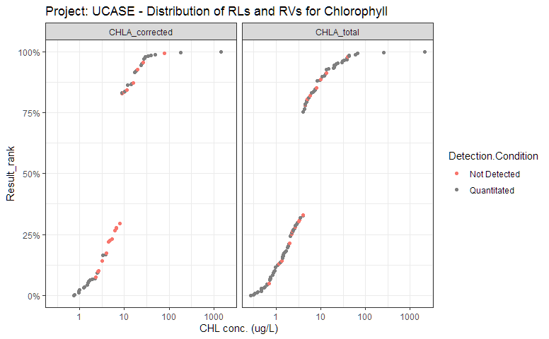

```r
CHL1016_07 %>% filter(PROJ_grp == "UCASE" & MATRIX.X == "WC") %>%
  filter(!is.na(Filt.Vol)) %>%
  filter(PARAM.X != "PHEO") %>%
  mutate(PARAM.X = recode(.$PARAM.X,
                          "CHLA.X" = "CHLA_total",
                          "CHLA.tot" = "CHLA_total",
                          "CHLA.aa" = "CHLA_corrected")) %>%
  mutate(Result_val = case_when(
    is.na(Non_Detect) &
      !is.na(x_RVal.conc) ~ x_RVal.conc,
    !is.na(Non_Detect) & Non_Detect == "U" &
      !is.na(LRL_c) ~ LRL_c,
    TRUE ~ as.numeric(NA))) %>%
  arrange(PARAM.X, Result_val) %>% group_by(PARAM.X) %>%
  mutate(RValue_rank = percent_rank(Result_val)) %>%
  ggplot(.) + theme_bw() + facet_grid(. ~ PARAM.X, scales="fixed") +
  geom_point(aes(x=Result_val, y=RValue_rank, col=Non_Detect), na.rm=T) +
  # EnvStats::stat_n_text() +
  labs(x="CHL conc. (ug/L)", y="Result_rank") +
  scale_x_continuous(trans="log10") +
  scale_y_continuous(labels = scales::percent) +
  ggtitle("Project: UCASE - Distribution of RLs and RVs for Chlorophyll") +
  scale_color_discrete(name="Detection.Condition", labels=c("Not Detected", "Quantitated"))
```

```r
  #(rank(Result_val,na.last=NA))
```

### Bottom Line: REVW-Non-Detects (-blanks)

### Also: REVW-PERI-calcs

## [11] USFS (*aka NFS*)

- Number of unique sites in set :: 17
- Record data-range :: 2010-08-16 to 2010-11-05
- Unique Sample Events :: 47
- Methods :: 10200
- Params :: CHLA.X

### Filt.Vol completeness

```r
CHL1016_07 %>%
  filter(PROJ_grp == "USFS") %>%
  filter(PARAM.X != "PHEO") %>%
  {addmargins(table(.$RECORD_STATUS, .$import_status,
                                 useNA="ifany", deparse.level = 2))}
```

```
               .$import_status
.$RECORD_STATUS To_import Sum
     REVIEW_VOL        47  47
     Sum               47  47
```

- Missing Filtration Volumes

|  | Have_filtration_vol FALSE |  | Sum |
| --- | --- | --- | --- |
| CHL_param |  |  |  |
| CHLA.X | 47 |  | 47 |
| Sum | 47 |  | 47 |

- Unique levels of SKey2 where Filtration Volumes are missing
  - See table above, 47 records
- Unique MLIDs where Filtration Volumes are missing

|  | 2010 | Sum |
| --- | --- | --- |
| 4954850 | 1 | 1 |
| 4954851 | 1 | 1 |
| 4954853 | 4 | 4 |
| 4954855 | 4 | 4 |
| 4954856 | 4 | 4 |
| 4954857 | 4 | 4 |
| 4954860 | 4 | 4 |
| 4954862 | 4 | 4 |
| 4954864 | 3 | 3 |
| 4954866 | 4 | 4 |
| 4954868 | 4 | 4 |
| 4954870 | 4 | 4 |
| 5955880 | 2 | 2 |
| 5955890 | 1 | 1 |
| 5955950 | 1 | 1 |
| 5956100 | 1 | 1 |
| 5956110 | 1 | 1 |
| Sum | 47 | 47 |

> All samples from 2010 - No vols needed
- Correct RECORD_STATUS for `USFS`

```r
CHL1016_07 %<>% mutate(
  RECORD_STATUS =case_when(
    PROJ_grp == "USFS" &
      RECORD_STATUS == "REVIEW_VOL" &
      x_SDate < as.Date("2013-01-01") ~ as.character(NA),
    !is.na(RECORD_STATUS) ~ RECORD_STATUS,
    TRUE ~ as.character(NA))
)
```

### Project Non-Detects

- Proportion of Records w/ Non-Detect flags
  - Can ignore the filtration-volume field for this project-group

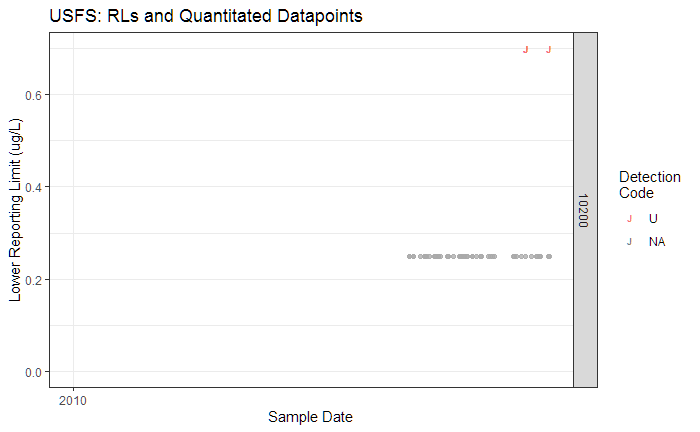

```r
CHL1016_07 %>% filter(PROJ_grp == "USFS") %>%
  filter(!PARAM.X %in% c("PHEO", "CHLB")) %>%
  mutate(PARAM.X = recode(.$PARAM.X,
                          "CHLA.X" = "CHLA_total",
                          "CHLA.tot" = "CHLA_total",
                          "CHLA.aa" = "CHLA_corrected")) %>%
  distinct(SKey2, PARAM.X, .keep_all = T) %>%
  ggplot(., na.rm=T) + theme_bw() +
  facet_grid(MethodID2 ~ .,  scales = "fixed") +
  geom_text(aes(x=x_SDate, y=LRL_c, col=Non_Detect),
            na.rm=T, size=2.5, fontface="bold", label="J") +
  geom_point(data=.data[[is.na(.data[["Non_Detect"]]),]], aes(y=0.25, x=.data[["x_SDate"]]),
             position = position_jitter(width=10, height=0), col="darkgray", size=1.5,
             alpha=0.75, na.rm=T) +
  scale_x_date(date_labels="%Y",date_breaks = "1 year",
               limits=c(as.Date("2010-01-01"), NA)) +
  scale_y_continuous(limits=c(0, NA)) +
  labs(x="Sample Date", y="Lower Reporting Limit (ug/L)", col="Detection \nCode",
       title="USFS: RLs and Quantitated Datapoints")
```

- Records are older, v. few Non-Detects

```r
CHL1016_07 %>% filter(PROJ_grp == "USFS") %>%
  filter(!PARAM.X %in% c("PHEO", "CHLB")) %>%
  mutate(PARAM.X = recode(.$PARAM.X,
                          "CHLA.X" = "CHLA_total",
                          "CHLA.tot" = "CHLA_total",
                          "CHLA.aa" = "CHLA_corrected")) %>%
  distinct(SKey2, PARAM.X, .keep_all = T) %>%
  group_by(lubridate::year(x_SDate), PARAM.X) %>%
  summarize(p_ND = sprintf("%.f%%",
                           (sum(!is.na(Non_Detect), na.rm=T) / n())*100)) %>%
  as.data.frame(.) %>%
  setNames(c("Year", "CHL_param", "p_NonDetects")) %>%
  spread(Year, p_NonDetects) %>%
  htmlTable::htmlTable(., css.cell = rbind(rep("padding-left: 0.8em; padding-right: 0.8em;font-size: 0.75em;", times=ncol(.)+1), matrix("padding-left: 0.8em; padding-right: 0.8em; font-size: 0.75em;", ncol=ncol(.)+1, nrow=nrow(.))))
```

|  | CHL_param | 2010 |
| --- | --- | --- |
| 1 | CHLA_total | 13% |

### Bottom Line: OK

> USFS project is sufficiently complete (volumes) and sensitive (%RLs); on additional action needed. All Records from 2010

## [12] Utah Lake

- Number of unique sites in set :: 13
- Record data-range :: 2011-10-12 to 2016-09-13
- Unique Sample Events :: 23
- Methods :: 10200
- Params :: CHLA.aa, CHLA.tot, PHEO, CHLA.X

### Filt.Vol completeness

```r
CHL1016_07 %>%
  filter(PROJ_grp == "UtahLK") %>%
  filter(PARAM.X != "PHEO") %>%
  {addmargins(table(.$RECORD_STATUS, .$import_status,
                                 useNA="ifany", deparse.level = 2))}
```

```
               .$import_status
.$RECORD_STATUS To_import utlk_01 Sum
     REVIEW_VOL         6       1   7
     <NA>              13      17  30
     Sum               19      18  37
```

- Missing Filtration Volumes

|  | Have_filtration_vol FALSE | Have_filtration_vol TRUE |  | Sum |
| --- | --- | --- | --- | --- |
| CHL_param |  |  |  |  |
| CHLA.aa | 0 | 5 |  | 5 |
| CHLA.tot | 0 | 5 |  | 5 |
| CHLA.X | 1 | 26 |  | 27 |
| Sum | 1 | 36 |  | 37 |

- Unique levels of SKey2 where Filtration Volumes are missing
  - See table above, 1 records
- Unique MLIDs where Filtration Volumes are missing

|  | 2012 | Sum |
| --- | --- | --- |
| 4917770 | 1 | 1 |
| Sum | 1 | 1 |

**Look for UTLK filtration volumes from 2016** [*2012 vols not needed*]

- Found 3 sets for 2016 :: 9/13/16
  - 4907365 = 110 mL
  - 4917390 = 150
  - 4917715 = 125 mL
- Update Volumes

```r
CHL1016_07 %<>% mutate(
  Comment_X = case_when(
    PROJ_grp == "UtahLK" & RECORD_STATUS == "REVIEW_VOL" &
      is.na(Filt.Vol) & SKey2 %in% c("4907365.42626.2020494",
                                     "4917390.42626.2020495",
                                     "4917715.42626.2020496") &
      is.na(Comment_X) ~ "FiltVol added",
    PROJ_grp == "UtahLK" & RECORD_STATUS == "REVIEW_VOL" &
      is.na(Filt.Vol) & SKey2 %in% c("4907365.42626.2020494",
                                     "4917390.42626.2020495",
                                     "4917715.42626.2020496") &
      !is.na(Comment_X) ~ paste(.$Comment_X,
                                "FiltVol added", sep=";"),
    !is.na(Comment_X) ~ Comment_X,
    TRUE ~ as.character(NA)),
  Filt.Vol = case_when(
    PROJ_grp == "UtahLK" & RECORD_STATUS == "REVIEW_VOL" &
      is.na(Filt.Vol) &
      SKey2 == "4907365.42626.2020494" ~ 110,
    PROJ_grp == "UtahLK" & RECORD_STATUS == "REVIEW_VOL" &
      is.na(Filt.Vol) &
      SKey2 == "4917390.42626.2020495" ~ 150,
    PROJ_grp == "UtahLK" & RECORD_STATUS == "REVIEW_VOL" &
      is.na(Filt.Vol) &
      SKey2 == "4917715.42626.2020496" ~ 125,
    !is.na(Filt.Vol) ~ Filt.Vol,
    TRUE ~ as.numeric(NA))) %>%
  mutate(
    RECORD_STATUS = case_when(
      PROJ_grp == "UtahLK" & RECORD_STATUS == "REVIEW_VOL" &
        !is.na(Filt.Vol) ~ as.character(NA),
      !is.na(RECORD_STATUS) ~ RECORD_STATUS,
      TRUE ~ as.character(NA))
  )
```

### Project Non-Detects

- Proportion of Records w/ Non-Detect flags

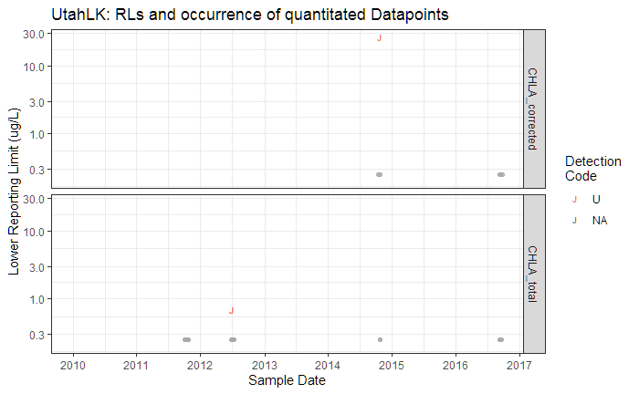

```r
CHL1016_07 %>% filter(PROJ_grp == "UtahLK") %>%
  filter(!is.na(Filt.Vol)) %>%
  filter(PARAM.X != "PHEO") %>%
  mutate(PARAM.X = recode(.$PARAM.X,
                          "CHLA.X" = "CHLA_total",
                          "CHLA.tot" = "CHLA_total",
                          "CHLA.aa" = "CHLA_corrected")) %>%
  distinct(SKey2, PARAM.X, Non_Detect, .keep_all = T) %>%
  ggplot(., na.rm=T) + theme_bw() +
  facet_grid(PARAM.X ~ .,  scales = "fixed") +
  geom_text(aes(x=x_SDate, y=LRL_c, col=Non_Detect),
            na.rm=T, size=2.5, fontface="bold", label="J") +
  geom_point(data=.data[[is.na(.data[["Non_Detect"]]),]], aes(y=0.25, x=.data[["x_SDate"]]),
             position = position_jitter(width=10, height=0), col="darkgray", size=1.5,
             alpha=0.75, na.rm=T) +
  scale_x_date(date_labels="%Y",date_breaks = "1 year",
               limits=c(as.Date("2010-01-01"), NA)) +
  scale_y_continuous(limits=c(0.2, NA), trans="log10") +
  labs(x="Sample Date", y="Lower Reporting Limit (ug/L)", col="Detection \nCode",
       title="UtahLK: RLs and occurrence of quantitated Datapoints")
```

- Due to small sample filtration volumes, some RLs are high

**Nearly complete overlap of quantitated results and RLs**

- Proportion of Records w/ Non-Detect flags
  - *Ignoring records where filtration volume is unavailable*

```r
CHL1016_07 %>% filter(PROJ_grp == "UtahLK") %>%
  filter(!is.na(Filt.Vol)) %>%
  filter(PARAM.X != "PHEO") %>%
  mutate(PARAM.X = recode(.$PARAM.X,
                          "CHLA.X" = "CHLA_total",
                          "CHLA.tot" = "CHLA_total",
                          "CHLA.aa" = "CHLA_corrected")) %>%
  group_by(lubridate::year(x_SDate), PARAM.X) %>%
  summarize(p_ND = sprintf("%.f%%",
                           (sum(!is.na(Non_Detect), na.rm=T) / n())*100)) %>%
  as.data.frame(.) %>%
  setNames(c("Year", "CHL_param", "p_NonDetects")) %>%
  bind_rows(.,
            CHL1016_07 %>% filter(PROJ_grp == "UtahLK") %>%
              filter(!is.na(Filt.Vol)) %>%
              filter(PARAM.X != "PHEO") %>%
              group_by(lubridate::year(x_SDate)) %>%
              summarize(obs = n()) %>% data.frame(., CHL_param="Obs") %>%
              setNames(c("Year", "p_NonDetects", "CHL_param")) %>%
              mutate(p_NonDetects=as.character(p_NonDetects))
            ) %>%
  spread(Year, p_NonDetects) %>%
  htmlTable::htmlTable(., css.cell = rbind(rep("padding-left: 0.8em; padding-right: 0.8em;font-size: 0.75em;", times=ncol(.)+1), matrix("padding-left: 0.8em; padding-right: 0.8em; font-size: 0.75em;", ncol=ncol(.)+1, nrow=nrow(.))), align="r|l|cc|", caption="UtahLK: Proportion of records (SK2) where result is Non-Detect", total=T)
```

| UtahLK: Proportion of records (SK2) where result is Non-Detect | UtahLK: Proportion of records (SK2) where result is Non-Detect CHL_param | UtahLK: Proportion of records (SK2) where result is Non-Detect 2011 | UtahLK: Proportion of records (SK2) where result is Non-Detect 2012 | UtahLK: Proportion of records (SK2) where result is Non-Detect 2014 | UtahLK: Proportion of records (SK2) where result is Non-Detect 2016 |
| --- | --- | --- | --- | --- | --- |
| 1 | CHLA_corrected |  |  | 50% | 0% |
| 2 | CHLA_total | 0% | 25% | 0% | 0% |
| 3 | Obs | 18 | 8 | 4 | 6 |

No obvious isses w/ Non-detects here

### Bottom Line: OK

## [13] WINTERLAKES

- Number of unique sites in set :: 18
- Record data-range :: 2010-02-02 to 2012-02-28
- Unique Sample Events :: 26
- Methods :: 10200
- Params :: CHLA.X

### Filt.Vol completeness

```r
CHL1016_07 %>%
  filter(PROJ_grp == "WINTERLAKES") %>%
  filter(PARAM.X != "PHEO") %>%
  {addmargins(table(.$RECORD_STATUS, .$import_status,
                                 useNA="ifany", deparse.level = 2))}
```

```
               .$import_status
.$RECORD_STATUS To_import Sum
     REVIEW_VOL         9   9
     <NA>              19  19
     Sum               28  28
```

- Missing Filtration Volumes

|  | Have_filtration_vol FALSE | Have_filtration_vol TRUE |  | Sum |
| --- | --- | --- | --- | --- |
| CHL_param |  |  |  |  |
| CHLA.X | 9 | 19 |  | 28 |
| Sum | 9 | 19 |  | 28 |

- Unique levels of SKey2 where Filtration Volumes are missing
  - See table above, 9 records
- Unique MLIDs where Filtration Volumes are missing

|  | 2010 | 2011 | Sum |
| --- | --- | --- | --- |
| 4926130 | 0 | 1 | 1 |
| 4926140 | 0 | 1 | 1 |
| 4937130 | 0 | 2 | 2 |
| 4937180 | 1 | 0 | 1 |
| 4937550 | 1 | 0 | 1 |
| 5923310 | 1 | 1 | 2 |
| 5923320 | 0 | 1 | 1 |
| Sum | 3 | 6 | 9 |

> Older records, prior to 2012; No Volumes needed

### Project Non-Detects

- Proportion of Records w/ Non-Detect flags

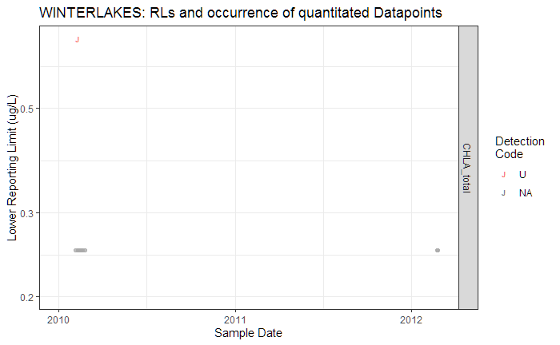

```r
CHL1016_07 %>% filter(PROJ_grp == "WINTERLAKES") %>%
  filter(!is.na(Filt.Vol)) %>%
  filter(PARAM.X != "PHEO") %>%
  mutate(PARAM.X = recode(.$PARAM.X,
                          "CHLA.X" = "CHLA_total",
                          "CHLA.tot" = "CHLA_total",
                          "CHLA.aa" = "CHLA_corrected")) %>%
  distinct(SKey2, PARAM.X, Non_Detect, .keep_all = T) %>%
  ggplot(., na.rm=T) + theme_bw() +
  facet_grid(PARAM.X ~ .,  scales = "fixed") +
  geom_text(aes(x=x_SDate, y=LRL_c, col=Non_Detect),
            na.rm=T, size=2.5, fontface="bold", label="J") +
  geom_point(data=.data[[is.na(.data[["Non_Detect"]]),]], aes(y=0.25, x=.data[["x_SDate"]]),
             position = position_jitter(width=10, height=0), col="darkgray", size=1.5,
             alpha=0.75, na.rm=T) +
  scale_x_date(date_labels="%Y",date_breaks = "1 year",
               limits=c(as.Date("2010-01-01"), NA)) +
  scale_y_continuous(limits=c(0.2, NA), trans="log10") +
  labs(x="Sample Date", y="Lower Reporting Limit (ug/L)", col="Detection \nCode",
       title="WINTERLAKES: RLs and occurrence of quantitated Datapoints")
```

Only 1 ND value, in 2010

### Bottom Line: OK

## [14] WRI

- Number of unique sites in set :: 45
- Record data-range :: 2016-05-16 to 2016-09-21
- Unique Sample Events :: 240
- Methods :: 10200

### Filt.Vol completeness

```r
CHL1016_07 %>%
  filter(PROJ_grp == "WRI") %>%
  filter(PARAM.X != "PHEO") %>% distinct(SKey2, .keep_all=T) %>%
  {addmargins(table(.$RECORD_STATUS, .$import_status,
                                 useNA="ifany", deparse.level = 2))}
```

```
                       .$import_status
.$RECORD_STATUS         To_import Sum
  REVIEW_lrl;REVIEW_VOL         2   2
  REVIEW_mdl;REVIEW_VOL        68  68
  REVIEW_VOL                  170 170
  Sum                         240 240
```

- Missing Filtration Volumes

|  | Have_filtration_vol FALSE | Have_filtration_vol TRUE |  | Sum |
| --- | --- | --- | --- | --- |
| CHL_param |  |  |  |  |
| CHLA.aa | 96 | 144 |  | 240 |
| CHLA.tot | 96 | 144 |  | 240 |
| Sum | 192 | 288 |  | 480 |

### Import available CHL-vols

```r
# file.wriVOL  <- choose.files(caption="Select _working_ DATA file [*.xlsx]", multi = FALSE)
# wri_vols <- openxlsx::read.xlsx(file.wriVOL, sheet="CHL_vols", startRow = 1,
#                               rowNames=FALSE, check.names = T)
# rm(wri_vols)
```

- Filename :: 2016_Q3Q4_WRI_Field_Combined_thru_091216_BB_tdh190911.xlsx
- Path :: U:/PERMITS/MONITORS/2016_Data/2016_Hydrodata/2016_Combined Hydrodata/QC_Done/Files moved to AWQMS Import-DO NOT MODIFY
- Last Accessed :: [2019-09-13 17:09:52]
- DF [`wri_vols`] :: 550 records and 6 fields

```r
wri_vols_01 <- wri_vols %>% filter(!is.na(VOL)) %>%
  setNames(c("TripID", "MLID", "Date", "SType", "CHL_type", "VOL")) %>%
  mutate(Date = as.Date(.$Date, origin="1899-12-30"))
```

- Join found vols to DF
  - also remove prior found_Vols field, then re-add it in…

```r
# CHL1016_07 -> CHL1016_07_copy
CHL1016_07 <- CHL1016_07 %>%
  select(-VOL_found_mL) %>%
  left_join(.,
            wri_vols_01 %>%
              select(.,
                     MLID, Date, VOL) %>% mutate(MLID = as.character(MLID)),
            by = c("x_MLID" = "MLID",
                   "x_SDate" = "Date")) %>%
  select(RECORD_STATUS:Filt.Vol, VOL_found_mL = VOL, everything())  %>%
  mutate_if(is.factor, as.character)
```

- check VOL completeness

```r
CHL1016_07 %>%
  filter(PROJ_grp == "WRI") %>%
  filter(PARAM.X != "PHEO") %>% distinct(SKey2, .keep_all=T) %>%
  {addmargins(table(.$RECORD_STATUS, is.na(.$VOL_found_mL),
                                 useNA="ifany", deparse.level = 2,
                    dnn=c("RECORD_status", "VOL_missing?")))}
```

```
                       VOL_missing?
RECORD_status           FALSE TRUE Sum
  REVIEW_lrl;REVIEW_VOL     1    1   2
  REVIEW_mdl;REVIEW_VOL    33   35  68
  REVIEW_VOL              110   60 170
  Sum                     144   96 240
```

- Translate found_VOLs to `Filt.Vol` for WRI records and recode `RECORD_STATUS`

```r
CHL1016_07 %<>% mutate(
  Filt.Vol = case_when(
    PROJ_grp == "WRI" & grepl("REVIEW_VOL", .$RECORD_STATUS, ignore.case = T) &
      is.na(Filt.Vol) & !is.na(VOL_found_mL) ~ VOL_found_mL,
    !is.na(Filt.Vol) ~ Filt.Vol,
    TRUE ~ as.numeric(NA))) %>%
  mutate(
    RECORD_STATUS = case_when(
      PROJ_grp == "WRI" & !is.na(Filt.Vol) &
        RECORD_STATUS == "REVIEW_VOL" ~ as.character(NA),
      PROJ_grp == "WRI" & !is.na(Filt.Vol) &
        grepl("REVIEW_VOL", .$RECORD_STATUS, ignore.case = T) ~
        gsub(";REVIEW_VOL", "", .$RECORD_STATUS, ignore.case = T),
      !is.na(RECORD_STATUS) ~ RECORD_STATUS,
      TRUE ~ as.character(NA))) %>%
  select(RECORD_STATUS:x_SDate, Sample.Type, everything())
```

- Take a look at VOL completeness for WRI by month (year == 2016)
  - Unique levels of SKey2 for WRI :: 240

```r
CHL1016_07 %>% filter(PROJ_grp == "WRI") %>%
  distinct(SKey2, .keep_all=T) %>%
  {addmargins(table(lubridate::month(.$x_SDate), is.na(.$Filt.Vol),
                    useNA="ifany", deparse.level = 2,
                    dnn=c("Sample_month", "Filt.Vol_missing?")))}
```

```
            Filt.Vol_missing?
Sample_month FALSE TRUE Sum
         5      23   26  49
         6      26   23  49
         7      41    7  48
         8      40    6  46
         9      14   34  48
         Sum   144   96 240
```

[above]

- Some vols may be missing in May, June and Sept ??

```r
CHL1016_07 %>% filter(PROJ_grp == "WRI" & is.na(Filt.Vol)) %>%
  distinct(Sample.Type) %$% Sample.Type
```

```
[1] "4"
```

Sample types are okay, will need further review, since I have CHL results but no VOLs

- [190911] **Found some records where VOL is missing from CHL-DF, but a value is present in `wri_vols_01`, so something w/ the JOIN is hinkey…**

**Summarise status of found WRI vols**

```r
wri_vols_01 %<>% mutate(
  Found = case_when(
    paste(.$MLID, .$Date, sep="_") %in%
      paste(CHL1016_07$x_MLID,
            CHL1016_07$x_SDate, sep="_") ~ "Y",
    TRUE ~ "n"
  ))
#
wri_vols_01 %>% filter(Found == "n") %>% {addmargins(table(paste(.$MLID, .$Date, sep="_"),
                                  .$Found, useNA = "ifany", deparse.level = 2,
                                  dnn=c("MLID_date", "Site_Date_matchup?")),1)} %>%
  htmlTable::htmlTable(., css.cell = rbind(rep("padding-left: 0.8em; padding-right: 0.8em;font-size: 0.75em;", times=ncol(.)+1), matrix("padding-left: 0.8em; padding-right: 0.8em; font-size: 0.75em;", ncol=ncol(.)+1, nrow=nrow(.))))
```

|  | Site_Date_matchup? n |
| --- | --- |
| MLID_date |  |
| 4900280_2016-09-19 | 1 |
| 4920010_2016-09-19 | 1 |
| 4926400_2016-06-14 | 1 |
| 4926400_2016-09-14 | 1 |
| 4929200_2016-07-12 | 1 |
| 4994760_2016-09-20 | 1 |
| Sum | 6 |

- ID WRI records (SKey2) where Filt.Vol is *still missing*

```r
CHL1016_07 %>% filter(PROJ_grp == "WRI" &
                        (is.na(Filt.Vol) | is.na(VOL_found_mL))) %>%
  distinct(SKey2, .keep_all=T) %>%
  {addmargins(table(paste(.$x_MLID, .$x_SDate, sep="_"),
                    .$QC_type,
                    useNA = "ifany",
                    deparse.level = 2, dnn=c("mlid_date", "QC_type")))} %>%
  as.data.frame(.) %>% spread(QC_type, Freq) %>%
  select(-Sum) %>% mutate_if(is.factor, as.character) %>%
  filter(mlid_date != "Sum") -> wri_noVOL
```

**Looks like there may be date / MLID mis-matches b/w field and CHL datasets for WRI**

- add YR_month to these tables as a sloppy-match

```r
wri_vols_01 %<>% mutate(
  yr_mon = paste(lubridate::year(.$Date),
                 sprintf("%.2d", lubridate::month(.$Date)), sep="_")
)
```

```r
wri_noVOL %<>% mutate(
  yr_mon = paste(
    lubridate::year(stringr::str_extract(.$mlid_date,
                                         pattern = "[0-9]{4}-[0-9]{2}-[0-9]{2}")),
    sprintf("%.2d", lubridate::month(stringr::str_extract(.$mlid_date,
                                         pattern = "[0-9]{4}-[0-9]{2}-[0-9]{2}"))),
    sep="_"),
  MLID = stringr::str_extract(.$mlid_date,
                              pattern = "[0-9]{7}")) %>% arrange(yr_mon, MLID)

# grep("[0-9]{4}-[0-9]{2}-[0-9]{2}", wri_noVOL$mlid_date,value = T)
# strsplit(wri_noVOL$mlid_date,"_",fixed=T)[1]
# stringr::str_split(wri_noVOL$mlid_date[1], "_")[[1]][2]
# stringr::str_extract(wri_noVOL$mlid_date,pattern = "[0-9]{4}-[0-9]{2}-[0-9]{2}")
# stringr::str_extract(wri_noVOL$mlid_date,pattern = "[0-9]{7}")
# strsplit(wri_noVOL$mlid_date,"_")[[1]][1]
```

- matchup again, using only _noVOL table…

```r
wri_noVOL %<>% mutate(
  fnd_vols = case_when(
    paste(.$MLID, .$yr_mon, sep=".") %in%
      paste(wri_vols_01$MLID,
            wri_vols_01$yr_mon, sep=".") ~ "Y",
    TRUE ~ "n"
  )
)
```

- add found vols to wri_noVOL

```r
wri_noVOL_2 <- left_join(wri_noVOL %>%
                           mutate(sk1 = paste(.$MLID, .$yr_mon, sep=".")),
                         wri_vols_01 %>%
                           mutate(sk1 = paste(.$MLID, .$yr_mon, sep=".")) %>%
                           select(sk1, VOL),
                         by = c("sk1" = "sk1"))
```

- Noqw use `mlid_date` from `wri_noVOL` to join to dataset for found VOLs
  - **These have a slight date mismatch**

```r
CHL1016_08 <- left_join(
  CHL1016_07 %>% mutate(mlid_date = paste(.$x_MLID, .$x_SDate, sep="_")),
  wri_noVOL_2 %>% select(mlid_date, VOL),
  by = c("mlid_date" = "mlid_date")) %>%
  select(-VOL_found_mL) %>%
  select(RECORD_STATUS:Filt.Vol, VOL_found_mL = VOL,
         everything())
```

- Now combine Vol-fields again…

```r
CHL1016_08 %<>% mutate(
  Filt.Vol = case_when(
    PROJ_grp == "WRI" & grepl("REVIEW_VOL", .$RECORD_STATUS, ignore.case = T) &
      is.na(Filt.Vol) & !is.na(VOL_found_mL) ~ VOL_found_mL,
    !is.na(Filt.Vol) ~ Filt.Vol,
    TRUE ~ as.numeric(NA))) %>%
  mutate(
    RECORD_STATUS = case_when(
      PROJ_grp == "WRI" & !is.na(Filt.Vol) &
        RECORD_STATUS == "REVIEW_VOL" ~ as.character(NA),
      PROJ_grp == "WRI" & !is.na(Filt.Vol) &
        grepl("REVIEW_VOL", .$RECORD_STATUS, ignore.case = T) ~
        gsub(";REVIEW_VOL", "", .$RECORD_STATUS, ignore.case = T),
      !is.na(RECORD_STATUS) ~ RECORD_STATUS,
      TRUE ~ as.character(NA))) %>%
  select(-VOL_found_mL)
```

- Counds look okay for now…
- Take another look at records missing VOLs (after 2 tries…)

```r
CHL1016_08 %>% filter(PROJ_grp == "WRI" & is.na(Filt.Vol)) %>%
  distinct(SKey2, .keep_all=T) %>%
  {addmargins(table(paste(.$x_MLID, .$x_SDate, sep="_"),
                    .$QC_type,
                    useNA = "ifany",
                    deparse.level = 2, dnn=c("mlid_date", "QC_type")))} %>%
  as.data.frame(.) %>% spread(QC_type, Freq) %>%
  select(-Sum) %>% mutate_if(is.factor, as.character) %>%
  filter(mlid_date != "Sum") -> wri_noVOL_3
```

```r
wri_noVOL_3 %<>% mutate(
  yr_mon = paste(
    lubridate::year(stringr::str_extract(.$mlid_date,
                                         pattern = "[0-9]{4}-[0-9]{2}-[0-9]{2}")),
    sprintf("%.2d", lubridate::month(stringr::str_extract(.$mlid_date,
                                         pattern = "[0-9]{4}-[0-9]{2}-[0-9]{2}"))),
    sep="_"),
  MLID = stringr::str_extract(.$mlid_date,
                              pattern = "[0-9]{7}")) %>% arrange(yr_mon, MLID)
```

- Check for MLID in wri-vols

```r
wri_noVOL_3 %<>% mutate(
  f_mlid = case_when(
    MLID %in% wri_vols_01$MLID ~ "Y",
    TRUE ~ "n"))
```

```r
wri_noVOL_3 %>% {addmargins(table(.$MLID, .$f_mlid=="Y", useNA="ifany",
                                  deparse.level = 2, dnn=c("MLID", "MLID_in_vols?")))} %>%
  htmlTable::htmlTable(., css.cell = rbind(rep("padding-left: 0.8em; padding-right: 0.8em;font-size: 0.75em;", times=ncol(.)+1), matrix("padding-left: 0.8em; padding-right: 0.8em; font-size: 0.75em;", ncol=ncol(.)+1, nrow=nrow(.))))
```

|  | MLID_in_vols? FALSE | MLID_in_vols? TRUE |  | Sum |
| --- | --- | --- | --- | --- |
| MLID |  |  |  |  |
| 4920097 | 15 | 0 |  | 15 |
| 4920098 | 14 | 0 |  | 14 |
| 4924760 | 0 | 1 |  | 1 |
| 4925350 | 0 | 1 |  | 1 |
| 4925360 | 0 | 1 |  | 1 |
| 4925440 | 0 | 1 |  | 1 |
| 4926800 | 0 | 1 |  | 1 |
| 4927010 | 0 | 1 |  | 1 |
| 4990280 | 0 | 1 |  | 1 |
| Sum | 29 | 7 |  | 36 |

- 2 Sites do not seem to be included in the field-CHL-vol-data, while 7 MLIDs are…
- For records in `wri_noVOL_3` where f_mlid == “Y”, are there similar `yr_mon` sets in `wri_vols_01` ??

```r
wri_noVOL_3 %<>% mutate(
  note = case_when(
    f_mlid == "Y" & MLID %in% c("4927010") ~ "No Vol for June.16",
    f_mlid == "Y" & MLID %in% c("4924760","4925350","4925360","4925440",
                                "4926800","4990280") ~ "No Vol for Sept.16"))
```

```r
wri_noVOL_3 %>% filter(f_mlid == "Y") %>% distinct(mlid_date, MLID, note) %>%
arrange(MLID) %>% htmlTable::htmlTable(., css.cell = rbind(rep("padding-left: 0.8em; padding-right: 0.8em;font-size: 0.75em;", times=ncol(.)+1), matrix("padding-left: 0.8em; padding-right: 0.8em; font-size: 0.75em;", ncol=ncol(.)+1, nrow=nrow(.))))
```

|  | mlid_date | MLID | note |
| --- | --- | --- | --- |
| 1 | 4924760_2016-09-20 | 4924760 | No Vol for Sept.16 |
| 2 | 4925350_2016-09-12 | 4925350 | No Vol for Sept.16 |
| 3 | 4925360_2016-09-12 | 4925360 | No Vol for Sept.16 |
| 4 | 4925440_2016-09-12 | 4925440 | No Vol for Sept.16 |
| 5 | 4926800_2016-09-12 | 4926800 | No Vol for Sept.16 |
| 6 | 4927010_2016-06-14 | 4927010 | No Vol for June.16 |
| 7 | 4990280_2016-09-19 | 4990280 | No Vol for Sept.16 |

- What about the two MLIDs that fail to match ?
- 4920097, 4920098

```r
MonLoc %>% filter(MLID %in% c("4920097", "4920098")) %>% select(MLID:MLID.type) %>% htmlTable::htmlTable(., css.cell = rbind(rep("padding-left: 0.8em; padding-right: 0.8em;font-size: 0.75em;", times=ncol(.)+1), matrix("padding-left: 0.8em; padding-right: 0.8em; font-size: 0.75em;", ncol=ncol(.)+1, nrow=nrow(.))))
```

|  | MLID | MLID_name | Description | MLID.type |
| --- | --- | --- | --- | --- |
| 1 | 4920097 | EQUIPMENT BLANK-WEBER RIVER INTENSIVE (CREW 1) | Equipment Blank | River/Stream |
| 2 | 4920098 | EQUIPMENT BLANK-WEBER RIVER INTENSIVE (CREW 2) | Equipment Blank | River/Stream |

### Third attempt at WRI volumes…

- Need volumes for the 36 sets in table `wri_noVOL_3`
- Searched through:
  - LAb Sheets
  - Trip Sheets
  - Hydrofiles (completed and compiled)

Some EQBKs were not recorded, but all available volumes for this project have 500 mL filtration volumes for equip blanks…  
> **I assume that any “missing” filtration volumes for EQBKs (4920097 / 4920098) are 500 mL for WRI**

Remaining records w/ volumes found:

- 4927010 - June :: 500
- 4924760 - Sept :: 500
- 4925350 - Sept :: No volume found
- 4925360 - Sept :: 500
- 4925440 - Sept :: 500
- 4926800 - Sept :: 500
- 4990280 - Sept :: 500

*Apply filtration volumes (last set for WRI)*

```r
CHL1016_08 %<>% mutate(
  Filt.Vol = case_when(
    PROJ_grp == "WRI" &
      grepl("REVIEW_VOL", .$RECORD_STATUS, ignore.case = T) &
      is.na(Filt.Vol) &
      SKey2 %in% c("4990280.42632.2022431",
                   "4926800.42625.2020473",
                   "4925440.42625.2020471",
                   "4925360.42625.2020435",
                   "4924760.42633.2022414",
                   "4927010.42535.201602369") ~ 500,
    PROJ_grp == "WRI" &
      grepl("REVIEW_VOL", .$RECORD_STATUS, ignore.case = T) &
      is.na(Filt.Vol) & x_MLID %in% c("4920097", "4920098") ~ 500,
    !is.na(Filt.Vol) ~ Filt.Vol,
    TRUE ~ as.numeric(NA))) %>%
  mutate(
    RECORD_STATUS = case_when(
    PROJ_grp == "WRI" & !is.na(Filt.Vol) &
        RECORD_STATUS == "REVIEW_VOL" ~ as.character(NA),
      PROJ_grp == "WRI" & !is.na(Filt.Vol) &
        grepl("REVIEW_VOL", .$RECORD_STATUS, ignore.case = T) ~
        gsub(";REVIEW_VOL", "", .$RECORD_STATUS, ignore.case = T),
      !is.na(RECORD_STATUS) ~ RECORD_STATUS,
      TRUE ~ as.character(NA)
  ))
```

- `4925350.42625.2020430` has no filtration volume available…
- Status update

```r
CHL1016_08 %>% filter(PROJ_grp == "WRI") %>%
  distinct(SKey2, .keep_all=T) %>%
  {addmargins(table(lubridate::month(.$x_SDate), is.na(.$Filt.Vol),
                    useNA="ifany", deparse.level = 2,
                    dnn=c("Sample_month", "Filt.Vol_missing?")))}
```

```
            Filt.Vol_missing?
Sample_month FALSE TRUE Sum
         5      49    0  49
         6      49    0  49
         7      48    0  48
         8      46    0  46
         9      47    1  48
         Sum   239    1 240
```

- Only 1 record for WRI is missing filtration volume
- tidy up field names…

```r
CHL1016_08 %<>% select(RECORD_STATUS:PARAM.X,
                       Prob.Iden:RL_Units, Comment_X,
                       everything()) %>%
  select(-param_comnt, -rec_status, -n_recs, -FiltVol_1, -Area_1, ANY_1,
         -SK2_fix2_copy, -Vol.FILT.x, -xid, -MLID, -Cost.Code,
         everything())
```

### Review project-classes

```r
CHL1016_08 %>% filter(PROJ_grp == "WRI") %>%
  {addmargins(table(.$PARAM.X, .$MATRIX.X, useNA = "ifany",
                    deparse.level = 2))}
```

```
          .$MATRIX.X
.$PARAM.X   WC Sum
  CHLA.aa  240 240
  CHLA.tot 240 240
  PHEO     240 240
  Sum      720 720
```

- Only 1 matrix :: WC

```r
CHL1016_08 %>% filter(PROJ_grp == "WRI") %>%
  {addmargins(table(.$PARAM.X, .$MethodID2, useNA = "ifany",
                    deparse.level = 2))}
```

```
          .$MethodID2
.$PARAM.X  10200 Sum
  CHLA.aa    240 240
  CHLA.tot   240 240
  PHEO       240 240
  Sum        720 720
```

- Only 1 method

```r
CHL1016_08 %>% filter(PROJ_grp == "WRI") %>%
  {addmargins(table(.$PARAM.X, .$x_Units, useNA = "ifany",
                    deparse.level = 2))}
```

```
          .$x_Units
.$PARAM.X   mg Sum
  CHLA.aa  240 240
  CHLA.tot 240 240
  PHEO     240 240
  Sum      720 720
```

- Consistent units (weight; mg) for Results

```r
CHL1016_08 %>% filter(PROJ_grp == "WRI") %>%
  {addmargins(table(.$PARAM.X, .$x_Units.conc, useNA = "ifany",
                    deparse.level = 2))}
```

```
          .$x_Units.conc
.$PARAM.X  <NA> Sum
  CHLA.aa   240 240
  CHLA.tot  240 240
  PHEO      240 240
  Sum       720 720
```

- No concentration calculations (yet)

```r
CHL1016_08 %>% filter(PROJ_grp == "WRI") %>%
  {addmargins(table(.$PARAM.X, .$Result.Code, useNA = "ifany",
                    deparse.level = 2))}
```

```
          .$Result.Code
.$PARAM.X    H H, J   J J, H J, Q   Q   U U, H U, Q <NA> Sum
  CHLA.aa    0    4  50    2    0   0 165    4    0   15 240
  CHLA.tot   3    3  52    2    5   3  93    2    5   72 240
  PHEO       0    2  28    0    0   0 199    8    0    3 240
  Sum        3    9 130    4    5   3 457   14    5   90 720
```

- Veriety of result.codes, primarily U, J, H (holding time) and Q (apparent precision issue w/ RPDs)

```r
CHL1016_08 %>% filter(PROJ_grp == "WRI") %>%
  {addmargins(table(.$PARAM.X, .$Non_Detect, useNA = "ifany",
                    deparse.level = 2))}
```

```
          .$Non_Detect
.$PARAM.X    U <NA> Sum
  CHLA.aa  169   71 240
  CHLA.tot 100  140 240
  PHEO     207   33 240
  Sum      476  244 720
```

- About 2/3 of records are non-Detect
  - *Will need to re-evaluate these records for NDs*

### Re-calc Results

```r
CHL1016_08 <- CHL1016_08_cpy
```

```
Error: object 'CHL1016_08_cpy' not found
```

```r
CHL1016_08 %<>% mutate(
    x_RVal.conc = case_when(
        is.na(x_RVal.conc) & PROJ_grp == "WRI" & MethodID2 == "10200" & MATRIX.X == "WC" &
            !is.na(Filt.Vol) & is.na(Non_Detect) &
            !is.na(x_RVal) & x_Units == "mg" ~ ((x_RVal*1000) / (Filt.Vol/1000)),
        !is.na(x_RVal.conc) ~ x_RVal.conc,
        TRUE ~ as.numeric(NA)),
    LRL_c = case_when(
        PROJ_grp == "WRI" & !is.na(Filt.Vol) & MethodID2 == "10200" & MATRIX.X == "WC" &
            is.na(LRL_c) & x_Units == "mg" &
            !is.na(LRL) & LRL != 0 ~  ((LRL*1000) / (Filt.Vol/1000)),
        !is.na(LRL_c) ~ LRL_c,
        TRUE ~ as.numeric(NA)),
    MDL_c = case_when(
        PROJ_grp == "WRI" & !is.na(Filt.Vol) & MethodID2 == "10200" & MATRIX.X == "WC" &
            x_Units == "mg" & !is.na(Non_Detect) &
            !is.na(MDL) & MDL != 0 ~  ((MDL*1000) / (Filt.Vol/1000)),
        PROJ_grp == "WRI" & !is.na(Filt.Vol) & MethodID2 == "10200" & MATRIX.X == "WC" &
          is.na(MDL) ~ as.numeric(NA),
        !is.na(MDL_c) ~ MDL_c,
        TRUE ~ as.numeric(NA))) %>%
    mutate(
        RL_Units = case_when(
            (!is.na(LRL_c) | !is.na(MDL_c)) &
                is.na(RL_Units) ~ "ug/L",
            !is.na(RL_Units) ~ RL_Units,
            TRUE ~ as.character(NA)
        ),
        x_Units.conc = case_when(
            !is.na(x_RVal.conc) & MATRIX.X == "WC" ~ "ug/L",
            !is.na(x_Units.conc) ~ x_Units.conc,
            TRUE ~ as.character(NA))
    )
```

- Correct some MDL == 0 issues and re-calc

```r
CHL1016_08 %>% filter(PROJ_grp == "WRI") %>%
  {addmargins(table(.$PARAM.X, (.$MDL == 0), useNA="ifany",
                    deparse.level = 2, dnn=c("PARAM", "MDL_is_0?")))}
```

```
          MDL_is_0?
PARAM      FALSE TRUE <NA> Sum
  CHLA.aa    143   70   27 240
  CHLA.tot   143   48   49 240
  PHEO       143   70   27 240
  Sum        429  188  103 720
```

```r
CHL1016_08 %>% filter(PROJ_grp == "WRI") %>%
  {addmargins(table(.$PARAM.X, (.$LRL == 0), useNA="ifany",
                    deparse.level = 2, dnn=c("PARAM", "LRL_is_0?")))}
```

```
          LRL_is_0?
PARAM      FALSE TRUE <NA> Sum
  CHLA.aa    232    2    6 240
  CHLA.tot   208   16   16 240
  PHEO       238    1    1 240
  Sum        678   19   23 720
```

```r
CHL1016_08 %<>% mutate(
  RECORD_STATUS = case_when(
    PROJ_grp == "WRI" & grepl("REVIEW_lrl", .$RECORD_STATUS, ignore.case = T) &
      (!is.na(LRL) & LRL == 0) ~ as.character(NA),
    !is.na(RECORD_STATUS) ~ RECORD_STATUS,
    TRUE ~ as.character(NA)),
  RECORD_STATUS = case_when(
    PROJ_grp == "WRI" & grepl("REVIEW_mdl", .$RECORD_STATUS, ignore.case = T) &
      (!is.na(MDL) & MDL == 0) ~ as.character(NA),
    !is.na(RECORD_STATUS) ~ RECORD_STATUS,
    TRUE ~ as.character(NA))) %>%
  mutate(
    MDL = case_when(
      PROJ_grp == "WRI" & MDL == 0 ~ as.numeric(NA),
      !is.na(MDL) ~ MDL,
      TRUE ~ as.numeric(NA)),
    LRL = case_when(
      PROJ_grp == "WRI" & LRL == 0 ~ as.numeric(NA),
      !is.na(LRL) ~ LRL,
      TRUE ~ as.numeric(NA)))
```

### Project Non-Detects

- Proportion of Records w/ Non-Detect flags

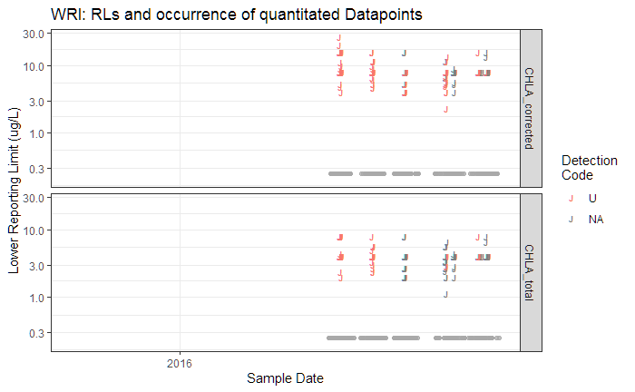

```r
CHL1016_08 %>% filter(PROJ_grp == "WRI") %>%
  filter(!is.na(Filt.Vol)) %>%
  filter(PARAM.X != "PHEO") %>%
  mutate(PARAM.X = recode(.$PARAM.X,
                          "CHLA.X" = "CHLA_total",
                          "CHLA.tot" = "CHLA_total",
                          "CHLA.aa" = "CHLA_corrected")) %>%
  distinct(SKey2, PARAM.X, Non_Detect, .keep_all = T) %>%
  ggplot(., na.rm=T) + theme_bw() +
  facet_grid(PARAM.X ~ .,  scales = "fixed") +
  geom_text(aes(x=x_SDate, y=LRL_c, col=Non_Detect),
            na.rm=T, size=2.5, fontface="bold", label="J") +
  geom_point(data=.data[[is.na(.data[["Non_Detect"]]),]], aes(y=0.25, x=.data[["x_SDate"]]),
             position = position_jitter(width=10, height=0), col="darkgray", size=1.5,
             alpha=0.75, na.rm=T) +
  scale_x_date(date_labels="%Y",date_breaks = "1 year",
               limits=c(as.Date("2015-10-01"), NA)) +
  scale_y_continuous(limits=c(0.2, NA), trans="log10") +
  labs(x="Sample Date", y="Lower Reporting Limit (ug/L)", col="Detection \nCode",
       title="WRI: RLs and occurrence of quantitated Datapoints")
```

- Due to small sample filtration volumes, some RLs are rather high

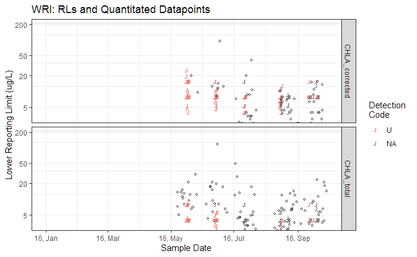

```r
CHL1016_08 %>% filter(PROJ_grp == "WRI") %>%
  filter(!is.na(Filt.Vol)) %>%
  filter(PARAM.X != "PHEO") %>%
  mutate(PARAM.X = recode(.$PARAM.X,
                          "CHLA.X" = "CHLA_total",
                          "CHLA.tot" = "CHLA_total",
                          "CHLA.aa" = "CHLA_corrected")) %>%
  distinct(SKey2, PARAM.X, .keep_all = T) %>%
  ggplot(., na.rm=T) + theme_bw() +
  geom_text(aes(x=x_SDate, y=LRL_c, col=Non_Detect),
            na.rm=T, size=2.5, fontface="bold", label="J") +
  facet_grid(PARAM.X ~ .,  scales = "fixed") +
  geom_point(aes(y=x_RVal.conc, x=x_SDate),
             position = position_jitter(width=10, height=0), size=1.2,
             alpha=0.75, na.rm=T, shape=1) +
  scale_x_date(date_labels="%y, %b",date_breaks = "2 month",
               limits=c(as.Date("2016-01-01"), NA)) +
  scale_y_continuous(limits=c(NA, NA), breaks=c(5, 20, 50, 200)) +
  coord_trans(y="log10", limy=c(2.5, 250)) +
  labs(x="Sample Date", y="Lower Reporting Limit (ug/L)", col="Detection \nCode",
       title="WRI: RLs and Quantitated Datapoints")
```

**Considerable amount of overlap of quantitated results and RLs**

- Proportion of Records w/ Non-Detect flags
  - *Ignoring records where filtration volume is unavailable*

```r
CHL1016_08 %>% filter(PROJ_grp == "WRI") %>%
  filter(!is.na(Filt.Vol)) %>%
  filter(PARAM.X != "PHEO") %>%
  mutate(PARAM.X = recode(.$PARAM.X,
                          "CHLA.X" = "CHLA_total",
                          "CHLA.tot" = "CHLA_total",
                          "CHLA.aa" = "CHLA_corrected")) %>%
  group_by(lubridate::year(x_SDate), PARAM.X) %>%
  summarize(p_ND = sprintf("%.f%%",
                           (sum(!is.na(Non_Detect), na.rm=T) / n())*100)) %>%
  as.data.frame(.) %>%
  setNames(c("Year", "CHL_param", "p_NonDetects")) %>%
  bind_rows(.,
            CHL1016_08 %>% filter(PROJ_grp == "WRI") %>%
              filter(!is.na(Filt.Vol)) %>%
              filter(PARAM.X != "PHEO") %>%
              group_by(lubridate::year(x_SDate)) %>%
              summarize(obs = n()) %>% data.frame(., CHL_param="Obs") %>%
              setNames(c("Year", "p_NonDetects", "CHL_param")) %>%
              mutate(p_NonDetects=as.character(p_NonDetects))
            ) %>%
  spread(Year, p_NonDetects) %>%
  htmlTable::htmlTable(., css.cell = rbind(rep("padding-left: 0.8em; padding-right: 0.8em;font-size: 0.75em;", times=ncol(.)+1), matrix("padding-left: 0.8em; padding-right: 0.8em; font-size: 0.75em;", ncol=ncol(.)+1, nrow=nrow(.))), align="r|l|cc|", caption="WRI: Proportion of records (SK2) where result is Non-Detect", total=T)
```

| WRI: Proportion of records (SK2) where result is Non-Detect | WRI: Proportion of records (SK2) where result is Non-Detect CHL_param | WRI: Proportion of records (SK2) where result is Non-Detect 2016 |
| --- | --- | --- |
| 1 | CHLA_corrected | 70% |
| 2 | CHLA_total | 42% |
| 3 | Obs | 478 |

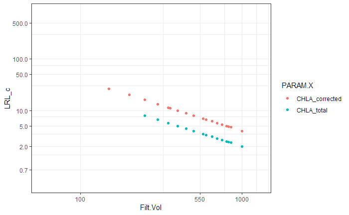

```r
CHL1016_08 %>% filter(PROJ_grp == "WRI") %>%
  filter(!is.na(Filt.Vol)) %>%
  filter(PARAM.X != "PHEO") %>%
  mutate(PARAM.X = recode(.$PARAM.X,
                          "CHLA.X" = "CHLA_total",
                          "CHLA.tot" = "CHLA_total",
                          "CHLA.aa" = "CHLA_corrected")) %>%
  ggplot(.) + theme_bw() +
  geom_point(aes(x=Filt.Vol, y=LRL_c, col=PARAM.X), na.rm=T) +
  # geom_point(aes(x=Filt.Vol, y=x_RVal.conc, col=PARAM.X), na.rm=T,
  #            position=position_jitter(width=10, height=0), shape=5, alpha=0.7) +
  coord_trans(x="log10", y="log10", limy=c(0.25, 1200), limx=c(50, 1500)) +
  scale_x_continuous(breaks=c(25, 100, 550, 1000, 2500)) +
  scale_y_continuous(breaks=c(0.7, 2, 5, 10, 50, 100, 500))
```

- Strong negative inverse (log-log) dependebnce of RL on filtration volume

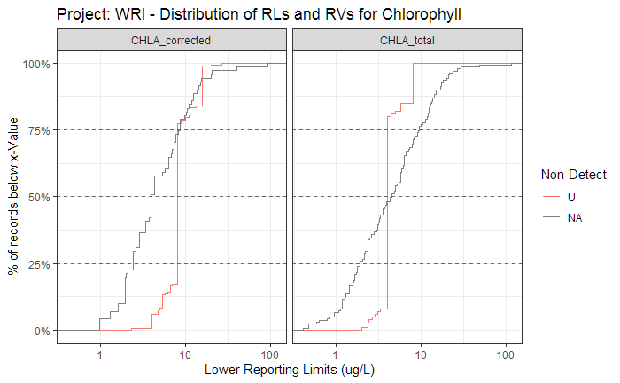

```r
CHL1016_08 %>% filter(PROJ_grp == "WRI") %>%
  filter(!is.na(Filt.Vol)) %>%
  filter(PARAM.X != "PHEO") %>%
  mutate(PARAM.X = recode(.$PARAM.X,
                          "CHLA.X" = "CHLA_total",
                          "CHLA.tot" = "CHLA_total",
                          "CHLA.aa" = "CHLA_corrected")) %>%
  mutate(Result_val = case_when(
    is.na(Non_Detect) &
      !is.na(x_RVal.conc) ~ x_RVal.conc,
    !is.na(Non_Detect) & Non_Detect == "U" &
      !is.na(LRL_c) ~ LRL_c,
    TRUE ~ as.numeric(NA))) %>%
  ggplot(.) + theme_bw() + facet_grid(. ~ PARAM.X, scales="fixed") +
  stat_ecdf(aes(x=Result_val, col=Non_Detect), na.rm=T, lty=1) +
  labs(x="Lower Reporting Limits (ug/L)", y="% of records below x-Value",
       col="Non-Detect") +
  scale_x_continuous(trans="log10") +
  scale_y_continuous(labels=scales::percent) +
  geom_hline(yintercept = c(0.25,0.5,0.75), lty=2, color="gray40") +
  ggtitle("Project: WRI - Distribution of RLs and RVs for Chlorophyll")
```

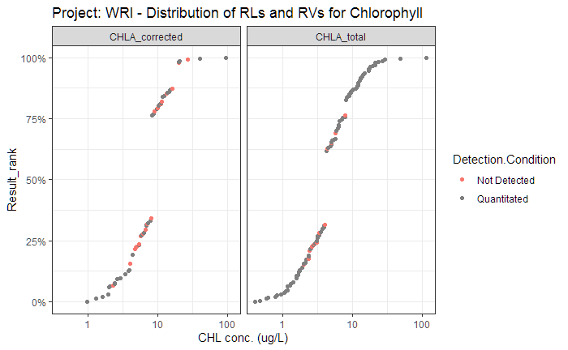

```r
CHL1016_08 %>% filter(PROJ_grp == "WRI") %>%
  filter(!is.na(Filt.Vol)) %>%
  filter(PARAM.X != "PHEO") %>%
  mutate(PARAM.X = recode(.$PARAM.X,
                          "CHLA.X" = "CHLA_total",
                          "CHLA.tot" = "CHLA_total",
                          "CHLA.aa" = "CHLA_corrected")) %>%
  mutate(Result_val = case_when(
    is.na(Non_Detect) &
      !is.na(x_RVal.conc) ~ x_RVal.conc,
    !is.na(Non_Detect) & Non_Detect == "U" &
      !is.na(LRL_c) ~ LRL_c,
    TRUE ~ as.numeric(NA))) %>%
  arrange(PARAM.X, Result_val) %>% group_by(PARAM.X) %>%
  mutate(RValue_rank = percent_rank(Result_val)) %>%
  ggplot(.) + theme_bw() + facet_grid(. ~ PARAM.X, scales="fixed") +
  geom_point(aes(x=Result_val, y=RValue_rank, col=Non_Detect), na.rm=T) +
  # EnvStats::stat_n_text() +
  labs(x="CHL conc. (ug/L)", y="Result_rank") +
  scale_x_continuous(trans="log10") +
  scale_y_continuous(labels = scales::percent) +
  ggtitle("Project: WRI - Distribution of RLs and RVs for Chlorophyll") +
  scale_color_discrete(name="Detection.Condition", labels=c("Not Detected", "Quantitated"))
```

### Bottom Line: REVW-Non-Detects (-blanks)

> Project `WRI` is sufficiently complete, no additional sample volumes are available or required. However, up to 70% of CHLA_corrected records are as Non-Detects and results should be re-examined

- ? Projects w/ `import_status` is “To_import”

```r
CHL1016_08 %>% {addmargins(table(.$PROJ_grp, .$import_status, useNA="ifany",
                                 deparse.level = 2))}
```

```
             .$import_status
.$PROJ_grp    To_import utlk_01  <NA>   Sum
  BOR               279       0     0   279
  BRI              2195       0     0  2195
  CUWJ              368       0     0   368
  FarmB               0       0     9     9
  FRNG                0       0   306   306
  GSLWET              0       0   333   333
  HAB                 0       0   117   117
  IW                  0       0   123   123
  JRULI             976      32     0  1008
  LAKES            1357     156     0  1513
  NPS                 3       0     0     3
  REFWET              0       0    99    99
  SBCI              186       0     0   186
  TMDLLAKES         636     138     0   774
  UBI                 4       0     0     4
  UCASE            2094       0     0  2094
  unknown             0       0   106   106
  USFS               47       0     0    47
  UtahLK             24      18     0    42
  WINTERLAKES        28       0     0    28
  WLA               301      25     0   326
  WRI               720       0     0   720
  WSpur               0       0  2195  2195
  WWTP                0       3  1064  1067
  Sum              9218     372  4352 13942
```

```r
CHL1016_08 %>% {addmargins(table(.$PROJ_grp, .$PARAM_status, useNA="ifany",
                                 deparse.level = 2))}
```

```
             .$PARAM_status
.$PROJ_grp    review_PERI  <NA>   Sum
  BOR                   0   279   279
  BRI                   0  2195  2195
  CUWJ                  0   368   368
  FarmB                 0     9     9
  FRNG                  0   306   306
  GSLWET                0   333   333
  HAB                   0   117   117
  IW                    0   123   123
  JRULI                 0  1008  1008
  LAKES                 0  1513  1513
  NPS                   0     3     3
  REFWET                0    99    99
  SBCI                  0   186   186
  TMDLLAKES             0   774   774
  UBI                   2     2     4
  UCASE               391  1703  2094
  unknown               6   100   106
  USFS                  0    47    47
  UtahLK                0    42    42
  WINTERLAKES           0    28    28
  WLA                   0   326   326
  WRI                   0   720   720
  WSpur               279  1916  2195
  WWTP                 23  1044  1067
  Sum                 701 13241 13942
```

- `PERI` parameters still need to be reviewed…

```r
CHL1016_08 %>% {addmargins(table(.$PROJ_grp, .$RECORD_STATUS, useNA="ifany",
                                 deparse.level = 2))} %>%
  as.data.frame.table(.) %>% setNames(c("PROJ_grp", "RECORD_STATUS", "Freq")) %>%
  filter(Freq > 0) %>%
  spread(RECORD_STATUS, Freq) %>%
  setNames(c("PROJ_grp", "REJ:Matrix", "REJ:NoVOL", "REVW_lrl", "REVW_mdl",
             "REVW_mdl+VOL","REVW_VOL",
             "Sum", "NA")) %>%
  select(-Sum, everything()) %>%
  htmlTable::htmlTable(., css.cell = rbind(rep("padding-left: 0.8em; padding-right: 0.8em;font-size: 0.75em;", times=ncol(.)+1), matrix("padding-left: 0.8em; padding-right: 0.8em; font-size: 0.75em;", ncol=ncol(.)+1, nrow=nrow(.))), align="rl|cc|cccc|c|r", total=T)
```

|  | PROJ_grp | REJ:Matrix | REJ:NoVOL | REVW_lrl | REVW_mdl | REVW_mdl+VOL | REVW_VOL | NA | Sum |
| --- | --- | --- | --- | --- | --- | --- | --- | --- | --- |
| 1 | BOR |  | 3 |  |  |  |  | 276 | 279 |
| 2 | BRI |  | 18 |  |  |  |  | 2177 | 2195 |
| 3 | CUWJ |  |  |  |  |  | 280 | 88 | 368 |
| 4 | FarmB |  |  |  |  |  | 9 |  | 9 |
| 5 | FRNG |  |  |  |  |  | 216 | 90 | 306 |
| 6 | GSLWET |  |  |  |  |  | 291 | 42 | 333 |
| 7 | HAB |  |  |  |  |  | 33 | 84 | 117 |
| 8 | IW |  |  |  |  |  |  | 123 | 123 |
| 9 | JRULI |  |  |  |  |  | 321 | 687 | 1008 |
| 10 | LAKES |  |  | 24 | 147 |  | 102 | 1240 | 1513 |
| 11 | NPS |  |  |  |  |  | 3 |  | 3 |
| 12 | REFWET |  |  |  |  |  |  | 99 | 99 |
| 13 | SBCI |  |  |  |  |  | 3 | 183 | 186 |
| 14 | TMDLLAKES |  |  |  |  |  | 160 | 614 | 774 |
| 15 | UBI |  |  |  |  |  | 4 |  | 4 |
| 16 | UCASE | 6 |  |  | 83 |  |  | 2005 | 2094 |
| 17 | unknown |  |  |  |  | 4 | 54 | 48 | 106 |
| 18 | USFS |  |  |  |  |  |  | 47 | 47 |
| 19 | UtahLK |  |  |  |  |  | 1 | 41 | 42 |
| 20 | WINTERLAKES |  |  |  |  |  | 9 | 19 | 28 |
| 21 | WLA |  |  |  |  |  | 35 | 291 | 326 |
| 22 | WRI |  |  |  |  |  | 3 | 717 | 720 |
| 23 | WSpur |  |  |  |  |  | 422 | 1773 | 2195 |
| 24 | WWTP |  |  |  |  |  | 928 | 139 | 1067 |
| 25 | Sum | 6 | 21 | 24 | 230 | 4 | 2874 | 10783 | 13942 |

- Some records still have problematic values in LRL/MDL (== 0)
  - If LRL or MDL == 0 : ==> change to `NA`
  - If LRL/MDL is `NA`, no LRL_c / MDL_c calculation allowed
  - If LRL_c / MDL_c are `NA`, RL_Units == `NA`

```r
CHL1016_08 %<>% mutate(
  MDL = case_when(
    MDL == 0 ~ as.numeric(NA),
    !is.na(MDL) ~ MDL,
    TRUE ~ as.numeric(NA)),
  MDL_c = case_when(
    MDL == 0 ~ as.numeric(NA),
    is.na(MDL) ~ as.numeric(NA),
    !is.na(MDL) & !is.na(Filt.Vol) & MDL != 0 ~ ((MDL*1000) / (Filt.Vol/1000)),
    !is.na(MDL_c) ~ MDL_c,
    TRUE ~ as.numeric(NA)),
  LRL = case_when(
    LRL == 0 ~ as.numeric(NA),
    !is.na(LRL) ~ LRL,
    TRUE ~ as.numeric(NA)),
  LRL_c = case_when(
    LRL == 0 ~ as.numeric(NA),
    !is.na(LRL) & !is.na(Filt.Vol) & LRL != 0 ~ ((LRL*1000) / (Filt.Vol/1000)),
    !is.na(LRL_c) ~ LRL_c,
    TRUE ~ as.numeric(NA))) %>%
  mutate(
  RL_Units = case_when(
    MethodID2 == "10200" & PARAM.X != "PERI" &
      (!is.na(LRL_c) | !is.na(MDL_c)) ~ "ug/L",
    !is.na(RL_Units) ~ RL_Units,
    TRUE ~ as.character(NA)),
  RECORD_STATUS = case_when(
    is.na(LRL_c) &
      grepl("_lrl", .$RECORD_STATUS, ignore.case = T) &
      !grepl("_VOL", .$RECORD_STATUS, ignore.case = T) ~ as.character(NA),
    is.na(LRL_c) &
      grepl("_lrl", .$RECORD_STATUS, ignore.case = T) &
      !grepl("_VOL", .$RECORD_STATUS, ignore.case = T) ~ "REVIEW_VOL",
    is.na(MDL_c) &
      grepl("_mdl", .$RECORD_STATUS, ignore.case = T) &
      !grepl("_VOL", .$RECORD_STATUS, ignore.case = T) ~ as.character(NA),
    is.na(MDL_c) &
      grepl("_mdl", .$RECORD_STATUS, ignore.case = T) &
      grepl("_VOL", .$RECORD_STATUS, ignore.case = T) ~ "REVIEW_VOL",
    !is.na(RECORD_STATUS) ~ RECORD_STATUS,
    TRUE ~ as.character(NA))
)
```

- Update records w/ “REVIEW_VOL” to “REJECT_noVOL”, since these have been reviewed now 4 times (at least)
  - **Except !!** for records w/ Sample.Date < Jan 2013 (*roughly*)

```r
CHL1016_08 %<>% mutate(
  RECORD_STATUS = case_when(
    RECORD_STATUS == "REVIEW_VOL" & x_SDate > as.Date("2013-01-01") &
      (x_Units.conc != "ug/L" | x_Units != "ug/L" | RL_Units != "ug/L") ~ "REJECT_noVOL",
    RECORD_STATUS == "REVIEW_VOL" & x_SDate < as.Date("2013-01-01") ~ as.character(NA),
    !is.na(RECORD_STATUS) ~ RECORD_STATUS,
    TRUE ~ as.character(NA)))
```

- For records *“To import”*, what are `PARAM_status` and `RECORD_STATUS` ?

```r
CHL1016_08 %>% filter(!is.na(import_status)) %>%
  {addmargins(
    table(.$PROJ_grp,
          paste(.$PARAM_status, .$RECORD_STATUS, sep="_"),
          useNA="ifany", deparse.level = 2,
          dnn=c("Project", "PARAM_REVIEW.status")))}
```

```
             PARAM_REVIEW.status
Project       NA_NA NA_REJECT_matrix NA_REJECT_noVOL review_PERI_NA  Sum
  BOR           276                0               3              0  279
  BRI          2177                0              18              0 2195
  CUWJ          121                0             247              0  368
  JRULI        1008                0               0              0 1008
  LAKES        1459                0              54              0 1513
  NPS             0                0               3              0    3
  SBCI          183                0               3              0  186
  TMDLLAKES     726                0              48              0  774
  UBI             2                0               0              2    4
  UCASE        1697                6               0            391 2094
  USFS           47                0               0              0   47
  UtahLK         42                0               0              0   42
  WINTERLAKES    28                0               0              0   28
  WLA           302                0              24              0  326
  WRI           717                0               3              0  720
  WWTP            3                0               0              0    3
  Sum          8788                6             403            393 9590
```

### 9.1 Annotate Records that need Result.Value *review*

1. `import_status` = “To_import”
2. `PARAM.X` != “PERI” (or MEthodID != “10300”)
3. Also be careful of `MATRIX.X` = “BENTH”, *since these records need further review, anyway*

```r
CHL1016_08 %<>% mutate(
  result_REVIEW = case_when(
    is.na(RECORD_STATUS) & is.na(PARAM_status) &
      !is.na(import_status) &
      x_Units == "mg" &
      !PARAM.X %in% c("PERI", "PHEO", "CHLB") &
      MethodID2 == "10200" &
      MATRIX.X == "WC"  &
      (is.na(QC_type) | QC_type != "Blank") &
      !is.na(Filt.Vol) &
      !is.na(Non_Detect) &
      (between(x_SDate, as.Date("2012-10-01"), as.Date("2016-10-01"))) &
      LRL_c > 5 ~ "REVW:absorbnc",
    MATRIX.X == "BENTH" ~ "REVW:benthic",
    TRUE ~ as.character(NA))) %>%
  select(RECORD_STATUS:PARAM.X, result_REVIEW, everything())
# x_SDate >= as.Date("2012-10-01") &
         #x_SDate <= as.Date("2016-10-01")
```

- Plus a couple manual corrections…

```r
CHL1016_08 %<>% mutate(
  LRL_c = case_when(
    PROJ_grp == "BOR" & LRL == 0.7 & x_Units == "mg" ~ 0.7,
    !is.na(LRL_c) ~ LRL_c,
    TRUE ~ as.numeric(NA)),
  x_Units = case_when(
    PROJ_grp == "BOR" & LRL == 0.7 & x_Units == "mg" ~ "ug/L",
    !is.na(x_Units) ~ x_Units,
    TRUE ~ as.character(NA))
)
```

- Summary status

```r
CHL1016_08 %>% {addmargins(table(.$PROJ_grp, .$result_REVIEW,
                                 useNA="ifany", deparse.level = 2))}
```

```
             .$result_REVIEW
.$PROJ_grp    REVW:absorbnc REVW:benthic  <NA>   Sum
  BOR                     0            0   279   279
  BRI                   468            0  1727  2195
  CUWJ                    0            0   368   368
  FarmB                   0            0     9     9
  FRNG                    0            0   306   306
  GSLWET                  0            0   333   333
  HAB                     0            0   117   117
  IW                      0            0   123   123
  JRULI                   0            0  1008  1008
  LAKES                 447            0  1066  1513
  NPS                     0            0     3     3
  REFWET                  0            0    99    99
  SBCI                   52            0   134   186
  TMDLLAKES             148            0   626   774
  UBI                     0            4     0     4
  UCASE                 186         1230   678  2094
  unknown                 0            9    97   106
  USFS                    0            0    47    47
  UtahLK                  1            0    41    42
  WINTERLAKES             0            0    28    28
  WLA                    68            0   258   326
  WRI                   142            0   578   720
  WSpur                   0          463  1732  2195
  WWTP                    0          554   513  1067
  Sum                  1512         2260 10170 13942
```

```r
CHL1016_08 %>% {addmargins(table(.$PROJ_grp, .$Non_Detect,
                                 useNA="ifany", deparse.level = 2))}
```

```
             .$Non_Detect
.$PROJ_grp        U  <NA>   Sum
  BOR           151   128   279
  BRI          1926   269  2195
  CUWJ          116   252   368
  FarmB           0     9     9
  FRNG          185   121   306
  GSLWET         32   301   333
  HAB            42    75   117
  IW             50    73   123
  JRULI         254   754  1008
  LAKES        1025   488  1513
  NPS             0     3     3
  REFWET         91     8    99
  SBCI          160    26   186
  TMDLLAKES     396   378   774
  UBI             0     4     4
  UCASE         891  1203  2094
  unknown        45    61   106
  USFS            6    41    47
  UtahLK          8    34    42
  WINTERLAKES     1    27    28
  WLA           220   106   326
  WRI           476   244   720
  WSpur         843  1352  2195
  WWTP          106   961  1067
  Sum          7024  6918 13942
```

#### FIG: Absorbance review records by project

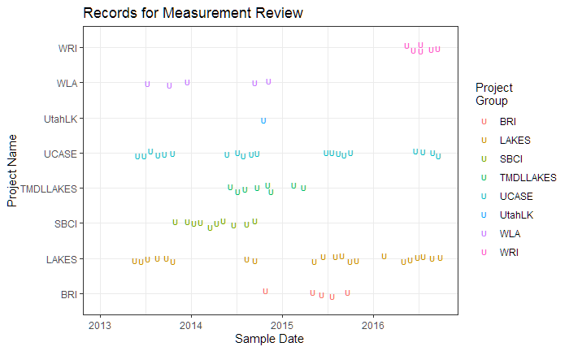

```r
CHL1016_08 %>% filter(result_REVIEW == "REVW:absorbnc") %>%
  filter(!is.na(Filt.Vol) & PARAM.X != "PHEO" & MATRIX.X != "BENTH") %>%
  mutate(PARAM.X = recode(.$PARAM.X,
                          "CHLA.X" = "CHLA_total",
                          "CHLA.tot" = "CHLA_total",
                          "CHLA.aa" = "CHLA_corrected")) %>%
  distinct(SKey2, PARAM.X, Non_Detect, .keep_all = T) %>%
  ggplot(., na.rm=T) + theme_bw() +
  geom_text(aes(x=factor(PROJ_grp), y=x_SDate, col=PROJ_grp),
            na.rm=T, size=2.5, fontface="bold", label="U",
            position=position_jitter(width=0.1, height=0.1), check_overlap = T) +
  scale_y_date(date_labels="%Y",date_breaks = "1 year",
               limits=c(as.Date("2013-01-01"), NA)) +
  coord_flip() +
  labs(x="Project Name", y="Sample Date", col="Project \nGroup",
       title="Records for Measurement Review")
```

```r
NA
NA
```

```r
CHL1016_08 %>% filter(is.na(result_REVIEW) | result_REVIEW != "REVW:benthic") %>%
  {addmargins(table(.$result_REVIEW, .$Non_Detect,
                                 useNA="ifany", deparse.level = 2))}
```

```
               .$Non_Detect
.$result_REVIEW     U  <NA>   Sum
  REVW:absorbnc  1512     0  1512
  <NA>           5282  4888 10170
  Sum            6794  4888 11682
```

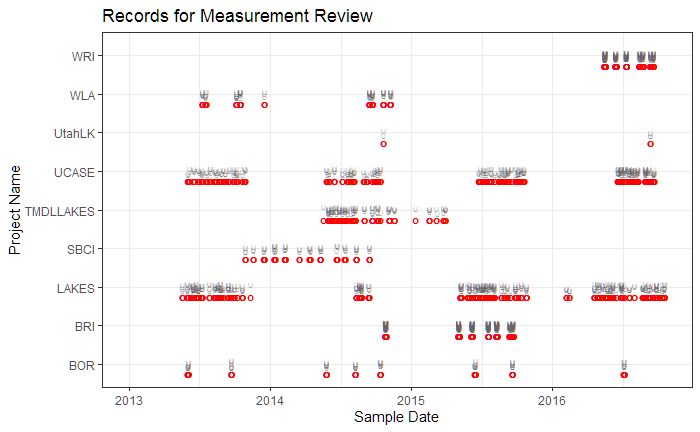

```r
CHL1016_08 %>%
  filter(is.na(RECORD_STATUS) &
           is.na(PARAM_status) &
           !is.na(import_status) &
           !is.na(Filt.Vol) &
           !PARAM.X %in% c("PERI", "PHEO", "CHLB") &
           MATRIX.X == "WC" &
           MethodID2 == "10200") %>%
  mutate(PARAM.X = recode(.$PARAM.X,
                          "CHLA.X" = "CHLA_total",
                          "CHLA.tot" = "CHLA_total",
                          "CHLA.aa" = "CHLA_corrected"),
         result_REVIEW = recode(.$result_REVIEW,
                                .default = "Review_Abs",
                                .missing="No Review Needed")) %>%
  filter(PARAM.X == "CHLA_corrected") %>%
  distinct(SKey2, PARAM.X, Non_Detect, .keep_all = T) %>%
  ggplot(., na.rm=T) + theme_bw() +
  geom_point(data=.data[[.data[["result_REVIEW"]] == "No Review Needed"]],
             aes(x=factor(PROJ_grp), y=x_SDate), shape=85, col="gray40", size=1.5,
             na.rm=T, position=position_jitter(width=0.09), alpha=0.5) +
  geom_text(data=.data[[.data[["result_REVIEW"]] == "review_Abs"]],
            aes(x=factor(PROJ_grp), y=x_SDate), label="o", col="red", size=3,
            fontface="bold", na.rm=T,
            vjust=1.5) +
  scale_y_date(date_labels="%Y",date_breaks = "1 year",
               limits=c(as.Date("2013-01-01"), NA)) +
  coord_flip() +
  labs(x="Project Name", y="Sample Date", shape="Project \nGroup", col="Project \nGroup",
       title="Records for Measurement Review")
```

> **The grey “U”-shapes represent datapoints where the result was coded as “Non-Detect”, while the red “o”-shapes identify recores where Absorbance data should be reviewed**

```r
CHL1016_08 %>%
  filter(is.na(RECORD_STATUS)) %>%
  group_by(PROJ_grp) %>%
  summarize(Obs = n(),
            k_Obs = n_distinct(SKey2, na.rm=T),
            k_import = n_distinct(SKey2[!is.na(import_status)], na.rm=T),
            k_NonDet = n_distinct(SKey2[!is.na(import_status) & Non_Detect=="U"], na.rm=T),
            k_RevAbs = n_distinct(SKey2[!is.na(import_status) & Non_Detect=="U" &
                                          result_REVIEW == "REVW:absorbnc"], na.rm=T)) %>%
  mutate(
    p_import = case_when(
      k_import > 0 ~ sprintf("%.f%%", (k_import/k_Obs)*100),
      TRUE ~ as.character(NA)),
    p_NonDet = case_when(
      k_NonDet > 0 ~ sprintf("%.f%%", (k_NonDet/k_import)*100),
      TRUE ~ as.character(NA)),
    p_RevAbs = case_when(
      k_RevAbs > 0 ~ sprintf("%.f%%", (k_RevAbs/k_NonDet)*100),
      TRUE ~ as.character(NA))) %>%
  select(PROJ_grp, Obs, k_Obs, k_import, p_import, k_NonDet, p_NonDet,
         k_RevAbs, p_RevAbs, everything()) %>%
  htmlTable(., css.cell = rbind(rep("padding-left: 0.8em; padding-right: 0.8em;font-size: 0.75em;", times=ncol(.)+1), matrix("padding-left: 0.75em; padding-right: 0.75em; font-size: 0.75em;", ncol=ncol(.)+1, nrow=nrow(.))), total=F, caption="Record Completeness Counts by Project-Group", align="rl|cc|cc|cc|cc")
```

| Record Completeness Counts by Project-Group | Record Completeness Counts by Project-Group PROJ_grp | Record Completeness Counts by Project-Group Obs | Record Completeness Counts by Project-Group k_Obs | Record Completeness Counts by Project-Group k_import | Record Completeness Counts by Project-Group p_import | Record Completeness Counts by Project-Group k_NonDet | Record Completeness Counts by Project-Group p_NonDet | Record Completeness Counts by Project-Group k_RevAbs | Record Completeness Counts by Project-Group p_RevAbs |
| --- | --- | --- | --- | --- | --- | --- | --- | --- | --- |
| 1 | BOR | 276 | 118 | 118 | 100% | 77 | 65% | 0 |  |
| 2 | BRI | 2177 | 441 | 441 | 100% | 440 | 100% | 359 | 82% |
| 3 | CUWJ | 121 | 92 | 92 | 100% | 3 | 3% | 0 |  |
| 4 | FRNG | 90 | 30 | 0 |  | 0 |  | 0 |  |
| 5 | GSLWET | 333 | 333 | 0 |  | 0 |  | 0 |  |
| 6 | HAB | 84 | 28 | 0 |  | 0 |  | 0 |  |
| 7 | IW | 123 | 122 | 0 |  | 0 |  | 0 |  |
| 8 | JRULI | 1008 | 1002 | 1002 | 100% | 250 | 25% | 0 |  |
| 9 | LAKES | 1459 | 592 | 592 | 100% | 458 | 77% | 295 | 64% |
| 10 | REFWET | 99 | 33 | 0 |  | 0 |  | 0 |  |
| 11 | SBCI | 183 | 61 | 61 | 100% | 61 | 100% | 41 | 67% |
| 12 | TMDLLAKES | 726 | 391 | 391 | 100% | 177 | 45% | 94 | 53% |
| 13 | UBI | 4 | 2 | 2 | 100% | 0 |  | 0 |  |
| 14 | UCASE | 2088 | 735 | 735 | 100% | 441 | 60% | 165 | 37% |
| 15 | unknown | 64 | 44 | 0 |  | 0 |  | 0 |  |
| 16 | USFS | 47 | 47 | 47 | 100% | 6 | 13% | 0 |  |
| 17 | UtahLK | 42 | 23 | 23 | 100% | 7 | 30% | 1 | 14% |
| 18 | WINTERLAKES | 28 | 26 | 26 | 100% | 1 | 4% | 0 |  |
| 19 | WLA | 302 | 148 | 148 | 100% | 90 | 61% | 62 | 69% |
| 20 | WRI | 717 | 239 | 239 | 100% | 217 | 91% | 124 | 57% |
| 21 | WSpur | 2156 | 1097 | 0 |  | 0 |  | 0 |  |
| 22 | WWTP | 1067 | 1028 | 2 | 0% | 0 |  | 0 |  |

## END

```r
# CHL1016_07 %>% select(contains("type", ignore.case = T)) %>% names(.)
# CHL1016_05 %>% {addmargins(table(.$PROJ_grp, .$RECORD_STATUS,
#                                  useNA="ifany", deparse.level = 2))}
# CHL1016_07 %>% distinct(RECORD_STATUS) %$% .$RECORD_STATUS
```

```r
unique(CHL1016_08$RECORD_STATUS)
```

```
[1] NA              "REJECT_noVOL"  "REJECT_matrix"
```

```r
lastwork.date <- format(Sys.Date(), "%y%m%d")
```

**Start work date ::** 190829  
**Last work date ::** 190916  
**Current review date ::** 190916

eof